# Project 1: SAT & ACT Analysis

## The Bottom Line

It's the age-old problem: how do we get the most utility out of finite resources. In this case, how do we profit-maximize with our warchest? Do we engage in a nationwide push or are there states where targeted campaigns would yield the greatest ROI?

## Executive Summary

### Contents:

- 2017 Data Import and Cleaning
- 2018 Data Import and Cleaning
- Exploratory Data Analysis
- Data Visualization
- Descriptive and Inferential Statistics
- Outside Research
- Conclusions and Recommendations

```python
import numpy as np
import pandas as pd
import matplotlib.pyplot as plt
import seaborn as sns
import scipy.stats as stats
import os
import PyPDF2
import re
from bs4 import BeautifulSoup
import requests
import lxml

print(os.getcwd())


%matplotlib inline
```

```
C:\Users\Jay\Documents\GitHub\classes\projects1234\project_1\code
```

## 2017 Data Import and Cleaning

#### 1. Read In SAT & ACT Data

Read in the `sat_2017.csv` and `act_2017.csv` files and assign them to appropriately named pandas dataframes.

```python
sat_2017 = pd.read_csv('../data/sat_2017.csv')
act_2017 = pd.read_csv('../data/act_2017.csv')
```

#### 2. Display Data

Show the first 10 rows of each dataframe to your jupyter notebook

```python
sat_2017.head(10)
```

|  | State | Participation | Evidence-Based Reading and Writing | Math | Total |
| --- | --- | --- | --- | --- | --- |
| 0 | Alabama | 5% | 593 | 572 | 1165 |
| 1 | Alaska | 38% | 547 | 533 | 1080 |
| 2 | Arizona | 30% | 563 | 553 | 1116 |
| 3 | Arkansas | 3% | 614 | 594 | 1208 |
| 4 | California | 53% | 531 | 524 | 1055 |
| 5 | Colorado | 11% | 606 | 595 | 1201 |
| 6 | Connecticut | 100% | 530 | 512 | 1041 |
| 7 | Delaware | 100% | 503 | 492 | 996 |
| 8 | District of Columbia | 100% | 482 | 468 | 950 |
| 9 | Florida | 83% | 520 | 497 | 1017 |

```python
act_2017.head(10)
```

|  | State | Participation | English | Math | Reading | Science | Composite |
| --- | --- | --- | --- | --- | --- | --- | --- |
| 0 | National | 60% | 20.3 | 20.7 | 21.4 | 21.0 | 21.0 |
| 1 | Alabama | 100% | 18.9 | 18.4 | 19.7 | 19.4 | 19.2 |
| 2 | Alaska | 65% | 18.7 | 19.8 | 20.4 | 19.9 | 19.8 |
| 3 | Arizona | 62% | 18.6 | 19.8 | 20.1 | 19.8 | 19.7 |
| 4 | Arkansas | 100% | 18.9 | 19.0 | 19.7 | 19.5 | 19.4 |
| 5 | California | 31% | 22.5 | 22.7 | 23.1 | 22.2 | 22.8 |
| 6 | Colorado | 100% | 20.1 | 20.3 | 21.2 | 20.9 | 20.8 |
| 7 | Connecticut | 31% | 25.5 | 24.6 | 25.6 | 24.6 | 25.2 |
| 8 | Delaware | 18% | 24.1 | 23.4 | 24.8 | 23.6 | 24.1 |
| 9 | District of Columbia | 32% | 24.4 | 23.5 | 24.9 | 23.5 | 24.2 |

```python
sat_2017.dtypes
```

```
State                                 object
Participation                         object
Evidence-Based Reading and Writing     int64
Math                                   int64
Total                                  int64
dtype: object
```

```python
sat_2017.info()
```

```
<class 'pandas.core.frame.DataFrame'>
RangeIndex: 51 entries, 0 to 50
Data columns (total 5 columns):
State                                 51 non-null object
Participation                         51 non-null object
Evidence-Based Reading and Writing    51 non-null int64
Math                                  51 non-null int64
Total                                 51 non-null int64
dtypes: int64(3), object(2)
memory usage: 2.1+ KB
```

```python
act_2017.dtypes
```

```
State             object
Participation     object
English          float64
Math             float64
Reading          float64
Science          float64
Composite         object
dtype: object
```

```python
act_2017.info()
```

```
<class 'pandas.core.frame.DataFrame'>
RangeIndex: 52 entries, 0 to 51
Data columns (total 7 columns):
State            52 non-null object
Participation    52 non-null object
English          52 non-null float64
Math             52 non-null float64
Reading          52 non-null float64
Science          52 non-null float64
Composite        52 non-null object
dtypes: float64(4), object(3)
memory usage: 2.9+ KB
```

#### 3. Verbally Describe Data

Take your time looking through the data and thoroughly describe the data in the markdown cell below.

Eyeballing (which is never accurate) the data seems to suggest an inverse relationship between ACT and SAT participation rates in states where there is 100% participation rate in either one of the tests. Intuitively, this makes sense as those are states with mandatory standardized testing, thus it stands to reason that there would be a lower participation rate in the other test.

Additionally, it appears that these states generally do better in the non-compulsory test as compared to the national average. Again, intuitively, this makes sense as students who choose to take the OTHER test come from a self-selective group that believe they can get better scores in the other test.

In both dataframes, the participation rate is read as a string instead of a float. In the ACT 2017 data, the composite score is read as a string too.

#### 4a. Does the data look complete?

No. While we do not observe any null values, it is odd that the Composite column of the ACT 2017 dataframe returns an object dtype instead of a float64 like the other subtests. It's likely that there's erroneous data in the Composite column.

#### 4b. Are there any obvious issues with the observations?

**What is the minimum *possible* value for each test/subtest? What is the maximum *possible* value?**

Consider comparing any questionable values to the sources of your data:

- [SAT](https://blog.collegevine.com/here-are-the-average-sat-scores-by-state/)
- [ACT](https://blog.prepscholar.com/act-scores-by-state-averages-highs-and-lows)

200 - 800 per section for SAT with 400 - 1600 for the total score.

1 - 36 per section for ACT with 1 - 36 for the composite score.

#### 4c. Fix any errors you identified

**The data is available** so there's no need to guess or calculate anything. If you didn't find any errors, continue to the next step.

The proper way to approach this is to actually do some EDA on this without the prior sections of eyeballing. That's not suitable going forward.

I will demonstrate that EDA to determine outliers should capture the error in Maryland's entry. I would like to note, however, that this doesn't do anything when it comes to picking out errors apropos of participation rate, although if my hypothesis holds true, then it could be useful in alerting one to possible errors in said states.

We begin by cleaning the data into a suitable format for EDA: participation rate to float for sat_2017; participation rate and composite to float of act_2017

```python
p = re.compile(r'\d{1,3}\.?\d*')
```

```python
sat_2017.Participation = sat_2017.Participation.map(lambda x: float(p.search(x).group())/100)
```

```python
sat_2017.describe()
```

|  | Participation | Evidence-Based Reading and Writing | Math | Total |
| --- | --- | --- | --- | --- |
| count | 51.000000 | 51.000000 | 51.000000 | 51.000000 |
| mean | 0.398039 | 569.117647 | 547.627451 | 1126.098039 |
| std | 0.352766 | 45.666901 | 84.909119 | 92.494812 |
| min | 0.020000 | 482.000000 | 52.000000 | 950.000000 |
| 25% | 0.040000 | 533.500000 | 522.000000 | 1055.500000 |
| 50% | 0.380000 | 559.000000 | 548.000000 | 1107.000000 |
| 75% | 0.660000 | 613.000000 | 599.000000 | 1212.000000 |
| max | 1.000000 | 644.000000 | 651.000000 | 1295.000000 |

Immediately, we can see something suspicious in the min score of Math.

```python
sat_2017
```

|  | State | Participation | Evidence-Based Reading and Writing | Math | Total |
| --- | --- | --- | --- | --- | --- |
| 0 | Alabama | 0.05 | 593 | 572 | 1165 |
| 1 | Alaska | 0.38 | 547 | 533 | 1080 |
| 2 | Arizona | 0.30 | 563 | 553 | 1116 |
| 3 | Arkansas | 0.03 | 614 | 594 | 1208 |
| 4 | California | 0.53 | 531 | 524 | 1055 |
| 5 | Colorado | 0.11 | 606 | 595 | 1201 |
| 6 | Connecticut | 1.00 | 530 | 512 | 1041 |
| 7 | Delaware | 1.00 | 503 | 492 | 996 |
| 8 | District of Columbia | 1.00 | 482 | 468 | 950 |
| 9 | Florida | 0.83 | 520 | 497 | 1017 |
| 10 | Georgia | 0.61 | 535 | 515 | 1050 |
| 11 | Hawaii | 0.55 | 544 | 541 | 1085 |
| 12 | Idaho | 0.93 | 513 | 493 | 1005 |
| 13 | Illinois | 0.09 | 559 | 556 | 1115 |
| 14 | Indiana | 0.63 | 542 | 532 | 1074 |
| 15 | Iowa | 0.02 | 641 | 635 | 1275 |
| 16 | Kansas | 0.04 | 632 | 628 | 1260 |
| 17 | Kentucky | 0.04 | 631 | 616 | 1247 |
| 18 | Louisiana | 0.04 | 611 | 586 | 1198 |
| 19 | Maine | 0.95 | 513 | 499 | 1012 |
| 20 | Maryland | 0.69 | 536 | 52 | 1060 |
| 21 | Massachusetts | 0.76 | 555 | 551 | 1107 |
| 22 | Michigan | 1.00 | 509 | 495 | 1005 |
| 23 | Minnesota | 0.03 | 644 | 651 | 1295 |
| 24 | Mississippi | 0.02 | 634 | 607 | 1242 |
| 25 | Missouri | 0.03 | 640 | 631 | 1271 |
| 26 | Montana | 0.10 | 605 | 591 | 1196 |
| 27 | Nebraska | 0.03 | 629 | 625 | 1253 |
| 28 | Nevada | 0.26 | 563 | 553 | 1116 |
| 29 | New Hampshire | 0.96 | 532 | 520 | 1052 |
| 30 | New Jersey | 0.70 | 530 | 526 | 1056 |
| 31 | New Mexico | 0.11 | 577 | 561 | 1138 |
| 32 | New York | 0.67 | 528 | 523 | 1052 |
| 33 | North Carolina | 0.49 | 546 | 535 | 1081 |
| 34 | North Dakota | 0.02 | 635 | 621 | 1256 |
| 35 | Ohio | 0.12 | 578 | 570 | 1149 |
| 36 | Oklahoma | 0.07 | 530 | 517 | 1047 |
| 37 | Oregon | 0.43 | 560 | 548 | 1108 |
| 38 | Pennsylvania | 0.65 | 540 | 531 | 1071 |
| 39 | Rhode Island | 0.71 | 539 | 524 | 1062 |
| 40 | South Carolina | 0.50 | 543 | 521 | 1064 |
| 41 | South Dakota | 0.03 | 612 | 603 | 1216 |
| 42 | Tennessee | 0.05 | 623 | 604 | 1228 |
| 43 | Texas | 0.62 | 513 | 507 | 1020 |
| 44 | Utah | 0.03 | 624 | 614 | 1238 |
| 45 | Vermont | 0.60 | 562 | 551 | 1114 |
| 46 | Virginia | 0.65 | 561 | 541 | 1102 |
| 47 | Washington | 0.64 | 541 | 534 | 1075 |
| 48 | West Virginia | 0.14 | 558 | 528 | 1086 |
| 49 | Wisconsin | 0.03 | 642 | 649 | 1291 |
| 50 | Wyoming | 0.03 | 626 | 604 | 1230 |

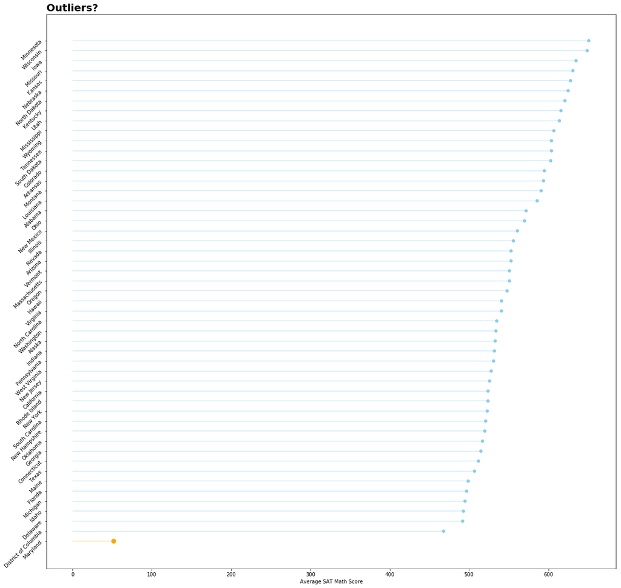

```python
# Reorder it following the values:
ordered_sat_2017 = sat_2017.sort_values(by='Math')
my_range=range(1,len(ordered_sat_2017.index)+1)

# Create a color if the group is "B"
my_color=np.where(ordered_sat_2017['State']=='Maryland', 'orange', 'skyblue')
my_size=np.where(ordered_sat_2017['State']=='Maryland', 70, 30)

# The vertical plot is made using the hline function
# I load the seaborn library only to benefit the nice looking feature
plt.figure(figsize=(20,20))
plt.hlines(y=my_range, xmin=0, xmax=ordered_sat_2017['Math'], color=my_color, alpha=0.4)
plt.scatter(ordered_sat_2017['Math'], my_range, color=my_color, s=my_size, alpha=1)

# Add title and axis names
plt.yticks(my_range, ordered_sat_2017['State'], rotation=45)
plt.title("Outliers?", loc='left', fontdict={'size':20,'fontweight':'bold'})
plt.xlabel('Average SAT Math Score')
```

Additionally, it follows that the total should be equal to the sum of ERW and Math

```python
ordered_sat_2017.rename(columns={'Evidence-Based Reading and Writing':'ERW'}, inplace=True)

def discrepancy(row):
    row['Discrepancy'] = row[['ERW','Math']].sum() - row['Total']
    return row

ordered_sat_2017.apply(discrepancy, axis=1)
```

|  | State | Participation | ERW | Math | Total | Discrepancy |
| --- | --- | --- | --- | --- | --- | --- |
| 20 | Maryland | 0.69 | 536 | 52 | 1060 | -472 |
| 8 | District of Columbia | 1.00 | 482 | 468 | 950 | 0 |
| 7 | Delaware | 1.00 | 503 | 492 | 996 | -1 |
| 12 | Idaho | 0.93 | 513 | 493 | 1005 | 1 |
| 22 | Michigan | 1.00 | 509 | 495 | 1005 | -1 |
| 9 | Florida | 0.83 | 520 | 497 | 1017 | 0 |
| 19 | Maine | 0.95 | 513 | 499 | 1012 | 0 |
| 43 | Texas | 0.62 | 513 | 507 | 1020 | 0 |
| 6 | Connecticut | 1.00 | 530 | 512 | 1041 | 1 |
| 10 | Georgia | 0.61 | 535 | 515 | 1050 | 0 |
| 36 | Oklahoma | 0.07 | 530 | 517 | 1047 | 0 |
| 29 | New Hampshire | 0.96 | 532 | 520 | 1052 | 0 |
| 40 | South Carolina | 0.50 | 543 | 521 | 1064 | 0 |
| 32 | New York | 0.67 | 528 | 523 | 1052 | -1 |
| 39 | Rhode Island | 0.71 | 539 | 524 | 1062 | 1 |
| 4 | California | 0.53 | 531 | 524 | 1055 | 0 |
| 30 | New Jersey | 0.70 | 530 | 526 | 1056 | 0 |
| 48 | West Virginia | 0.14 | 558 | 528 | 1086 | 0 |
| 38 | Pennsylvania | 0.65 | 540 | 531 | 1071 | 0 |
| 14 | Indiana | 0.63 | 542 | 532 | 1074 | 0 |
| 1 | Alaska | 0.38 | 547 | 533 | 1080 | 0 |
| 47 | Washington | 0.64 | 541 | 534 | 1075 | 0 |
| 33 | North Carolina | 0.49 | 546 | 535 | 1081 | 0 |
| 46 | Virginia | 0.65 | 561 | 541 | 1102 | 0 |
| 11 | Hawaii | 0.55 | 544 | 541 | 1085 | 0 |
| 37 | Oregon | 0.43 | 560 | 548 | 1108 | 0 |
| 21 | Massachusetts | 0.76 | 555 | 551 | 1107 | -1 |
| 45 | Vermont | 0.60 | 562 | 551 | 1114 | -1 |
| 2 | Arizona | 0.30 | 563 | 553 | 1116 | 0 |
| 28 | Nevada | 0.26 | 563 | 553 | 1116 | 0 |
| 13 | Illinois | 0.09 | 559 | 556 | 1115 | 0 |
| 31 | New Mexico | 0.11 | 577 | 561 | 1138 | 0 |
| 35 | Ohio | 0.12 | 578 | 570 | 1149 | -1 |
| 0 | Alabama | 0.05 | 593 | 572 | 1165 | 0 |
| 18 | Louisiana | 0.04 | 611 | 586 | 1198 | -1 |
| 26 | Montana | 0.10 | 605 | 591 | 1196 | 0 |
| 3 | Arkansas | 0.03 | 614 | 594 | 1208 | 0 |
| 5 | Colorado | 0.11 | 606 | 595 | 1201 | 0 |
| 41 | South Dakota | 0.03 | 612 | 603 | 1216 | -1 |
| 42 | Tennessee | 0.05 | 623 | 604 | 1228 | -1 |
| 50 | Wyoming | 0.03 | 626 | 604 | 1230 | 0 |
| 24 | Mississippi | 0.02 | 634 | 607 | 1242 | -1 |
| 44 | Utah | 0.03 | 624 | 614 | 1238 | 0 |
| 17 | Kentucky | 0.04 | 631 | 616 | 1247 | 0 |
| 34 | North Dakota | 0.02 | 635 | 621 | 1256 | 0 |
| 27 | Nebraska | 0.03 | 629 | 625 | 1253 | 1 |
| 16 | Kansas | 0.04 | 632 | 628 | 1260 | 0 |
| 25 | Missouri | 0.03 | 640 | 631 | 1271 | 0 |
| 15 | Iowa | 0.02 | 641 | 635 | 1275 | 1 |
| 49 | Wisconsin | 0.03 | 642 | 649 | 1291 | 0 |
| 23 | Minnesota | 0.03 | 644 | 651 | 1295 | 0 |

```python
act_2017.Participation = act_2017.Participation.map(lambda x: float(p.search(x).group())/100)
```

```python
c = re.compile(r'\d{1,2}\.\d{1}')
```

```python
act_2017.Composite = act_2017.Composite.map(lambda x: float(c.search(x).group()))
```

Doing the same for ACT, we observe that science has a suspiciously low min

```python
act_2017.describe()
```

|  | Participation | English | Math | Reading | Science | Composite |
| --- | --- | --- | --- | --- | --- | --- |
| count | 52.000000 | 52.000000 | 52.000000 | 52.000000 | 52.000000 | 52.000000 |
| mean | 0.651538 | 20.919231 | 21.173077 | 22.001923 | 21.040385 | 21.509615 |
| std | 0.318325 | 2.332132 | 1.963602 | 2.048672 | 3.151113 | 2.002083 |
| min | 0.080000 | 16.300000 | 18.000000 | 18.100000 | 2.300000 | 17.800000 |
| 25% | 0.310000 | 19.000000 | 19.400000 | 20.475000 | 19.900000 | 19.800000 |
| 50% | 0.680000 | 20.550000 | 20.900000 | 21.700000 | 21.150000 | 21.400000 |
| 75% | 1.000000 | 23.300000 | 23.100000 | 24.125000 | 22.525000 | 23.600000 |
| max | 1.000000 | 25.500000 | 25.300000 | 26.000000 | 24.900000 | 25.500000 |

```python
act_2017
```

|  | State | Participation | English | Math | Reading | Science | Composite |
| --- | --- | --- | --- | --- | --- | --- | --- |
| 0 | National | 0.60 | 20.3 | 20.7 | 21.4 | 21.0 | 21.0 |
| 1 | Alabama | 1.00 | 18.9 | 18.4 | 19.7 | 19.4 | 19.2 |
| 2 | Alaska | 0.65 | 18.7 | 19.8 | 20.4 | 19.9 | 19.8 |
| 3 | Arizona | 0.62 | 18.6 | 19.8 | 20.1 | 19.8 | 19.7 |
| 4 | Arkansas | 1.00 | 18.9 | 19.0 | 19.7 | 19.5 | 19.4 |
| 5 | California | 0.31 | 22.5 | 22.7 | 23.1 | 22.2 | 22.8 |
| 6 | Colorado | 1.00 | 20.1 | 20.3 | 21.2 | 20.9 | 20.8 |
| 7 | Connecticut | 0.31 | 25.5 | 24.6 | 25.6 | 24.6 | 25.2 |
| 8 | Delaware | 0.18 | 24.1 | 23.4 | 24.8 | 23.6 | 24.1 |
| 9 | District of Columbia | 0.32 | 24.4 | 23.5 | 24.9 | 23.5 | 24.2 |
| 10 | Florida | 0.73 | 19.0 | 19.4 | 21.0 | 19.4 | 19.8 |
| 11 | Georgia | 0.55 | 21.0 | 20.9 | 22.0 | 21.3 | 21.4 |
| 12 | Hawaii | 0.90 | 17.8 | 19.2 | 19.2 | 19.3 | 19.0 |
| 13 | Idaho | 0.38 | 21.9 | 21.8 | 23.0 | 22.1 | 22.3 |
| 14 | Illinois | 0.93 | 21.0 | 21.2 | 21.6 | 21.3 | 21.4 |
| 15 | Indiana | 0.35 | 22.0 | 22.4 | 23.2 | 22.3 | 22.6 |
| 16 | Iowa | 0.67 | 21.2 | 21.3 | 22.6 | 22.1 | 21.9 |
| 17 | Kansas | 0.73 | 21.1 | 21.3 | 22.3 | 21.7 | 21.7 |
| 18 | Kentucky | 1.00 | 19.6 | 19.4 | 20.5 | 20.1 | 20.0 |
| 19 | Louisiana | 1.00 | 19.4 | 18.8 | 19.8 | 19.6 | 19.5 |
| 20 | Maine | 0.08 | 24.2 | 24.0 | 24.8 | 23.7 | 24.3 |
| 21 | Maryland | 0.28 | 23.3 | 23.1 | 24.2 | 2.3 | 23.6 |
| 22 | Massachusetts | 0.29 | 25.4 | 25.3 | 25.9 | 24.7 | 25.4 |
| 23 | Michigan | 0.29 | 24.1 | 23.7 | 24.5 | 23.8 | 24.1 |
| 24 | Minnesota | 1.00 | 20.4 | 21.5 | 21.8 | 21.6 | 21.5 |
| 25 | Mississippi | 1.00 | 18.2 | 18.1 | 18.8 | 18.8 | 18.6 |
| 26 | Missouri | 1.00 | 19.8 | 19.9 | 20.8 | 20.5 | 20.4 |
| 27 | Montana | 1.00 | 19.0 | 20.2 | 21.0 | 20.5 | 20.3 |
| 28 | Nebraska | 0.84 | 20.9 | 20.9 | 21.9 | 21.5 | 21.4 |
| 29 | Nevada | 1.00 | 16.3 | 18.0 | 18.1 | 18.2 | 17.8 |
| 30 | New Hampshire | 0.18 | 25.4 | 25.1 | 26.0 | 24.9 | 25.5 |
| 31 | New Jersey | 0.34 | 23.8 | 23.8 | 24.1 | 23.2 | 23.9 |
| 32 | New Mexico | 0.66 | 18.6 | 19.4 | 20.4 | 20.0 | 19.7 |
| 33 | New York | 0.31 | 23.8 | 24.0 | 24.6 | 23.9 | 24.2 |
| 34 | North Carolina | 1.00 | 17.8 | 19.3 | 19.6 | 19.3 | 19.1 |
| 35 | North Dakota | 0.98 | 19.0 | 20.4 | 20.5 | 20.6 | 20.3 |
| 36 | Ohio | 0.75 | 21.2 | 21.6 | 22.5 | 22.0 | 22.0 |
| 37 | Oklahoma | 1.00 | 18.5 | 18.8 | 20.1 | 19.6 | 19.4 |
| 38 | Oregon | 0.40 | 21.2 | 21.5 | 22.4 | 21.7 | 21.8 |
| 39 | Pennsylvania | 0.23 | 23.4 | 23.4 | 24.2 | 23.3 | 23.7 |
| 40 | Rhode Island | 0.21 | 24.0 | 23.3 | 24.7 | 23.4 | 24.0 |
| 41 | South Carolina | 1.00 | 17.5 | 18.6 | 19.1 | 18.9 | 18.7 |
| 42 | South Dakota | 0.80 | 20.7 | 21.5 | 22.3 | 22.0 | 21.8 |
| 43 | Tennessee | 1.00 | 19.5 | 19.2 | 20.1 | 19.9 | 19.8 |
| 44 | Texas | 0.45 | 19.5 | 20.7 | 21.1 | 20.9 | 20.7 |
| 45 | Utah | 1.00 | 19.5 | 19.9 | 20.8 | 20.6 | 20.3 |
| 46 | Vermont | 0.29 | 23.3 | 23.1 | 24.4 | 23.2 | 23.6 |
| 47 | Virginia | 0.29 | 23.5 | 23.3 | 24.6 | 23.5 | 23.8 |
| 48 | Washington | 0.29 | 20.9 | 21.9 | 22.1 | 22.0 | 21.9 |
| 49 | West Virginia | 0.69 | 20.0 | 19.4 | 21.2 | 20.5 | 20.4 |
| 50 | Wisconsin | 1.00 | 19.7 | 20.4 | 20.6 | 20.9 | 20.5 |
| 51 | Wyoming | 1.00 | 19.4 | 19.8 | 20.8 | 20.6 | 20.2 |

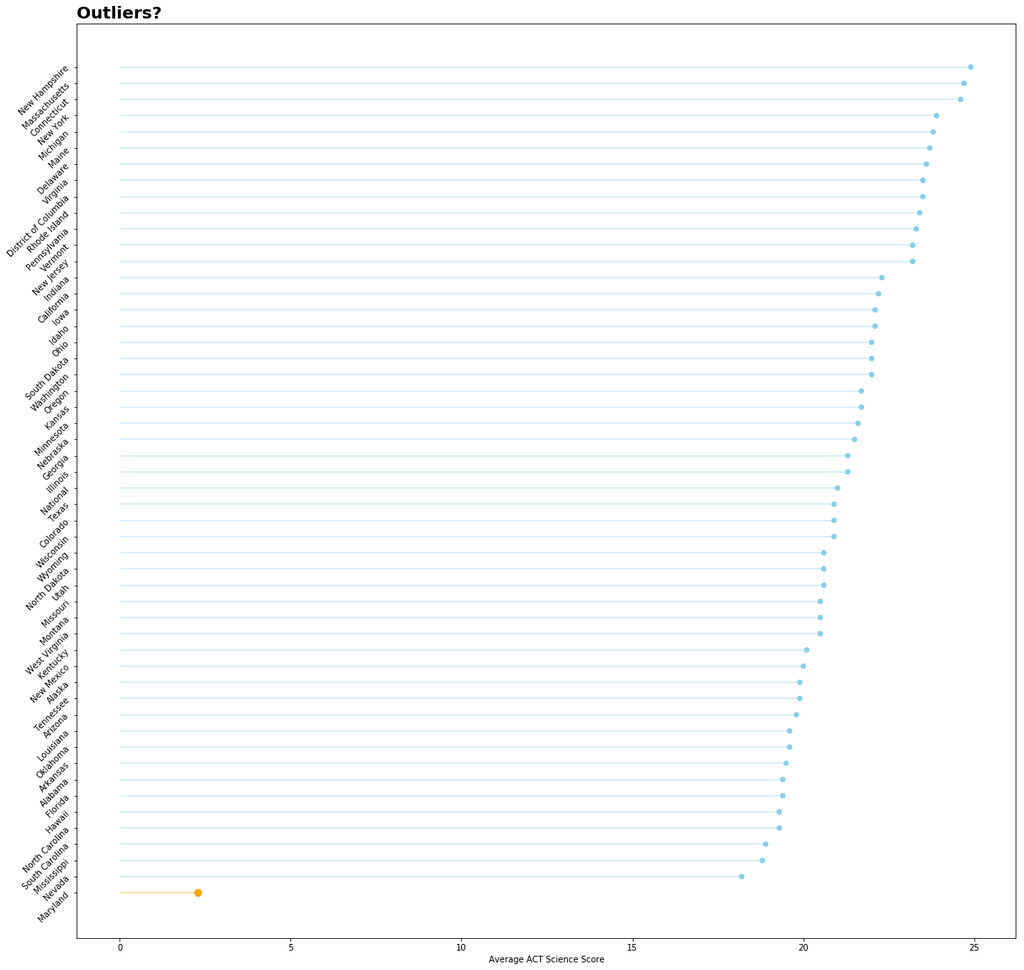

```python
# Reorder it following the values:
ordered_act_2017 = act_2017.sort_values(by='Science')
my_range=range(1,len(ordered_act_2017.index)+1)

# Create a color if the group is "B"
my_color=np.where(ordered_act_2017['State']=='Maryland', 'orange', 'skyblue')
my_size=np.where(ordered_act_2017['State']=='Maryland', 70, 30)

# The vertical plot is made using the hline function
# I load the seaborn library only to benefit the nice looking feature
plt.figure(figsize=(20,20))
plt.hlines(y=my_range, xmin=0, xmax=ordered_act_2017['Science'], color=my_color, alpha=0.4)
plt.scatter(ordered_act_2017['Science'], my_range, color=my_color, s=my_size, alpha=1)

# Add title and axis names
plt.yticks(my_range, ordered_act_2017['State'], rotation=45)
plt.title("Outliers?", loc='left', fontdict={'size':20,'fontweight':'bold'})
plt.xlabel('Average ACT Science Score')
```

We can manually change the errors but a proper way to approach this is to actually scrape the raw data and perform a join.

```python
headers = {'User-Agent':'Mozilla/5.0'}
sat_2017_url = requests.get('https://blog.collegevine.com/here-are-the-average-sat-scores-by-state/', headers = headers).text
sat_soup = BeautifulSoup(sat_2017_url,'lxml')
sat_table = sat_soup.find('table',{'style':"height: 1733px;"})
```

```python
table_rows = sat_table.findAll('tr')
l = []
for tr in table_rows:
    td = tr.find_all('td')
    row = [term.text for term in td]
    l.append(row)

scraped_sat_2017 = pd.DataFrame(l[1:],columns=l[0])
```

```python
scraped_sat_2017
```

|  | State | Participation | ERW | Math | Total |
| --- | --- | --- | --- | --- | --- |
| 0 | Alabama | 5% | 593 | 572 | 1165 |
| 1 | Alaska | 38% | 547 | 533 | 1080 |
| 2 | Arizona | 30% | 563 | 553 | 1116 |
| 3 | Arkansas | 3% | 614 | 594 | 1208 |
| 4 | California | 53% | 531 | 524 | 1055 |
| 5 | Colorado | 11% | 606 | 595 | 1201 |
| 6 | Connecticut | 100% | 530 | 512 | 1041 |
| 7 | Delaware | 100% | 503 | 492 | 996 |
| 8 | District of Columbia | 100% | 482 | 468 | 950 |
| 9 | Florida | 83% | 520 | 497 | 1017 |
| 10 | Georgia | 61% | 535 | 515 | 1050 |
| 11 | Hawaii | 55% | 544 | 541 | 1085 |
| 12 | Idaho | 93% | 513 | 493 | 1005 |
| 13 | Illinois | 9% | 559 | 556 | 1115 |
| 14 | Indiana | 63% | 542 | 532 | 1074 |
| 15 | Iowa | 2% | 641 | 635 | 1275 |
| 16 | Kansas | 4% | 632 | 628 | 1260 |
| 17 | Kentucky | 4% | 631 | 616 | 1247 |
| 18 | Louisiana | 4% | 611 | 586 | 1198 |
| 19 | Maine | 95% | 513 | 499 | 1012 |
| 20 | Maryland | 69% | 536 | 524 | 1060 |
| 21 | Massachusetts | 76% | 555 | 551 | 1107 |
| 22 | Michigan | 100% | 509 | 495 | 1005 |
| 23 | Minnesota | 3% | 644 | 651 | 1295 |
| 24 | Mississippi | 2% | 634 | 607 | 1242 |
| 25 | Missouri | 3% | 640 | 631 | 1271 |
| 26 | Montana | 10% | 605 | 591 | 1196 |
| 27 | Nebraska | 3% | 629 | 625 | 1253 |
| 28 | Nevada | 26% | 563 | 553 | 1116 |
| 29 | New Hampshire | 96% | 532 | 520 | 1052 |
| 30 | New Jersey | 70% | 530 | 526 | 1056 |
| 31 | New Mexico | 11% | 577 | 561 | 1138 |
| 32 | New York | 67% | 528 | 523 | 1052 |
| 33 | North Carolina | 49% | 546 | 535 | 1081 |
| 34 | North Dakota | 2% | 635 | 621 | 1256 |
| 35 | Ohio | 12% | 578 | 570 | 1149 |
| 36 | Oklahoma | 7% | 530 | 517 | 1047 |
| 37 | Oregon | 43% | 560 | 548 | 1108 |
| 38 | Pennsylvania | 65% | 540 | 531 | 1071 |
| 39 | Rhode Island | 71% | 539 | 524 | 1062 |
| 40 | South Carolina | 50% | 543 | 521 | 1064 |
| 41 | South Dakota | 3% | 612 | 603 | 1216 |
| 42 | Tennessee | 5% | 623 | 604 | 1228 |
| 43 | Texas | 62% | 513 | 507 | 1020 |
| 44 | Utah | 3% | 624 | 614 | 1238 |
| 45 | Vermont | 60% | 562 | 551 | 1114 |
| 46 | Virginia | 65% | 561 | 541 | 1102 |
| 47 | Washington | 64% | 541 | 534 | 1075 |
| 48 | West Virginia | 14% | 558 | 528 | 1086 |
| 49 | Wisconsin | 3% | 642 | 649 | 1291 |
| 50 | Wyoming | 3% | 626 | 604 | 1230 |
| 51 | National Average | N/A (1,715,481 total students tested) | 533 | 527 | 1060 |

```python
scraped_sat_2017.dtypes
```

```
State            object
Participation    object
ERW              object
Math             object
Total            object
dtype: object
```

```python
scraped_sat_2017.shape
```

```
(52, 5)
```

```python
scraped_sat_2017.columns
```

```
Index(['State', 'Participation', 'ERW', 'Math', 'Total'], dtype='object')
```

```python
ordered_sat_2017.shape
```

```
(51, 5)
```

```python
ordered_sat_2017.columns
```

```
Index(['State', 'Participation', 'ERW', 'Math', 'Total'], dtype='object')
```

```python
check_sat_2017 = scraped_sat_2017.merge(ordered_sat_2017, on=('State'), suffixes=('_l','_r'))
```

```python
check_sat_2017
```

|  | State | Participation_l | ERW_l | Math_l | Total_l | Participation_r | ERW_r | Math_r | Total_r |
| --- | --- | --- | --- | --- | --- | --- | --- | --- | --- |
| 0 | Alabama | 5% | 593 | 572 | 1165 | 0.05 | 593 | 572 | 1165 |
| 1 | Alaska | 38% | 547 | 533 | 1080 | 0.38 | 547 | 533 | 1080 |
| 2 | Arizona | 30% | 563 | 553 | 1116 | 0.30 | 563 | 553 | 1116 |
| 3 | Arkansas | 3% | 614 | 594 | 1208 | 0.03 | 614 | 594 | 1208 |
| 4 | California | 53% | 531 | 524 | 1055 | 0.53 | 531 | 524 | 1055 |
| 5 | Colorado | 11% | 606 | 595 | 1201 | 0.11 | 606 | 595 | 1201 |
| 6 | Connecticut | 100% | 530 | 512 | 1041 | 1.00 | 530 | 512 | 1041 |
| 7 | Delaware | 100% | 503 | 492 | 996 | 1.00 | 503 | 492 | 996 |
| 8 | District of Columbia | 100% | 482 | 468 | 950 | 1.00 | 482 | 468 | 950 |
| 9 | Florida | 83% | 520 | 497 | 1017 | 0.83 | 520 | 497 | 1017 |
| 10 | Georgia | 61% | 535 | 515 | 1050 | 0.61 | 535 | 515 | 1050 |
| 11 | Hawaii | 55% | 544 | 541 | 1085 | 0.55 | 544 | 541 | 1085 |
| 12 | Idaho | 93% | 513 | 493 | 1005 | 0.93 | 513 | 493 | 1005 |
| 13 | Illinois | 9% | 559 | 556 | 1115 | 0.09 | 559 | 556 | 1115 |
| 14 | Indiana | 63% | 542 | 532 | 1074 | 0.63 | 542 | 532 | 1074 |
| 15 | Iowa | 2% | 641 | 635 | 1275 | 0.02 | 641 | 635 | 1275 |
| 16 | Kansas | 4% | 632 | 628 | 1260 | 0.04 | 632 | 628 | 1260 |
| 17 | Kentucky | 4% | 631 | 616 | 1247 | 0.04 | 631 | 616 | 1247 |
| 18 | Louisiana | 4% | 611 | 586 | 1198 | 0.04 | 611 | 586 | 1198 |
| 19 | Maine | 95% | 513 | 499 | 1012 | 0.95 | 513 | 499 | 1012 |
| 20 | Maryland | 69% | 536 | 524 | 1060 | 0.69 | 536 | 52 | 1060 |
| 21 | Massachusetts | 76% | 555 | 551 | 1107 | 0.76 | 555 | 551 | 1107 |
| 22 | Michigan | 100% | 509 | 495 | 1005 | 1.00 | 509 | 495 | 1005 |
| 23 | Minnesota | 3% | 644 | 651 | 1295 | 0.03 | 644 | 651 | 1295 |
| 24 | Mississippi | 2% | 634 | 607 | 1242 | 0.02 | 634 | 607 | 1242 |
| 25 | Missouri | 3% | 640 | 631 | 1271 | 0.03 | 640 | 631 | 1271 |
| 26 | Montana | 10% | 605 | 591 | 1196 | 0.10 | 605 | 591 | 1196 |
| 27 | Nebraska | 3% | 629 | 625 | 1253 | 0.03 | 629 | 625 | 1253 |
| 28 | Nevada | 26% | 563 | 553 | 1116 | 0.26 | 563 | 553 | 1116 |
| 29 | New Hampshire | 96% | 532 | 520 | 1052 | 0.96 | 532 | 520 | 1052 |
| 30 | New Jersey | 70% | 530 | 526 | 1056 | 0.70 | 530 | 526 | 1056 |
| 31 | New Mexico | 11% | 577 | 561 | 1138 | 0.11 | 577 | 561 | 1138 |
| 32 | New York | 67% | 528 | 523 | 1052 | 0.67 | 528 | 523 | 1052 |
| 33 | North Carolina | 49% | 546 | 535 | 1081 | 0.49 | 546 | 535 | 1081 |
| 34 | North Dakota | 2% | 635 | 621 | 1256 | 0.02 | 635 | 621 | 1256 |
| 35 | Ohio | 12% | 578 | 570 | 1149 | 0.12 | 578 | 570 | 1149 |
| 36 | Oklahoma | 7% | 530 | 517 | 1047 | 0.07 | 530 | 517 | 1047 |
| 37 | Oregon | 43% | 560 | 548 | 1108 | 0.43 | 560 | 548 | 1108 |
| 38 | Pennsylvania | 65% | 540 | 531 | 1071 | 0.65 | 540 | 531 | 1071 |
| 39 | Rhode Island | 71% | 539 | 524 | 1062 | 0.71 | 539 | 524 | 1062 |
| 40 | South Carolina | 50% | 543 | 521 | 1064 | 0.50 | 543 | 521 | 1064 |
| 41 | South Dakota | 3% | 612 | 603 | 1216 | 0.03 | 612 | 603 | 1216 |
| 42 | Tennessee | 5% | 623 | 604 | 1228 | 0.05 | 623 | 604 | 1228 |
| 43 | Texas | 62% | 513 | 507 | 1020 | 0.62 | 513 | 507 | 1020 |
| 44 | Utah | 3% | 624 | 614 | 1238 | 0.03 | 624 | 614 | 1238 |
| 45 | Vermont | 60% | 562 | 551 | 1114 | 0.60 | 562 | 551 | 1114 |
| 46 | Virginia | 65% | 561 | 541 | 1102 | 0.65 | 561 | 541 | 1102 |
| 47 | Washington | 64% | 541 | 534 | 1075 | 0.64 | 541 | 534 | 1075 |
| 48 | West Virginia | 14% | 558 | 528 | 1086 | 0.14 | 558 | 528 | 1086 |
| 49 | Wisconsin | 3% | 642 | 649 | 1291 | 0.03 | 642 | 649 | 1291 |
| 50 | Wyoming | 3% | 626 | 604 | 1230 | 0.03 | 626 | 604 | 1230 |

```python
check_sat_2017.Participation_l = check_sat_2017.Participation_l.map(lambda x: float(p.search(x).group())/100)
```

```python
check_sat_2017
```

|  | State | Participation_l | ERW_l | Math_l | Total_l | Participation_r | ERW_r | Math_r | Total_r |
| --- | --- | --- | --- | --- | --- | --- | --- | --- | --- |
| 0 | Alabama | 0.05 | 593 | 572 | 1165 | 0.05 | 593 | 572 | 1165 |
| 1 | Alaska | 0.38 | 547 | 533 | 1080 | 0.38 | 547 | 533 | 1080 |
| 2 | Arizona | 0.30 | 563 | 553 | 1116 | 0.30 | 563 | 553 | 1116 |
| 3 | Arkansas | 0.03 | 614 | 594 | 1208 | 0.03 | 614 | 594 | 1208 |
| 4 | California | 0.53 | 531 | 524 | 1055 | 0.53 | 531 | 524 | 1055 |
| 5 | Colorado | 0.11 | 606 | 595 | 1201 | 0.11 | 606 | 595 | 1201 |
| 6 | Connecticut | 1.00 | 530 | 512 | 1041 | 1.00 | 530 | 512 | 1041 |
| 7 | Delaware | 1.00 | 503 | 492 | 996 | 1.00 | 503 | 492 | 996 |
| 8 | District of Columbia | 1.00 | 482 | 468 | 950 | 1.00 | 482 | 468 | 950 |
| 9 | Florida | 0.83 | 520 | 497 | 1017 | 0.83 | 520 | 497 | 1017 |
| 10 | Georgia | 0.61 | 535 | 515 | 1050 | 0.61 | 535 | 515 | 1050 |
| 11 | Hawaii | 0.55 | 544 | 541 | 1085 | 0.55 | 544 | 541 | 1085 |
| 12 | Idaho | 0.93 | 513 | 493 | 1005 | 0.93 | 513 | 493 | 1005 |
| 13 | Illinois | 0.09 | 559 | 556 | 1115 | 0.09 | 559 | 556 | 1115 |
| 14 | Indiana | 0.63 | 542 | 532 | 1074 | 0.63 | 542 | 532 | 1074 |
| 15 | Iowa | 0.02 | 641 | 635 | 1275 | 0.02 | 641 | 635 | 1275 |
| 16 | Kansas | 0.04 | 632 | 628 | 1260 | 0.04 | 632 | 628 | 1260 |
| 17 | Kentucky | 0.04 | 631 | 616 | 1247 | 0.04 | 631 | 616 | 1247 |
| 18 | Louisiana | 0.04 | 611 | 586 | 1198 | 0.04 | 611 | 586 | 1198 |
| 19 | Maine | 0.95 | 513 | 499 | 1012 | 0.95 | 513 | 499 | 1012 |
| 20 | Maryland | 0.69 | 536 | 524 | 1060 | 0.69 | 536 | 52 | 1060 |
| 21 | Massachusetts | 0.76 | 555 | 551 | 1107 | 0.76 | 555 | 551 | 1107 |
| 22 | Michigan | 1.00 | 509 | 495 | 1005 | 1.00 | 509 | 495 | 1005 |
| 23 | Minnesota | 0.03 | 644 | 651 | 1295 | 0.03 | 644 | 651 | 1295 |
| 24 | Mississippi | 0.02 | 634 | 607 | 1242 | 0.02 | 634 | 607 | 1242 |
| 25 | Missouri | 0.03 | 640 | 631 | 1271 | 0.03 | 640 | 631 | 1271 |
| 26 | Montana | 0.10 | 605 | 591 | 1196 | 0.10 | 605 | 591 | 1196 |
| 27 | Nebraska | 0.03 | 629 | 625 | 1253 | 0.03 | 629 | 625 | 1253 |
| 28 | Nevada | 0.26 | 563 | 553 | 1116 | 0.26 | 563 | 553 | 1116 |
| 29 | New Hampshire | 0.96 | 532 | 520 | 1052 | 0.96 | 532 | 520 | 1052 |
| 30 | New Jersey | 0.70 | 530 | 526 | 1056 | 0.70 | 530 | 526 | 1056 |
| 31 | New Mexico | 0.11 | 577 | 561 | 1138 | 0.11 | 577 | 561 | 1138 |
| 32 | New York | 0.67 | 528 | 523 | 1052 | 0.67 | 528 | 523 | 1052 |
| 33 | North Carolina | 0.49 | 546 | 535 | 1081 | 0.49 | 546 | 535 | 1081 |
| 34 | North Dakota | 0.02 | 635 | 621 | 1256 | 0.02 | 635 | 621 | 1256 |
| 35 | Ohio | 0.12 | 578 | 570 | 1149 | 0.12 | 578 | 570 | 1149 |
| 36 | Oklahoma | 0.07 | 530 | 517 | 1047 | 0.07 | 530 | 517 | 1047 |
| 37 | Oregon | 0.43 | 560 | 548 | 1108 | 0.43 | 560 | 548 | 1108 |
| 38 | Pennsylvania | 0.65 | 540 | 531 | 1071 | 0.65 | 540 | 531 | 1071 |
| 39 | Rhode Island | 0.71 | 539 | 524 | 1062 | 0.71 | 539 | 524 | 1062 |
| 40 | South Carolina | 0.50 | 543 | 521 | 1064 | 0.50 | 543 | 521 | 1064 |
| 41 | South Dakota | 0.03 | 612 | 603 | 1216 | 0.03 | 612 | 603 | 1216 |
| 42 | Tennessee | 0.05 | 623 | 604 | 1228 | 0.05 | 623 | 604 | 1228 |
| 43 | Texas | 0.62 | 513 | 507 | 1020 | 0.62 | 513 | 507 | 1020 |
| 44 | Utah | 0.03 | 624 | 614 | 1238 | 0.03 | 624 | 614 | 1238 |
| 45 | Vermont | 0.60 | 562 | 551 | 1114 | 0.60 | 562 | 551 | 1114 |
| 46 | Virginia | 0.65 | 561 | 541 | 1102 | 0.65 | 561 | 541 | 1102 |
| 47 | Washington | 0.64 | 541 | 534 | 1075 | 0.64 | 541 | 534 | 1075 |
| 48 | West Virginia | 0.14 | 558 | 528 | 1086 | 0.14 | 558 | 528 | 1086 |
| 49 | Wisconsin | 0.03 | 642 | 649 | 1291 | 0.03 | 642 | 649 | 1291 |
| 50 | Wyoming | 0.03 | 626 | 604 | 1230 | 0.03 | 626 | 604 | 1230 |

```python
check_sat_2017.ERW_l = check_sat_2017.ERW_l.map(lambda x: int(x))
check_sat_2017.Math_l = check_sat_2017.Math_l.map(lambda x: int(x))
check_sat_2017.Total_l = check_sat_2017.Total_l.map(lambda x: int(x))
check_sat_2017
```

|  | State | Participation_l | ERW_l | Math_l | Total_l | Participation_r | ERW_r | Math_r | Total_r |
| --- | --- | --- | --- | --- | --- | --- | --- | --- | --- |
| 0 | Alabama | 0.05 | 593 | 572 | 1165 | 0.05 | 593 | 572 | 1165 |
| 1 | Alaska | 0.38 | 547 | 533 | 1080 | 0.38 | 547 | 533 | 1080 |
| 2 | Arizona | 0.30 | 563 | 553 | 1116 | 0.30 | 563 | 553 | 1116 |
| 3 | Arkansas | 0.03 | 614 | 594 | 1208 | 0.03 | 614 | 594 | 1208 |
| 4 | California | 0.53 | 531 | 524 | 1055 | 0.53 | 531 | 524 | 1055 |
| 5 | Colorado | 0.11 | 606 | 595 | 1201 | 0.11 | 606 | 595 | 1201 |
| 6 | Connecticut | 1.00 | 530 | 512 | 1041 | 1.00 | 530 | 512 | 1041 |
| 7 | Delaware | 1.00 | 503 | 492 | 996 | 1.00 | 503 | 492 | 996 |
| 8 | District of Columbia | 1.00 | 482 | 468 | 950 | 1.00 | 482 | 468 | 950 |
| 9 | Florida | 0.83 | 520 | 497 | 1017 | 0.83 | 520 | 497 | 1017 |
| 10 | Georgia | 0.61 | 535 | 515 | 1050 | 0.61 | 535 | 515 | 1050 |
| 11 | Hawaii | 0.55 | 544 | 541 | 1085 | 0.55 | 544 | 541 | 1085 |
| 12 | Idaho | 0.93 | 513 | 493 | 1005 | 0.93 | 513 | 493 | 1005 |
| 13 | Illinois | 0.09 | 559 | 556 | 1115 | 0.09 | 559 | 556 | 1115 |
| 14 | Indiana | 0.63 | 542 | 532 | 1074 | 0.63 | 542 | 532 | 1074 |
| 15 | Iowa | 0.02 | 641 | 635 | 1275 | 0.02 | 641 | 635 | 1275 |
| 16 | Kansas | 0.04 | 632 | 628 | 1260 | 0.04 | 632 | 628 | 1260 |
| 17 | Kentucky | 0.04 | 631 | 616 | 1247 | 0.04 | 631 | 616 | 1247 |
| 18 | Louisiana | 0.04 | 611 | 586 | 1198 | 0.04 | 611 | 586 | 1198 |
| 19 | Maine | 0.95 | 513 | 499 | 1012 | 0.95 | 513 | 499 | 1012 |
| 20 | Maryland | 0.69 | 536 | 524 | 1060 | 0.69 | 536 | 52 | 1060 |
| 21 | Massachusetts | 0.76 | 555 | 551 | 1107 | 0.76 | 555 | 551 | 1107 |
| 22 | Michigan | 1.00 | 509 | 495 | 1005 | 1.00 | 509 | 495 | 1005 |
| 23 | Minnesota | 0.03 | 644 | 651 | 1295 | 0.03 | 644 | 651 | 1295 |
| 24 | Mississippi | 0.02 | 634 | 607 | 1242 | 0.02 | 634 | 607 | 1242 |
| 25 | Missouri | 0.03 | 640 | 631 | 1271 | 0.03 | 640 | 631 | 1271 |
| 26 | Montana | 0.10 | 605 | 591 | 1196 | 0.10 | 605 | 591 | 1196 |
| 27 | Nebraska | 0.03 | 629 | 625 | 1253 | 0.03 | 629 | 625 | 1253 |
| 28 | Nevada | 0.26 | 563 | 553 | 1116 | 0.26 | 563 | 553 | 1116 |
| 29 | New Hampshire | 0.96 | 532 | 520 | 1052 | 0.96 | 532 | 520 | 1052 |
| 30 | New Jersey | 0.70 | 530 | 526 | 1056 | 0.70 | 530 | 526 | 1056 |
| 31 | New Mexico | 0.11 | 577 | 561 | 1138 | 0.11 | 577 | 561 | 1138 |
| 32 | New York | 0.67 | 528 | 523 | 1052 | 0.67 | 528 | 523 | 1052 |
| 33 | North Carolina | 0.49 | 546 | 535 | 1081 | 0.49 | 546 | 535 | 1081 |
| 34 | North Dakota | 0.02 | 635 | 621 | 1256 | 0.02 | 635 | 621 | 1256 |
| 35 | Ohio | 0.12 | 578 | 570 | 1149 | 0.12 | 578 | 570 | 1149 |
| 36 | Oklahoma | 0.07 | 530 | 517 | 1047 | 0.07 | 530 | 517 | 1047 |
| 37 | Oregon | 0.43 | 560 | 548 | 1108 | 0.43 | 560 | 548 | 1108 |
| 38 | Pennsylvania | 0.65 | 540 | 531 | 1071 | 0.65 | 540 | 531 | 1071 |
| 39 | Rhode Island | 0.71 | 539 | 524 | 1062 | 0.71 | 539 | 524 | 1062 |
| 40 | South Carolina | 0.50 | 543 | 521 | 1064 | 0.50 | 543 | 521 | 1064 |
| 41 | South Dakota | 0.03 | 612 | 603 | 1216 | 0.03 | 612 | 603 | 1216 |
| 42 | Tennessee | 0.05 | 623 | 604 | 1228 | 0.05 | 623 | 604 | 1228 |
| 43 | Texas | 0.62 | 513 | 507 | 1020 | 0.62 | 513 | 507 | 1020 |
| 44 | Utah | 0.03 | 624 | 614 | 1238 | 0.03 | 624 | 614 | 1238 |
| 45 | Vermont | 0.60 | 562 | 551 | 1114 | 0.60 | 562 | 551 | 1114 |
| 46 | Virginia | 0.65 | 561 | 541 | 1102 | 0.65 | 561 | 541 | 1102 |
| 47 | Washington | 0.64 | 541 | 534 | 1075 | 0.64 | 541 | 534 | 1075 |
| 48 | West Virginia | 0.14 | 558 | 528 | 1086 | 0.14 | 558 | 528 | 1086 |
| 49 | Wisconsin | 0.03 | 642 | 649 | 1291 | 0.03 | 642 | 649 | 1291 |
| 50 | Wyoming | 0.03 | 626 | 604 | 1230 | 0.03 | 626 | 604 | 1230 |

```python
def agg_discrepancy(row):
    row['Agg_Discrepancy'] = row[['Participation_l','ERW_l','Math_l','Total_l']].sum() - \
    row[['Participation_r','ERW_r','Math_r','Total_r']].sum()
    return row

check_sat_2017.apply(agg_discrepancy, axis=1)
```

|  | State | Participation_l | ERW_l | Math_l | Total_l | Participation_r | ERW_r | Math_r | Total_r | Agg_Discrepancy |
| --- | --- | --- | --- | --- | --- | --- | --- | --- | --- | --- |
| 0 | Alabama | 0.05 | 593 | 572 | 1165 | 0.05 | 593 | 572 | 1165 | 0.0 |
| 1 | Alaska | 0.38 | 547 | 533 | 1080 | 0.38 | 547 | 533 | 1080 | 0.0 |
| 2 | Arizona | 0.30 | 563 | 553 | 1116 | 0.30 | 563 | 553 | 1116 | 0.0 |
| 3 | Arkansas | 0.03 | 614 | 594 | 1208 | 0.03 | 614 | 594 | 1208 | 0.0 |
| 4 | California | 0.53 | 531 | 524 | 1055 | 0.53 | 531 | 524 | 1055 | 0.0 |
| 5 | Colorado | 0.11 | 606 | 595 | 1201 | 0.11 | 606 | 595 | 1201 | 0.0 |
| 6 | Connecticut | 1.00 | 530 | 512 | 1041 | 1.00 | 530 | 512 | 1041 | 0.0 |
| 7 | Delaware | 1.00 | 503 | 492 | 996 | 1.00 | 503 | 492 | 996 | 0.0 |
| 8 | District of Columbia | 1.00 | 482 | 468 | 950 | 1.00 | 482 | 468 | 950 | 0.0 |
| 9 | Florida | 0.83 | 520 | 497 | 1017 | 0.83 | 520 | 497 | 1017 | 0.0 |
| 10 | Georgia | 0.61 | 535 | 515 | 1050 | 0.61 | 535 | 515 | 1050 | 0.0 |
| 11 | Hawaii | 0.55 | 544 | 541 | 1085 | 0.55 | 544 | 541 | 1085 | 0.0 |
| 12 | Idaho | 0.93 | 513 | 493 | 1005 | 0.93 | 513 | 493 | 1005 | 0.0 |
| 13 | Illinois | 0.09 | 559 | 556 | 1115 | 0.09 | 559 | 556 | 1115 | 0.0 |
| 14 | Indiana | 0.63 | 542 | 532 | 1074 | 0.63 | 542 | 532 | 1074 | 0.0 |
| 15 | Iowa | 0.02 | 641 | 635 | 1275 | 0.02 | 641 | 635 | 1275 | 0.0 |
| 16 | Kansas | 0.04 | 632 | 628 | 1260 | 0.04 | 632 | 628 | 1260 | 0.0 |
| 17 | Kentucky | 0.04 | 631 | 616 | 1247 | 0.04 | 631 | 616 | 1247 | 0.0 |
| 18 | Louisiana | 0.04 | 611 | 586 | 1198 | 0.04 | 611 | 586 | 1198 | 0.0 |
| 19 | Maine | 0.95 | 513 | 499 | 1012 | 0.95 | 513 | 499 | 1012 | 0.0 |
| 20 | Maryland | 0.69 | 536 | 524 | 1060 | 0.69 | 536 | 52 | 1060 | 472.0 |
| 21 | Massachusetts | 0.76 | 555 | 551 | 1107 | 0.76 | 555 | 551 | 1107 | 0.0 |
| 22 | Michigan | 1.00 | 509 | 495 | 1005 | 1.00 | 509 | 495 | 1005 | 0.0 |
| 23 | Minnesota | 0.03 | 644 | 651 | 1295 | 0.03 | 644 | 651 | 1295 | 0.0 |
| 24 | Mississippi | 0.02 | 634 | 607 | 1242 | 0.02 | 634 | 607 | 1242 | 0.0 |
| 25 | Missouri | 0.03 | 640 | 631 | 1271 | 0.03 | 640 | 631 | 1271 | 0.0 |
| 26 | Montana | 0.10 | 605 | 591 | 1196 | 0.10 | 605 | 591 | 1196 | 0.0 |
| 27 | Nebraska | 0.03 | 629 | 625 | 1253 | 0.03 | 629 | 625 | 1253 | 0.0 |
| 28 | Nevada | 0.26 | 563 | 553 | 1116 | 0.26 | 563 | 553 | 1116 | 0.0 |
| 29 | New Hampshire | 0.96 | 532 | 520 | 1052 | 0.96 | 532 | 520 | 1052 | 0.0 |
| 30 | New Jersey | 0.70 | 530 | 526 | 1056 | 0.70 | 530 | 526 | 1056 | 0.0 |
| 31 | New Mexico | 0.11 | 577 | 561 | 1138 | 0.11 | 577 | 561 | 1138 | 0.0 |
| 32 | New York | 0.67 | 528 | 523 | 1052 | 0.67 | 528 | 523 | 1052 | 0.0 |
| 33 | North Carolina | 0.49 | 546 | 535 | 1081 | 0.49 | 546 | 535 | 1081 | 0.0 |
| 34 | North Dakota | 0.02 | 635 | 621 | 1256 | 0.02 | 635 | 621 | 1256 | 0.0 |
| 35 | Ohio | 0.12 | 578 | 570 | 1149 | 0.12 | 578 | 570 | 1149 | 0.0 |
| 36 | Oklahoma | 0.07 | 530 | 517 | 1047 | 0.07 | 530 | 517 | 1047 | 0.0 |
| 37 | Oregon | 0.43 | 560 | 548 | 1108 | 0.43 | 560 | 548 | 1108 | 0.0 |
| 38 | Pennsylvania | 0.65 | 540 | 531 | 1071 | 0.65 | 540 | 531 | 1071 | 0.0 |
| 39 | Rhode Island | 0.71 | 539 | 524 | 1062 | 0.71 | 539 | 524 | 1062 | 0.0 |
| 40 | South Carolina | 0.50 | 543 | 521 | 1064 | 0.50 | 543 | 521 | 1064 | 0.0 |
| 41 | South Dakota | 0.03 | 612 | 603 | 1216 | 0.03 | 612 | 603 | 1216 | 0.0 |
| 42 | Tennessee | 0.05 | 623 | 604 | 1228 | 0.05 | 623 | 604 | 1228 | 0.0 |
| 43 | Texas | 0.62 | 513 | 507 | 1020 | 0.62 | 513 | 507 | 1020 | 0.0 |
| 44 | Utah | 0.03 | 624 | 614 | 1238 | 0.03 | 624 | 614 | 1238 | 0.0 |
| 45 | Vermont | 0.60 | 562 | 551 | 1114 | 0.60 | 562 | 551 | 1114 | 0.0 |
| 46 | Virginia | 0.65 | 561 | 541 | 1102 | 0.65 | 561 | 541 | 1102 | 0.0 |
| 47 | Washington | 0.64 | 541 | 534 | 1075 | 0.64 | 541 | 534 | 1075 | 0.0 |
| 48 | West Virginia | 0.14 | 558 | 528 | 1086 | 0.14 | 558 | 528 | 1086 | 0.0 |
| 49 | Wisconsin | 0.03 | 642 | 649 | 1291 | 0.03 | 642 | 649 | 1291 | 0.0 |
| 50 | Wyoming | 0.03 | 626 | 604 | 1230 | 0.03 | 626 | 604 | 1230 | 0.0 |

Now we know definitively that Maryland is incorrect.

```python
sat_2017.loc[sat_2017['State']=='Maryland',['Math']] = 524
sat_2017
```

|  | State | Participation | Evidence-Based Reading and Writing | Math | Total |
| --- | --- | --- | --- | --- | --- |
| 0 | Alabama | 0.05 | 593 | 572 | 1165 |
| 1 | Alaska | 0.38 | 547 | 533 | 1080 |
| 2 | Arizona | 0.30 | 563 | 553 | 1116 |
| 3 | Arkansas | 0.03 | 614 | 594 | 1208 |
| 4 | California | 0.53 | 531 | 524 | 1055 |
| 5 | Colorado | 0.11 | 606 | 595 | 1201 |
| 6 | Connecticut | 1.00 | 530 | 512 | 1041 |
| 7 | Delaware | 1.00 | 503 | 492 | 996 |
| 8 | District of Columbia | 1.00 | 482 | 468 | 950 |
| 9 | Florida | 0.83 | 520 | 497 | 1017 |
| 10 | Georgia | 0.61 | 535 | 515 | 1050 |
| 11 | Hawaii | 0.55 | 544 | 541 | 1085 |
| 12 | Idaho | 0.93 | 513 | 493 | 1005 |
| 13 | Illinois | 0.09 | 559 | 556 | 1115 |
| 14 | Indiana | 0.63 | 542 | 532 | 1074 |
| 15 | Iowa | 0.02 | 641 | 635 | 1275 |
| 16 | Kansas | 0.04 | 632 | 628 | 1260 |
| 17 | Kentucky | 0.04 | 631 | 616 | 1247 |
| 18 | Louisiana | 0.04 | 611 | 586 | 1198 |
| 19 | Maine | 0.95 | 513 | 499 | 1012 |
| 20 | Maryland | 0.69 | 536 | 524 | 1060 |
| 21 | Massachusetts | 0.76 | 555 | 551 | 1107 |
| 22 | Michigan | 1.00 | 509 | 495 | 1005 |
| 23 | Minnesota | 0.03 | 644 | 651 | 1295 |
| 24 | Mississippi | 0.02 | 634 | 607 | 1242 |
| 25 | Missouri | 0.03 | 640 | 631 | 1271 |
| 26 | Montana | 0.10 | 605 | 591 | 1196 |
| 27 | Nebraska | 0.03 | 629 | 625 | 1253 |
| 28 | Nevada | 0.26 | 563 | 553 | 1116 |
| 29 | New Hampshire | 0.96 | 532 | 520 | 1052 |
| 30 | New Jersey | 0.70 | 530 | 526 | 1056 |
| 31 | New Mexico | 0.11 | 577 | 561 | 1138 |
| 32 | New York | 0.67 | 528 | 523 | 1052 |
| 33 | North Carolina | 0.49 | 546 | 535 | 1081 |
| 34 | North Dakota | 0.02 | 635 | 621 | 1256 |
| 35 | Ohio | 0.12 | 578 | 570 | 1149 |
| 36 | Oklahoma | 0.07 | 530 | 517 | 1047 |
| 37 | Oregon | 0.43 | 560 | 548 | 1108 |
| 38 | Pennsylvania | 0.65 | 540 | 531 | 1071 |
| 39 | Rhode Island | 0.71 | 539 | 524 | 1062 |
| 40 | South Carolina | 0.50 | 543 | 521 | 1064 |
| 41 | South Dakota | 0.03 | 612 | 603 | 1216 |
| 42 | Tennessee | 0.05 | 623 | 604 | 1228 |
| 43 | Texas | 0.62 | 513 | 507 | 1020 |
| 44 | Utah | 0.03 | 624 | 614 | 1238 |
| 45 | Vermont | 0.60 | 562 | 551 | 1114 |
| 46 | Virginia | 0.65 | 561 | 541 | 1102 |
| 47 | Washington | 0.64 | 541 | 534 | 1075 |
| 48 | West Virginia | 0.14 | 558 | 528 | 1086 |
| 49 | Wisconsin | 0.03 | 642 | 649 | 1291 |
| 50 | Wyoming | 0.03 | 626 | 604 | 1230 |

```python
act_2017_url = requests.get('https://blog.prepscholar.com/act-scores-by-state-averages-highs-and-lows', headers = headers).text
act_soup = BeautifulSoup(act_2017_url,'lxml')
act_table = act_soup.findAll('table',{'style':"border-collapse: collapse;"})
```

```python
table_rows = act_table[1].findAll('tr')
l = []
for tr in table_rows:
    td = tr.find_all('td')
    row = [term.text for term in td]
    l.append(row)

scraped_act_2017 = pd.DataFrame(l[1:],columns=l[0])
scraped_act_2017
```

|  | State | Participation | English | Math | Reading | Science | Composite |
| --- | --- | --- | --- | --- | --- | --- | --- |
| 0 | Alabama | 100% | 18.9 | 18.4 | 19.7 | 19.4 | 19.2 |
| 1 | Alaska | 65% | 18.7 | 19.8 | 20.4 | 19.9 | 19.8 |
| 2 | Arizona | 62% | 18.6 | 19.8 | 20.1 | 19.8 | 19.7 |
| 3 | Arkansas | 100% | 18.9 | 19.0 | 19.7 | 19.5 | 19.4 |
| 4 | California | 31% | 22.5 | 22.7 | 23.1 | 22.2 | 22.8 |
| 5 | Colorado | 100% | 20.1 | 20.3 | 21.2 | 20.9 | 20.8 |
| 6 | Connecticut | 31% | 25.5 | 24.6 | 25.6 | 24.6 | 25.2 |
| 7 | Delaware | 18% | 24.1 | 23.4 | 24.8 | 23.6 | 24.1 |
| 8 | District of Columbia | 32% | 24.4 | 23.5 | 24.9 | 23.5 | 24.2 |
| 9 | Florida | 73% | 19.0 | 19.4 | 21.0 | 19.4 | 19.8 |
| 10 | Georgia | 55% | 21.0 | 20.9 | 22.0 | 21.3 | 21.4 |
| 11 | Hawaii | 90% | 17.8 | 19.2 | 19.2 | 19.3 | 19.0 |
| 12 | Idaho | 38% | 21.9 | 21.8 | 23.0 | 22.1 | 22.3 |
| 13 | Illinois | 93% | 21.0 | 21.2 | 21.6 | 21.3 | 21.4 |
| 14 | Indiana | 35% | 22.0 | 22.4 | 23.2 | 22.3 | 22.6 |
| 15 | Iowa | 67% | 21.2 | 21.3 | 22.6 | 22.1 | 21.9 |
| 16 | Kansas | 73% | 21.1 | 21.3 | 22.3 | 21.7 | 21.7 |
| 17 | Kentucky | 100% | 19.6 | 19.4 | 20.5 | 20.1 | 20.0 |
| 18 | Louisiana | 100% | 19.4 | 18.8 | 19.8 | 19.6 | 19.5 |
| 19 | Maine | 8% | 24.2 | 24.0 | 24.8 | 23.7 | 24.3 |
| 20 | Maryland | 28% | 23.3 | 23.1 | 24.2 | 23.2 | 23.6 |
| 21 | Massachusetts | 29% | 25.4 | 25.3 | 25.9 | 24.7 | 25.4 |
| 22 | Michigan | 29% | 24.1 | 23.7 | 24.5 | 23.8 | 24.1 |
| 23 | Minnesota | 100% | 20.4 | 21.5 | 21.8 | 21.6 | 21.5 |
| 24 | Mississippi | 100% | 18.2 | 18.1 | 18.8 | 18.8 | 18.6 |
| 25 | Missouri | 100% | 19.8 | 19.9 | 20.8 | 20.5 | 20.4 |
| 26 | Montana | 100% | 19.0 | 20.2 | 21.0 | 20.5 | 20.3 |
| 27 | Nebraska | 84% | 20.9 | 20.9 | 21.9 | 21.5 | 21.4 |
| 28 | Nevada | 100% | 16.3 | 18.0 | 18.1 | 18.2 | 17.8 |
| 29 | New Hampshire | 18% | 25.4 | 25.1 | 26.0 | 24.9 | 25.5 |
| 30 | New Jersey | 34% | 23.8 | 23.8 | 24.1 | 23.2 | 23.9 |
| 31 | New Mexico | 66% | 18.6 | 19.4 | 20.4 | 20.0 | 19.7 |
| 32 | New York | 31% | 23.8 | 24.0 | 24.6 | 23.9 | 24.2 |
| 33 | North Carolina | 100% | 17.8 | 19.3 | 19.6 | 19.3 | 19.1 |
| 34 | North Dakota | 98% | 19.0 | 20.4 | 20.5 | 20.6 | 20.3 |
| 35 | Ohio | 75% | 21.2 | 21.6 | 22.5 | 22.0 | 22.0 |
| 36 | Oklahoma | 100% | 18.5 | 18.8 | 20.1 | 19.6 | 19.4 |
| 37 | Oregon | 40% | 21.2 | 21.5 | 22.4 | 21.7 | 21.8 |
| 38 | Pennsylvania | 23% | 23.4 | 23.4 | 24.2 | 23.3 | 23.7 |
| 39 | Rhode Island | 21% | 24.0 | 23.3 | 24.7 | 23.4 | 24.0 |
| 40 | South Carolina | 100% | 17.5 | 18.6 | 19.1 | 18.9 | 18.7 |
| 41 | South Dakota | 80% | 20.7 | 21.5 | 22.3 | 22.0 | 21.8 |
| 42 | Tennessee | 100% | 19.5 | 19.2 | 20.1 | 19.9 | 19.8 |
| 43 | Texas | 45% | 19.5 | 20.7 | 21.1 | 20.9 | 20.7 |
| 44 | Utah | 100% | 19.5 | 19.9 | 20.8 | 20.6 | 20.3 |
| 45 | Vermont | 29% | 23.3 | 23.1 | 24.4 | 23.2 | 23.6 |
| 46 | Virginia | 29% | 23.5 | 23.3 | 24.6 | 23.5 | 23.8 |
| 47 | Washington | 29% | 20.9 | 21.9 | 22.1 | 22.0 | 21.9 |
| 48 | West Virginia | 69% | 20.0 | 19.4 | 21.2 | 20.5 | 20.4 |
| 49 | Wisconsin | 100% | 19.7 | 20.4 | 20.6 | 20.9 | 20.5 |
| 50 | Wyoming | 100% | 19.4 | 19.8 | 20.8 | 20.6 | 20.2 |
| 51 | National | 60% | 20.3 | 20.7 | 21.4 | 21.0 | 21.0 |

```python
scraped_act_2017.dtypes
```

```
State            object
Participation    object
English          object
Math             object
Reading          object
Science          object
Composite        object
dtype: object
```

```python
scraped_act_2017.Participation = scraped_act_2017.Participation.map(lambda x: float(p.search(x).group())/100)
scraped_act_2017.Composite = scraped_act_2017.Composite.map(lambda x: float(x))
scraped_act_2017.English = scraped_act_2017.English.map(lambda x: float(x))
scraped_act_2017.Math = scraped_act_2017.Math.map(lambda x: float(x))
scraped_act_2017.Reading = scraped_act_2017.Reading.map(lambda x: float(x))
scraped_act_2017.Science = scraped_act_2017.Science.map(lambda x: float(x))
```

```python
scraped_act_2017
```

|  | State | Participation | English | Math | Reading | Science | Composite |
| --- | --- | --- | --- | --- | --- | --- | --- |
| 0 | Alabama | 1.00 | 18.9 | 18.4 | 19.7 | 19.4 | 19.2 |
| 1 | Alaska | 0.65 | 18.7 | 19.8 | 20.4 | 19.9 | 19.8 |
| 2 | Arizona | 0.62 | 18.6 | 19.8 | 20.1 | 19.8 | 19.7 |
| 3 | Arkansas | 1.00 | 18.9 | 19.0 | 19.7 | 19.5 | 19.4 |
| 4 | California | 0.31 | 22.5 | 22.7 | 23.1 | 22.2 | 22.8 |
| 5 | Colorado | 1.00 | 20.1 | 20.3 | 21.2 | 20.9 | 20.8 |
| 6 | Connecticut | 0.31 | 25.5 | 24.6 | 25.6 | 24.6 | 25.2 |
| 7 | Delaware | 0.18 | 24.1 | 23.4 | 24.8 | 23.6 | 24.1 |
| 8 | District of Columbia | 0.32 | 24.4 | 23.5 | 24.9 | 23.5 | 24.2 |
| 9 | Florida | 0.73 | 19.0 | 19.4 | 21.0 | 19.4 | 19.8 |
| 10 | Georgia | 0.55 | 21.0 | 20.9 | 22.0 | 21.3 | 21.4 |
| 11 | Hawaii | 0.90 | 17.8 | 19.2 | 19.2 | 19.3 | 19.0 |
| 12 | Idaho | 0.38 | 21.9 | 21.8 | 23.0 | 22.1 | 22.3 |
| 13 | Illinois | 0.93 | 21.0 | 21.2 | 21.6 | 21.3 | 21.4 |
| 14 | Indiana | 0.35 | 22.0 | 22.4 | 23.2 | 22.3 | 22.6 |
| 15 | Iowa | 0.67 | 21.2 | 21.3 | 22.6 | 22.1 | 21.9 |
| 16 | Kansas | 0.73 | 21.1 | 21.3 | 22.3 | 21.7 | 21.7 |
| 17 | Kentucky | 1.00 | 19.6 | 19.4 | 20.5 | 20.1 | 20.0 |
| 18 | Louisiana | 1.00 | 19.4 | 18.8 | 19.8 | 19.6 | 19.5 |
| 19 | Maine | 0.08 | 24.2 | 24.0 | 24.8 | 23.7 | 24.3 |
| 20 | Maryland | 0.28 | 23.3 | 23.1 | 24.2 | 23.2 | 23.6 |
| 21 | Massachusetts | 0.29 | 25.4 | 25.3 | 25.9 | 24.7 | 25.4 |
| 22 | Michigan | 0.29 | 24.1 | 23.7 | 24.5 | 23.8 | 24.1 |
| 23 | Minnesota | 1.00 | 20.4 | 21.5 | 21.8 | 21.6 | 21.5 |
| 24 | Mississippi | 1.00 | 18.2 | 18.1 | 18.8 | 18.8 | 18.6 |
| 25 | Missouri | 1.00 | 19.8 | 19.9 | 20.8 | 20.5 | 20.4 |
| 26 | Montana | 1.00 | 19.0 | 20.2 | 21.0 | 20.5 | 20.3 |
| 27 | Nebraska | 0.84 | 20.9 | 20.9 | 21.9 | 21.5 | 21.4 |
| 28 | Nevada | 1.00 | 16.3 | 18.0 | 18.1 | 18.2 | 17.8 |
| 29 | New Hampshire | 0.18 | 25.4 | 25.1 | 26.0 | 24.9 | 25.5 |
| 30 | New Jersey | 0.34 | 23.8 | 23.8 | 24.1 | 23.2 | 23.9 |
| 31 | New Mexico | 0.66 | 18.6 | 19.4 | 20.4 | 20.0 | 19.7 |
| 32 | New York | 0.31 | 23.8 | 24.0 | 24.6 | 23.9 | 24.2 |
| 33 | North Carolina | 1.00 | 17.8 | 19.3 | 19.6 | 19.3 | 19.1 |
| 34 | North Dakota | 0.98 | 19.0 | 20.4 | 20.5 | 20.6 | 20.3 |
| 35 | Ohio | 0.75 | 21.2 | 21.6 | 22.5 | 22.0 | 22.0 |
| 36 | Oklahoma | 1.00 | 18.5 | 18.8 | 20.1 | 19.6 | 19.4 |
| 37 | Oregon | 0.40 | 21.2 | 21.5 | 22.4 | 21.7 | 21.8 |
| 38 | Pennsylvania | 0.23 | 23.4 | 23.4 | 24.2 | 23.3 | 23.7 |
| 39 | Rhode Island | 0.21 | 24.0 | 23.3 | 24.7 | 23.4 | 24.0 |
| 40 | South Carolina | 1.00 | 17.5 | 18.6 | 19.1 | 18.9 | 18.7 |
| 41 | South Dakota | 0.80 | 20.7 | 21.5 | 22.3 | 22.0 | 21.8 |
| 42 | Tennessee | 1.00 | 19.5 | 19.2 | 20.1 | 19.9 | 19.8 |
| 43 | Texas | 0.45 | 19.5 | 20.7 | 21.1 | 20.9 | 20.7 |
| 44 | Utah | 1.00 | 19.5 | 19.9 | 20.8 | 20.6 | 20.3 |
| 45 | Vermont | 0.29 | 23.3 | 23.1 | 24.4 | 23.2 | 23.6 |
| 46 | Virginia | 0.29 | 23.5 | 23.3 | 24.6 | 23.5 | 23.8 |
| 47 | Washington | 0.29 | 20.9 | 21.9 | 22.1 | 22.0 | 21.9 |
| 48 | West Virginia | 0.69 | 20.0 | 19.4 | 21.2 | 20.5 | 20.4 |
| 49 | Wisconsin | 1.00 | 19.7 | 20.4 | 20.6 | 20.9 | 20.5 |
| 50 | Wyoming | 1.00 | 19.4 | 19.8 | 20.8 | 20.6 | 20.2 |
| 51 | National | 0.60 | 20.3 | 20.7 | 21.4 | 21.0 | 21.0 |

```python
check_act_2017 = scraped_act_2017.merge(ordered_act_2017, on=('State'), suffixes=('_l','_r'))
check_act_2017
```

|  | State | Participation_l | English_l | Math_l | Reading_l | Science_l | Composite_l | Participation_r | English_r | Math_r | Reading_r | Science_r | Composite_r |
| --- | --- | --- | --- | --- | --- | --- | --- | --- | --- | --- | --- | --- | --- |
| 0 | Alabama | 1.00 | 18.9 | 18.4 | 19.7 | 19.4 | 19.2 | 1.00 | 18.9 | 18.4 | 19.7 | 19.4 | 19.2 |
| 1 | Alaska | 0.65 | 18.7 | 19.8 | 20.4 | 19.9 | 19.8 | 0.65 | 18.7 | 19.8 | 20.4 | 19.9 | 19.8 |
| 2 | Arizona | 0.62 | 18.6 | 19.8 | 20.1 | 19.8 | 19.7 | 0.62 | 18.6 | 19.8 | 20.1 | 19.8 | 19.7 |
| 3 | Arkansas | 1.00 | 18.9 | 19.0 | 19.7 | 19.5 | 19.4 | 1.00 | 18.9 | 19.0 | 19.7 | 19.5 | 19.4 |
| 4 | California | 0.31 | 22.5 | 22.7 | 23.1 | 22.2 | 22.8 | 0.31 | 22.5 | 22.7 | 23.1 | 22.2 | 22.8 |
| 5 | Colorado | 1.00 | 20.1 | 20.3 | 21.2 | 20.9 | 20.8 | 1.00 | 20.1 | 20.3 | 21.2 | 20.9 | 20.8 |
| 6 | Connecticut | 0.31 | 25.5 | 24.6 | 25.6 | 24.6 | 25.2 | 0.31 | 25.5 | 24.6 | 25.6 | 24.6 | 25.2 |
| 7 | Delaware | 0.18 | 24.1 | 23.4 | 24.8 | 23.6 | 24.1 | 0.18 | 24.1 | 23.4 | 24.8 | 23.6 | 24.1 |
| 8 | District of Columbia | 0.32 | 24.4 | 23.5 | 24.9 | 23.5 | 24.2 | 0.32 | 24.4 | 23.5 | 24.9 | 23.5 | 24.2 |
| 9 | Florida | 0.73 | 19.0 | 19.4 | 21.0 | 19.4 | 19.8 | 0.73 | 19.0 | 19.4 | 21.0 | 19.4 | 19.8 |
| 10 | Georgia | 0.55 | 21.0 | 20.9 | 22.0 | 21.3 | 21.4 | 0.55 | 21.0 | 20.9 | 22.0 | 21.3 | 21.4 |
| 11 | Hawaii | 0.90 | 17.8 | 19.2 | 19.2 | 19.3 | 19.0 | 0.90 | 17.8 | 19.2 | 19.2 | 19.3 | 19.0 |
| 12 | Idaho | 0.38 | 21.9 | 21.8 | 23.0 | 22.1 | 22.3 | 0.38 | 21.9 | 21.8 | 23.0 | 22.1 | 22.3 |
| 13 | Illinois | 0.93 | 21.0 | 21.2 | 21.6 | 21.3 | 21.4 | 0.93 | 21.0 | 21.2 | 21.6 | 21.3 | 21.4 |
| 14 | Indiana | 0.35 | 22.0 | 22.4 | 23.2 | 22.3 | 22.6 | 0.35 | 22.0 | 22.4 | 23.2 | 22.3 | 22.6 |
| 15 | Iowa | 0.67 | 21.2 | 21.3 | 22.6 | 22.1 | 21.9 | 0.67 | 21.2 | 21.3 | 22.6 | 22.1 | 21.9 |
| 16 | Kansas | 0.73 | 21.1 | 21.3 | 22.3 | 21.7 | 21.7 | 0.73 | 21.1 | 21.3 | 22.3 | 21.7 | 21.7 |
| 17 | Kentucky | 1.00 | 19.6 | 19.4 | 20.5 | 20.1 | 20.0 | 1.00 | 19.6 | 19.4 | 20.5 | 20.1 | 20.0 |
| 18 | Louisiana | 1.00 | 19.4 | 18.8 | 19.8 | 19.6 | 19.5 | 1.00 | 19.4 | 18.8 | 19.8 | 19.6 | 19.5 |
| 19 | Maine | 0.08 | 24.2 | 24.0 | 24.8 | 23.7 | 24.3 | 0.08 | 24.2 | 24.0 | 24.8 | 23.7 | 24.3 |
| 20 | Maryland | 0.28 | 23.3 | 23.1 | 24.2 | 23.2 | 23.6 | 0.28 | 23.3 | 23.1 | 24.2 | 2.3 | 23.6 |
| 21 | Massachusetts | 0.29 | 25.4 | 25.3 | 25.9 | 24.7 | 25.4 | 0.29 | 25.4 | 25.3 | 25.9 | 24.7 | 25.4 |
| 22 | Michigan | 0.29 | 24.1 | 23.7 | 24.5 | 23.8 | 24.1 | 0.29 | 24.1 | 23.7 | 24.5 | 23.8 | 24.1 |
| 23 | Minnesota | 1.00 | 20.4 | 21.5 | 21.8 | 21.6 | 21.5 | 1.00 | 20.4 | 21.5 | 21.8 | 21.6 | 21.5 |
| 24 | Mississippi | 1.00 | 18.2 | 18.1 | 18.8 | 18.8 | 18.6 | 1.00 | 18.2 | 18.1 | 18.8 | 18.8 | 18.6 |
| 25 | Missouri | 1.00 | 19.8 | 19.9 | 20.8 | 20.5 | 20.4 | 1.00 | 19.8 | 19.9 | 20.8 | 20.5 | 20.4 |
| 26 | Montana | 1.00 | 19.0 | 20.2 | 21.0 | 20.5 | 20.3 | 1.00 | 19.0 | 20.2 | 21.0 | 20.5 | 20.3 |
| 27 | Nebraska | 0.84 | 20.9 | 20.9 | 21.9 | 21.5 | 21.4 | 0.84 | 20.9 | 20.9 | 21.9 | 21.5 | 21.4 |
| 28 | Nevada | 1.00 | 16.3 | 18.0 | 18.1 | 18.2 | 17.8 | 1.00 | 16.3 | 18.0 | 18.1 | 18.2 | 17.8 |
| 29 | New Hampshire | 0.18 | 25.4 | 25.1 | 26.0 | 24.9 | 25.5 | 0.18 | 25.4 | 25.1 | 26.0 | 24.9 | 25.5 |
| 30 | New Jersey | 0.34 | 23.8 | 23.8 | 24.1 | 23.2 | 23.9 | 0.34 | 23.8 | 23.8 | 24.1 | 23.2 | 23.9 |
| 31 | New Mexico | 0.66 | 18.6 | 19.4 | 20.4 | 20.0 | 19.7 | 0.66 | 18.6 | 19.4 | 20.4 | 20.0 | 19.7 |
| 32 | New York | 0.31 | 23.8 | 24.0 | 24.6 | 23.9 | 24.2 | 0.31 | 23.8 | 24.0 | 24.6 | 23.9 | 24.2 |
| 33 | North Carolina | 1.00 | 17.8 | 19.3 | 19.6 | 19.3 | 19.1 | 1.00 | 17.8 | 19.3 | 19.6 | 19.3 | 19.1 |
| 34 | North Dakota | 0.98 | 19.0 | 20.4 | 20.5 | 20.6 | 20.3 | 0.98 | 19.0 | 20.4 | 20.5 | 20.6 | 20.3 |
| 35 | Ohio | 0.75 | 21.2 | 21.6 | 22.5 | 22.0 | 22.0 | 0.75 | 21.2 | 21.6 | 22.5 | 22.0 | 22.0 |
| 36 | Oklahoma | 1.00 | 18.5 | 18.8 | 20.1 | 19.6 | 19.4 | 1.00 | 18.5 | 18.8 | 20.1 | 19.6 | 19.4 |
| 37 | Oregon | 0.40 | 21.2 | 21.5 | 22.4 | 21.7 | 21.8 | 0.40 | 21.2 | 21.5 | 22.4 | 21.7 | 21.8 |
| 38 | Pennsylvania | 0.23 | 23.4 | 23.4 | 24.2 | 23.3 | 23.7 | 0.23 | 23.4 | 23.4 | 24.2 | 23.3 | 23.7 |
| 39 | Rhode Island | 0.21 | 24.0 | 23.3 | 24.7 | 23.4 | 24.0 | 0.21 | 24.0 | 23.3 | 24.7 | 23.4 | 24.0 |
| 40 | South Carolina | 1.00 | 17.5 | 18.6 | 19.1 | 18.9 | 18.7 | 1.00 | 17.5 | 18.6 | 19.1 | 18.9 | 18.7 |
| 41 | South Dakota | 0.80 | 20.7 | 21.5 | 22.3 | 22.0 | 21.8 | 0.80 | 20.7 | 21.5 | 22.3 | 22.0 | 21.8 |
| 42 | Tennessee | 1.00 | 19.5 | 19.2 | 20.1 | 19.9 | 19.8 | 1.00 | 19.5 | 19.2 | 20.1 | 19.9 | 19.8 |
| 43 | Texas | 0.45 | 19.5 | 20.7 | 21.1 | 20.9 | 20.7 | 0.45 | 19.5 | 20.7 | 21.1 | 20.9 | 20.7 |
| 44 | Utah | 1.00 | 19.5 | 19.9 | 20.8 | 20.6 | 20.3 | 1.00 | 19.5 | 19.9 | 20.8 | 20.6 | 20.3 |
| 45 | Vermont | 0.29 | 23.3 | 23.1 | 24.4 | 23.2 | 23.6 | 0.29 | 23.3 | 23.1 | 24.4 | 23.2 | 23.6 |
| 46 | Virginia | 0.29 | 23.5 | 23.3 | 24.6 | 23.5 | 23.8 | 0.29 | 23.5 | 23.3 | 24.6 | 23.5 | 23.8 |
| 47 | Washington | 0.29 | 20.9 | 21.9 | 22.1 | 22.0 | 21.9 | 0.29 | 20.9 | 21.9 | 22.1 | 22.0 | 21.9 |
| 48 | West Virginia | 0.69 | 20.0 | 19.4 | 21.2 | 20.5 | 20.4 | 0.69 | 20.0 | 19.4 | 21.2 | 20.5 | 20.4 |
| 49 | Wisconsin | 1.00 | 19.7 | 20.4 | 20.6 | 20.9 | 20.5 | 1.00 | 19.7 | 20.4 | 20.6 | 20.9 | 20.5 |
| 50 | Wyoming | 1.00 | 19.4 | 19.8 | 20.8 | 20.6 | 20.2 | 1.00 | 19.4 | 19.8 | 20.8 | 20.6 | 20.2 |
| 51 | National | 0.60 | 20.3 | 20.7 | 21.4 | 21.0 | 21.0 | 0.60 | 20.3 | 20.7 | 21.4 | 21.0 | 21.0 |

```python
def act_agg_discrep(row):
    row['Agg_Discrepancy'] = row[['Participation_l','English_l','Math_l','Science_l','Composite_l']].sum() -\
    row[['Participation_r','English_r','Math_r','Science_r','Composite_r']].sum()
    return row

check_act_2017.apply(act_agg_discrep, axis=1)
```

|  | State | Participation_l | English_l | Math_l | Reading_l | Science_l | Composite_l | Participation_r | English_r | Math_r | Reading_r | Science_r | Composite_r | Agg_Discrepancy |
| --- | --- | --- | --- | --- | --- | --- | --- | --- | --- | --- | --- | --- | --- | --- |
| 0 | Alabama | 1.00 | 18.9 | 18.4 | 19.7 | 19.4 | 19.2 | 1.00 | 18.9 | 18.4 | 19.7 | 19.4 | 19.2 | 0.0 |
| 1 | Alaska | 0.65 | 18.7 | 19.8 | 20.4 | 19.9 | 19.8 | 0.65 | 18.7 | 19.8 | 20.4 | 19.9 | 19.8 | 0.0 |
| 2 | Arizona | 0.62 | 18.6 | 19.8 | 20.1 | 19.8 | 19.7 | 0.62 | 18.6 | 19.8 | 20.1 | 19.8 | 19.7 | 0.0 |
| 3 | Arkansas | 1.00 | 18.9 | 19.0 | 19.7 | 19.5 | 19.4 | 1.00 | 18.9 | 19.0 | 19.7 | 19.5 | 19.4 | 0.0 |
| 4 | California | 0.31 | 22.5 | 22.7 | 23.1 | 22.2 | 22.8 | 0.31 | 22.5 | 22.7 | 23.1 | 22.2 | 22.8 | 0.0 |
| 5 | Colorado | 1.00 | 20.1 | 20.3 | 21.2 | 20.9 | 20.8 | 1.00 | 20.1 | 20.3 | 21.2 | 20.9 | 20.8 | 0.0 |
| 6 | Connecticut | 0.31 | 25.5 | 24.6 | 25.6 | 24.6 | 25.2 | 0.31 | 25.5 | 24.6 | 25.6 | 24.6 | 25.2 | 0.0 |
| 7 | Delaware | 0.18 | 24.1 | 23.4 | 24.8 | 23.6 | 24.1 | 0.18 | 24.1 | 23.4 | 24.8 | 23.6 | 24.1 | 0.0 |
| 8 | District of Columbia | 0.32 | 24.4 | 23.5 | 24.9 | 23.5 | 24.2 | 0.32 | 24.4 | 23.5 | 24.9 | 23.5 | 24.2 | 0.0 |
| 9 | Florida | 0.73 | 19.0 | 19.4 | 21.0 | 19.4 | 19.8 | 0.73 | 19.0 | 19.4 | 21.0 | 19.4 | 19.8 | 0.0 |
| 10 | Georgia | 0.55 | 21.0 | 20.9 | 22.0 | 21.3 | 21.4 | 0.55 | 21.0 | 20.9 | 22.0 | 21.3 | 21.4 | 0.0 |
| 11 | Hawaii | 0.90 | 17.8 | 19.2 | 19.2 | 19.3 | 19.0 | 0.90 | 17.8 | 19.2 | 19.2 | 19.3 | 19.0 | 0.0 |
| 12 | Idaho | 0.38 | 21.9 | 21.8 | 23.0 | 22.1 | 22.3 | 0.38 | 21.9 | 21.8 | 23.0 | 22.1 | 22.3 | 0.0 |
| 13 | Illinois | 0.93 | 21.0 | 21.2 | 21.6 | 21.3 | 21.4 | 0.93 | 21.0 | 21.2 | 21.6 | 21.3 | 21.4 | 0.0 |
| 14 | Indiana | 0.35 | 22.0 | 22.4 | 23.2 | 22.3 | 22.6 | 0.35 | 22.0 | 22.4 | 23.2 | 22.3 | 22.6 | 0.0 |
| 15 | Iowa | 0.67 | 21.2 | 21.3 | 22.6 | 22.1 | 21.9 | 0.67 | 21.2 | 21.3 | 22.6 | 22.1 | 21.9 | 0.0 |
| 16 | Kansas | 0.73 | 21.1 | 21.3 | 22.3 | 21.7 | 21.7 | 0.73 | 21.1 | 21.3 | 22.3 | 21.7 | 21.7 | 0.0 |
| 17 | Kentucky | 1.00 | 19.6 | 19.4 | 20.5 | 20.1 | 20.0 | 1.00 | 19.6 | 19.4 | 20.5 | 20.1 | 20.0 | 0.0 |
| 18 | Louisiana | 1.00 | 19.4 | 18.8 | 19.8 | 19.6 | 19.5 | 1.00 | 19.4 | 18.8 | 19.8 | 19.6 | 19.5 | 0.0 |
| 19 | Maine | 0.08 | 24.2 | 24.0 | 24.8 | 23.7 | 24.3 | 0.08 | 24.2 | 24.0 | 24.8 | 23.7 | 24.3 | 0.0 |
| 20 | Maryland | 0.28 | 23.3 | 23.1 | 24.2 | 23.2 | 23.6 | 0.28 | 23.3 | 23.1 | 24.2 | 2.3 | 23.6 | 20.9 |
| 21 | Massachusetts | 0.29 | 25.4 | 25.3 | 25.9 | 24.7 | 25.4 | 0.29 | 25.4 | 25.3 | 25.9 | 24.7 | 25.4 | 0.0 |
| 22 | Michigan | 0.29 | 24.1 | 23.7 | 24.5 | 23.8 | 24.1 | 0.29 | 24.1 | 23.7 | 24.5 | 23.8 | 24.1 | 0.0 |
| 23 | Minnesota | 1.00 | 20.4 | 21.5 | 21.8 | 21.6 | 21.5 | 1.00 | 20.4 | 21.5 | 21.8 | 21.6 | 21.5 | 0.0 |
| 24 | Mississippi | 1.00 | 18.2 | 18.1 | 18.8 | 18.8 | 18.6 | 1.00 | 18.2 | 18.1 | 18.8 | 18.8 | 18.6 | 0.0 |
| 25 | Missouri | 1.00 | 19.8 | 19.9 | 20.8 | 20.5 | 20.4 | 1.00 | 19.8 | 19.9 | 20.8 | 20.5 | 20.4 | 0.0 |
| 26 | Montana | 1.00 | 19.0 | 20.2 | 21.0 | 20.5 | 20.3 | 1.00 | 19.0 | 20.2 | 21.0 | 20.5 | 20.3 | 0.0 |
| 27 | Nebraska | 0.84 | 20.9 | 20.9 | 21.9 | 21.5 | 21.4 | 0.84 | 20.9 | 20.9 | 21.9 | 21.5 | 21.4 | 0.0 |
| 28 | Nevada | 1.00 | 16.3 | 18.0 | 18.1 | 18.2 | 17.8 | 1.00 | 16.3 | 18.0 | 18.1 | 18.2 | 17.8 | 0.0 |
| 29 | New Hampshire | 0.18 | 25.4 | 25.1 | 26.0 | 24.9 | 25.5 | 0.18 | 25.4 | 25.1 | 26.0 | 24.9 | 25.5 | 0.0 |
| 30 | New Jersey | 0.34 | 23.8 | 23.8 | 24.1 | 23.2 | 23.9 | 0.34 | 23.8 | 23.8 | 24.1 | 23.2 | 23.9 | 0.0 |
| 31 | New Mexico | 0.66 | 18.6 | 19.4 | 20.4 | 20.0 | 19.7 | 0.66 | 18.6 | 19.4 | 20.4 | 20.0 | 19.7 | 0.0 |
| 32 | New York | 0.31 | 23.8 | 24.0 | 24.6 | 23.9 | 24.2 | 0.31 | 23.8 | 24.0 | 24.6 | 23.9 | 24.2 | 0.0 |
| 33 | North Carolina | 1.00 | 17.8 | 19.3 | 19.6 | 19.3 | 19.1 | 1.00 | 17.8 | 19.3 | 19.6 | 19.3 | 19.1 | 0.0 |
| 34 | North Dakota | 0.98 | 19.0 | 20.4 | 20.5 | 20.6 | 20.3 | 0.98 | 19.0 | 20.4 | 20.5 | 20.6 | 20.3 | 0.0 |
| 35 | Ohio | 0.75 | 21.2 | 21.6 | 22.5 | 22.0 | 22.0 | 0.75 | 21.2 | 21.6 | 22.5 | 22.0 | 22.0 | 0.0 |
| 36 | Oklahoma | 1.00 | 18.5 | 18.8 | 20.1 | 19.6 | 19.4 | 1.00 | 18.5 | 18.8 | 20.1 | 19.6 | 19.4 | 0.0 |
| 37 | Oregon | 0.40 | 21.2 | 21.5 | 22.4 | 21.7 | 21.8 | 0.40 | 21.2 | 21.5 | 22.4 | 21.7 | 21.8 | 0.0 |
| 38 | Pennsylvania | 0.23 | 23.4 | 23.4 | 24.2 | 23.3 | 23.7 | 0.23 | 23.4 | 23.4 | 24.2 | 23.3 | 23.7 | 0.0 |
| 39 | Rhode Island | 0.21 | 24.0 | 23.3 | 24.7 | 23.4 | 24.0 | 0.21 | 24.0 | 23.3 | 24.7 | 23.4 | 24.0 | 0.0 |
| 40 | South Carolina | 1.00 | 17.5 | 18.6 | 19.1 | 18.9 | 18.7 | 1.00 | 17.5 | 18.6 | 19.1 | 18.9 | 18.7 | 0.0 |
| 41 | South Dakota | 0.80 | 20.7 | 21.5 | 22.3 | 22.0 | 21.8 | 0.80 | 20.7 | 21.5 | 22.3 | 22.0 | 21.8 | 0.0 |
| 42 | Tennessee | 1.00 | 19.5 | 19.2 | 20.1 | 19.9 | 19.8 | 1.00 | 19.5 | 19.2 | 20.1 | 19.9 | 19.8 | 0.0 |
| 43 | Texas | 0.45 | 19.5 | 20.7 | 21.1 | 20.9 | 20.7 | 0.45 | 19.5 | 20.7 | 21.1 | 20.9 | 20.7 | 0.0 |
| 44 | Utah | 1.00 | 19.5 | 19.9 | 20.8 | 20.6 | 20.3 | 1.00 | 19.5 | 19.9 | 20.8 | 20.6 | 20.3 | 0.0 |
| 45 | Vermont | 0.29 | 23.3 | 23.1 | 24.4 | 23.2 | 23.6 | 0.29 | 23.3 | 23.1 | 24.4 | 23.2 | 23.6 | 0.0 |
| 46 | Virginia | 0.29 | 23.5 | 23.3 | 24.6 | 23.5 | 23.8 | 0.29 | 23.5 | 23.3 | 24.6 | 23.5 | 23.8 | 0.0 |
| 47 | Washington | 0.29 | 20.9 | 21.9 | 22.1 | 22.0 | 21.9 | 0.29 | 20.9 | 21.9 | 22.1 | 22.0 | 21.9 | 0.0 |
| 48 | West Virginia | 0.69 | 20.0 | 19.4 | 21.2 | 20.5 | 20.4 | 0.69 | 20.0 | 19.4 | 21.2 | 20.5 | 20.4 | 0.0 |
| 49 | Wisconsin | 1.00 | 19.7 | 20.4 | 20.6 | 20.9 | 20.5 | 1.00 | 19.7 | 20.4 | 20.6 | 20.9 | 20.5 | 0.0 |
| 50 | Wyoming | 1.00 | 19.4 | 19.8 | 20.8 | 20.6 | 20.2 | 1.00 | 19.4 | 19.8 | 20.8 | 20.6 | 20.2 | 0.0 |
| 51 | National | 0.60 | 20.3 | 20.7 | 21.4 | 21.0 | 21.0 | 0.60 | 20.3 | 20.7 | 21.4 | 21.0 | 21.0 | 0.0 |

```python
act_2017.loc[act_2017['State']=='Maryland','Science'] = 23.2
act_2017
```

|  | State | Participation | English | Math | Reading | Science | Composite |
| --- | --- | --- | --- | --- | --- | --- | --- |
| 0 | National | 0.60 | 20.3 | 20.7 | 21.4 | 21.0 | 21.0 |
| 1 | Alabama | 1.00 | 18.9 | 18.4 | 19.7 | 19.4 | 19.2 |
| 2 | Alaska | 0.65 | 18.7 | 19.8 | 20.4 | 19.9 | 19.8 |
| 3 | Arizona | 0.62 | 18.6 | 19.8 | 20.1 | 19.8 | 19.7 |
| 4 | Arkansas | 1.00 | 18.9 | 19.0 | 19.7 | 19.5 | 19.4 |
| 5 | California | 0.31 | 22.5 | 22.7 | 23.1 | 22.2 | 22.8 |
| 6 | Colorado | 1.00 | 20.1 | 20.3 | 21.2 | 20.9 | 20.8 |
| 7 | Connecticut | 0.31 | 25.5 | 24.6 | 25.6 | 24.6 | 25.2 |
| 8 | Delaware | 0.18 | 24.1 | 23.4 | 24.8 | 23.6 | 24.1 |
| 9 | District of Columbia | 0.32 | 24.4 | 23.5 | 24.9 | 23.5 | 24.2 |
| 10 | Florida | 0.73 | 19.0 | 19.4 | 21.0 | 19.4 | 19.8 |
| 11 | Georgia | 0.55 | 21.0 | 20.9 | 22.0 | 21.3 | 21.4 |
| 12 | Hawaii | 0.90 | 17.8 | 19.2 | 19.2 | 19.3 | 19.0 |
| 13 | Idaho | 0.38 | 21.9 | 21.8 | 23.0 | 22.1 | 22.3 |
| 14 | Illinois | 0.93 | 21.0 | 21.2 | 21.6 | 21.3 | 21.4 |
| 15 | Indiana | 0.35 | 22.0 | 22.4 | 23.2 | 22.3 | 22.6 |
| 16 | Iowa | 0.67 | 21.2 | 21.3 | 22.6 | 22.1 | 21.9 |
| 17 | Kansas | 0.73 | 21.1 | 21.3 | 22.3 | 21.7 | 21.7 |
| 18 | Kentucky | 1.00 | 19.6 | 19.4 | 20.5 | 20.1 | 20.0 |
| 19 | Louisiana | 1.00 | 19.4 | 18.8 | 19.8 | 19.6 | 19.5 |
| 20 | Maine | 0.08 | 24.2 | 24.0 | 24.8 | 23.7 | 24.3 |
| 21 | Maryland | 0.28 | 23.3 | 23.1 | 24.2 | 23.2 | 23.6 |
| 22 | Massachusetts | 0.29 | 25.4 | 25.3 | 25.9 | 24.7 | 25.4 |
| 23 | Michigan | 0.29 | 24.1 | 23.7 | 24.5 | 23.8 | 24.1 |
| 24 | Minnesota | 1.00 | 20.4 | 21.5 | 21.8 | 21.6 | 21.5 |
| 25 | Mississippi | 1.00 | 18.2 | 18.1 | 18.8 | 18.8 | 18.6 |
| 26 | Missouri | 1.00 | 19.8 | 19.9 | 20.8 | 20.5 | 20.4 |
| 27 | Montana | 1.00 | 19.0 | 20.2 | 21.0 | 20.5 | 20.3 |
| 28 | Nebraska | 0.84 | 20.9 | 20.9 | 21.9 | 21.5 | 21.4 |
| 29 | Nevada | 1.00 | 16.3 | 18.0 | 18.1 | 18.2 | 17.8 |
| 30 | New Hampshire | 0.18 | 25.4 | 25.1 | 26.0 | 24.9 | 25.5 |
| 31 | New Jersey | 0.34 | 23.8 | 23.8 | 24.1 | 23.2 | 23.9 |
| 32 | New Mexico | 0.66 | 18.6 | 19.4 | 20.4 | 20.0 | 19.7 |
| 33 | New York | 0.31 | 23.8 | 24.0 | 24.6 | 23.9 | 24.2 |
| 34 | North Carolina | 1.00 | 17.8 | 19.3 | 19.6 | 19.3 | 19.1 |
| 35 | North Dakota | 0.98 | 19.0 | 20.4 | 20.5 | 20.6 | 20.3 |
| 36 | Ohio | 0.75 | 21.2 | 21.6 | 22.5 | 22.0 | 22.0 |
| 37 | Oklahoma | 1.00 | 18.5 | 18.8 | 20.1 | 19.6 | 19.4 |
| 38 | Oregon | 0.40 | 21.2 | 21.5 | 22.4 | 21.7 | 21.8 |
| 39 | Pennsylvania | 0.23 | 23.4 | 23.4 | 24.2 | 23.3 | 23.7 |
| 40 | Rhode Island | 0.21 | 24.0 | 23.3 | 24.7 | 23.4 | 24.0 |
| 41 | South Carolina | 1.00 | 17.5 | 18.6 | 19.1 | 18.9 | 18.7 |
| 42 | South Dakota | 0.80 | 20.7 | 21.5 | 22.3 | 22.0 | 21.8 |
| 43 | Tennessee | 1.00 | 19.5 | 19.2 | 20.1 | 19.9 | 19.8 |
| 44 | Texas | 0.45 | 19.5 | 20.7 | 21.1 | 20.9 | 20.7 |
| 45 | Utah | 1.00 | 19.5 | 19.9 | 20.8 | 20.6 | 20.3 |
| 46 | Vermont | 0.29 | 23.3 | 23.1 | 24.4 | 23.2 | 23.6 |
| 47 | Virginia | 0.29 | 23.5 | 23.3 | 24.6 | 23.5 | 23.8 |
| 48 | Washington | 0.29 | 20.9 | 21.9 | 22.1 | 22.0 | 21.9 |
| 49 | West Virginia | 0.69 | 20.0 | 19.4 | 21.2 | 20.5 | 20.4 |
| 50 | Wisconsin | 1.00 | 19.7 | 20.4 | 20.6 | 20.9 | 20.5 |
| 51 | Wyoming | 1.00 | 19.4 | 19.8 | 20.8 | 20.6 | 20.2 |

#### 5. What are your data types?

Display the data types of each feature.

```python
act_2017.dtypes
```

```
State             object
Participation    float64
English          float64
Math             float64
Reading          float64
Science          float64
Composite        float64
dtype: object
```

```python
sat_2017.dtypes
```

```
State                                  object
Participation                         float64
Evidence-Based Reading and Writing      int64
Math                                    int64
Total                                   int64
dtype: object
```

What did you learn?

- Do any of them seem odd?
- Which ones are not as they should be?

Already observed and fixed the errors prior.

#### 6. Fix Incorrect Data Types

Based on what you discovered above, use appropriate methods to re-type incorrectly typed data.

- Define a function that will allow you to convert participation rates to an appropriate numeric type. Use `map` or `apply` to change these columns in each dataframe.

Refer to :

Error Fixing

#### 7. Rename Columns

Change the names of the columns to more expressive names so that you can tell the difference the SAT columns and the ACT columns. Your solution should map all column names being changed at once (no repeated singular name-changes). **We will be combining these data with some of the data from 2018, and so you should name columns in an appropriate way**.

**Guidelines**:

- Column names should be all lowercase (you will thank yourself when you start pushing data to SQL later in the course)
- Column names should not contain spaces (underscores will suffice--this allows for using the `df.column_name` method to access columns in addition to `df['column_name']`.
- Column names should be unique and informative (the only feature that we actually share between dataframes is the state).

```python
sat_2017.rename(columns={'State':'state', 'Participation':'s_par_17','Evidence-Based Reading and Writing':'s_erw_17','Math'\
                        :'s_math_17','Total':'s_total_17'},inplace=True)
sat_2017
```

|  | state | s_par_17 | s_erw_17 | s_math_17 | s_total_17 |
| --- | --- | --- | --- | --- | --- |
| 0 | Alabama | 0.05 | 593 | 572 | 1165 |
| 1 | Alaska | 0.38 | 547 | 533 | 1080 |
| 2 | Arizona | 0.30 | 563 | 553 | 1116 |
| 3 | Arkansas | 0.03 | 614 | 594 | 1208 |
| 4 | California | 0.53 | 531 | 524 | 1055 |
| 5 | Colorado | 0.11 | 606 | 595 | 1201 |
| 6 | Connecticut | 1.00 | 530 | 512 | 1041 |
| 7 | Delaware | 1.00 | 503 | 492 | 996 |
| 8 | District of Columbia | 1.00 | 482 | 468 | 950 |
| 9 | Florida | 0.83 | 520 | 497 | 1017 |
| 10 | Georgia | 0.61 | 535 | 515 | 1050 |
| 11 | Hawaii | 0.55 | 544 | 541 | 1085 |
| 12 | Idaho | 0.93 | 513 | 493 | 1005 |
| 13 | Illinois | 0.09 | 559 | 556 | 1115 |
| 14 | Indiana | 0.63 | 542 | 532 | 1074 |
| 15 | Iowa | 0.02 | 641 | 635 | 1275 |
| 16 | Kansas | 0.04 | 632 | 628 | 1260 |
| 17 | Kentucky | 0.04 | 631 | 616 | 1247 |
| 18 | Louisiana | 0.04 | 611 | 586 | 1198 |
| 19 | Maine | 0.95 | 513 | 499 | 1012 |
| 20 | Maryland | 0.69 | 536 | 524 | 1060 |
| 21 | Massachusetts | 0.76 | 555 | 551 | 1107 |
| 22 | Michigan | 1.00 | 509 | 495 | 1005 |
| 23 | Minnesota | 0.03 | 644 | 651 | 1295 |
| 24 | Mississippi | 0.02 | 634 | 607 | 1242 |
| 25 | Missouri | 0.03 | 640 | 631 | 1271 |
| 26 | Montana | 0.10 | 605 | 591 | 1196 |
| 27 | Nebraska | 0.03 | 629 | 625 | 1253 |
| 28 | Nevada | 0.26 | 563 | 553 | 1116 |
| 29 | New Hampshire | 0.96 | 532 | 520 | 1052 |
| 30 | New Jersey | 0.70 | 530 | 526 | 1056 |
| 31 | New Mexico | 0.11 | 577 | 561 | 1138 |
| 32 | New York | 0.67 | 528 | 523 | 1052 |
| 33 | North Carolina | 0.49 | 546 | 535 | 1081 |
| 34 | North Dakota | 0.02 | 635 | 621 | 1256 |
| 35 | Ohio | 0.12 | 578 | 570 | 1149 |
| 36 | Oklahoma | 0.07 | 530 | 517 | 1047 |
| 37 | Oregon | 0.43 | 560 | 548 | 1108 |
| 38 | Pennsylvania | 0.65 | 540 | 531 | 1071 |
| 39 | Rhode Island | 0.71 | 539 | 524 | 1062 |
| 40 | South Carolina | 0.50 | 543 | 521 | 1064 |
| 41 | South Dakota | 0.03 | 612 | 603 | 1216 |
| 42 | Tennessee | 0.05 | 623 | 604 | 1228 |
| 43 | Texas | 0.62 | 513 | 507 | 1020 |
| 44 | Utah | 0.03 | 624 | 614 | 1238 |
| 45 | Vermont | 0.60 | 562 | 551 | 1114 |
| 46 | Virginia | 0.65 | 561 | 541 | 1102 |
| 47 | Washington | 0.64 | 541 | 534 | 1075 |
| 48 | West Virginia | 0.14 | 558 | 528 | 1086 |
| 49 | Wisconsin | 0.03 | 642 | 649 | 1291 |
| 50 | Wyoming | 0.03 | 626 | 604 | 1230 |

```python
act_2017.rename(columns={'State':'state','Participation':'a_par_17','English':'a_eng_17','Math':'a_math_17','Reading':\
                        'a_read_17','Science':'a_sci_17','Composite':'a_comp_17'},inplace=True)
act_2017
```

|  | state | a_par_17 | a_eng_17 | a_math_17 | a_read_17 | a_sci_17 | a_comp_17 |
| --- | --- | --- | --- | --- | --- | --- | --- |
| 0 | National | 0.60 | 20.3 | 20.7 | 21.4 | 21.0 | 21.0 |
| 1 | Alabama | 1.00 | 18.9 | 18.4 | 19.7 | 19.4 | 19.2 |
| 2 | Alaska | 0.65 | 18.7 | 19.8 | 20.4 | 19.9 | 19.8 |
| 3 | Arizona | 0.62 | 18.6 | 19.8 | 20.1 | 19.8 | 19.7 |
| 4 | Arkansas | 1.00 | 18.9 | 19.0 | 19.7 | 19.5 | 19.4 |
| 5 | California | 0.31 | 22.5 | 22.7 | 23.1 | 22.2 | 22.8 |
| 6 | Colorado | 1.00 | 20.1 | 20.3 | 21.2 | 20.9 | 20.8 |
| 7 | Connecticut | 0.31 | 25.5 | 24.6 | 25.6 | 24.6 | 25.2 |
| 8 | Delaware | 0.18 | 24.1 | 23.4 | 24.8 | 23.6 | 24.1 |
| 9 | District of Columbia | 0.32 | 24.4 | 23.5 | 24.9 | 23.5 | 24.2 |
| 10 | Florida | 0.73 | 19.0 | 19.4 | 21.0 | 19.4 | 19.8 |
| 11 | Georgia | 0.55 | 21.0 | 20.9 | 22.0 | 21.3 | 21.4 |
| 12 | Hawaii | 0.90 | 17.8 | 19.2 | 19.2 | 19.3 | 19.0 |
| 13 | Idaho | 0.38 | 21.9 | 21.8 | 23.0 | 22.1 | 22.3 |
| 14 | Illinois | 0.93 | 21.0 | 21.2 | 21.6 | 21.3 | 21.4 |
| 15 | Indiana | 0.35 | 22.0 | 22.4 | 23.2 | 22.3 | 22.6 |
| 16 | Iowa | 0.67 | 21.2 | 21.3 | 22.6 | 22.1 | 21.9 |
| 17 | Kansas | 0.73 | 21.1 | 21.3 | 22.3 | 21.7 | 21.7 |
| 18 | Kentucky | 1.00 | 19.6 | 19.4 | 20.5 | 20.1 | 20.0 |
| 19 | Louisiana | 1.00 | 19.4 | 18.8 | 19.8 | 19.6 | 19.5 |
| 20 | Maine | 0.08 | 24.2 | 24.0 | 24.8 | 23.7 | 24.3 |
| 21 | Maryland | 0.28 | 23.3 | 23.1 | 24.2 | 23.2 | 23.6 |
| 22 | Massachusetts | 0.29 | 25.4 | 25.3 | 25.9 | 24.7 | 25.4 |
| 23 | Michigan | 0.29 | 24.1 | 23.7 | 24.5 | 23.8 | 24.1 |
| 24 | Minnesota | 1.00 | 20.4 | 21.5 | 21.8 | 21.6 | 21.5 |
| 25 | Mississippi | 1.00 | 18.2 | 18.1 | 18.8 | 18.8 | 18.6 |
| 26 | Missouri | 1.00 | 19.8 | 19.9 | 20.8 | 20.5 | 20.4 |
| 27 | Montana | 1.00 | 19.0 | 20.2 | 21.0 | 20.5 | 20.3 |
| 28 | Nebraska | 0.84 | 20.9 | 20.9 | 21.9 | 21.5 | 21.4 |
| 29 | Nevada | 1.00 | 16.3 | 18.0 | 18.1 | 18.2 | 17.8 |
| 30 | New Hampshire | 0.18 | 25.4 | 25.1 | 26.0 | 24.9 | 25.5 |
| 31 | New Jersey | 0.34 | 23.8 | 23.8 | 24.1 | 23.2 | 23.9 |
| 32 | New Mexico | 0.66 | 18.6 | 19.4 | 20.4 | 20.0 | 19.7 |
| 33 | New York | 0.31 | 23.8 | 24.0 | 24.6 | 23.9 | 24.2 |
| 34 | North Carolina | 1.00 | 17.8 | 19.3 | 19.6 | 19.3 | 19.1 |
| 35 | North Dakota | 0.98 | 19.0 | 20.4 | 20.5 | 20.6 | 20.3 |
| 36 | Ohio | 0.75 | 21.2 | 21.6 | 22.5 | 22.0 | 22.0 |
| 37 | Oklahoma | 1.00 | 18.5 | 18.8 | 20.1 | 19.6 | 19.4 |
| 38 | Oregon | 0.40 | 21.2 | 21.5 | 22.4 | 21.7 | 21.8 |
| 39 | Pennsylvania | 0.23 | 23.4 | 23.4 | 24.2 | 23.3 | 23.7 |
| 40 | Rhode Island | 0.21 | 24.0 | 23.3 | 24.7 | 23.4 | 24.0 |
| 41 | South Carolina | 1.00 | 17.5 | 18.6 | 19.1 | 18.9 | 18.7 |
| 42 | South Dakota | 0.80 | 20.7 | 21.5 | 22.3 | 22.0 | 21.8 |
| 43 | Tennessee | 1.00 | 19.5 | 19.2 | 20.1 | 19.9 | 19.8 |
| 44 | Texas | 0.45 | 19.5 | 20.7 | 21.1 | 20.9 | 20.7 |
| 45 | Utah | 1.00 | 19.5 | 19.9 | 20.8 | 20.6 | 20.3 |
| 46 | Vermont | 0.29 | 23.3 | 23.1 | 24.4 | 23.2 | 23.6 |
| 47 | Virginia | 0.29 | 23.5 | 23.3 | 24.6 | 23.5 | 23.8 |
| 48 | Washington | 0.29 | 20.9 | 21.9 | 22.1 | 22.0 | 21.9 |
| 49 | West Virginia | 0.69 | 20.0 | 19.4 | 21.2 | 20.5 | 20.4 |
| 50 | Wisconsin | 1.00 | 19.7 | 20.4 | 20.6 | 20.9 | 20.5 |
| 51 | Wyoming | 1.00 | 19.4 | 19.8 | 20.8 | 20.6 | 20.2 |

#### 8. Create a data dictionary

Now that we've fixed our data, and given it appropriate names, let's create a [data dictionary](http://library.ucmerced.edu/node/10249).

A data dictionary provides a quick overview of features/variables/columns, alongside data types and descriptions. The more descriptive you can be, the more useful this document is.

Example of a Fictional Data Dictionary Entry:

| Feature | Type | Dataset | Description |
| --- | --- | --- | --- |
| **county_pop** | *integer* | 2010 census | The population of the county (units in thousands, where 2.5 represents 2500 people). |
| **per_poverty** | *float* | 2010 census | The percent of the county over the age of 18 living below the 200% of official US poverty rate (units percent to two decimal places 98.10 means 98.1%) |

[Here's a quick link to a short guide for formatting markdown in Jupyter notebooks](https://jupyter-notebook.readthedocs.io/en/stable/examples/Notebook/Working%20With%20Markdown%20Cells.html).

Provided is the skeleton for formatting a markdown table, with columns headers that will help you create a data dictionary to quickly summarize your data, as well as some examples. **This would be a great thing to copy and paste into your custom README for this project.**

| Feature | Type | Dataset | Description |
| --- | --- | --- | --- |
| state | object | ACT / SAT 2017 | State from which the observation is drawn |
| s_par_17 | float64 | SAT 2017 | Participation rate of the SAT in 2017 expressed as a decimal |
| s_math_17 | int64 | SAT 2017 | Average score of the SAT Math section in 2017 |
| s_erw_17 | int64 | SAT 2017 | Average score of the SAT Evidence-Based Reading and Writing section in 2017 |
| s_total_17 | int64 | SAT 2017 | Average score of the SAT in 2017 |
| a_par_17 | float64 | ACT 2017 | Participation rate of the ACT in 2017 expressed as a decimal |
| a_eng_17 | float64 | ACT 2017 | Average score of the ACT English section in 2017 |
| a_math_17 | float64 | ACT 2017 | Average score of the ACT Math section in 2017 |
| a_read_17 | float64 | ACT 2017 | Average score of the ACT Reading section in 2017 |
| a_sci_17 | float64 | ACT 2017 | Average score of the ACT Science section in 2017 |
| a_comp_17 | float64 | ACT 2017 | Average score of the ACT in 2017 |

#### 9. Drop unnecessary rows

One of our dataframes contains an extra row. Identify and remove this from the dataframe.

Actually this is unnecessary since we can do a merge by `state` using the default `how='inner'` which would automatically drop row in `act_2017` where `state == 'National'`. Nevertheless, here we go.

```python
act_2017 = act_2017[act_2017.state != 'National'] #I'd rather use this than drop
```

#### 10. Merge Dataframes

Join the 2017 ACT and SAT dataframes using the state in each dataframe as the key. Assign this to a new variable.

```python
act_sat_2017 = act_2017.merge(sat_2017,on='state')
act_sat_2017
```

|  | state | a_par_17 | a_eng_17 | a_math_17 | a_read_17 | a_sci_17 | a_comp_17 | s_par_17 | s_erw_17 | s_math_17 | s_total_17 |
| --- | --- | --- | --- | --- | --- | --- | --- | --- | --- | --- | --- |
| 0 | Alabama | 1.00 | 18.9 | 18.4 | 19.7 | 19.4 | 19.2 | 0.05 | 593 | 572 | 1165 |
| 1 | Alaska | 0.65 | 18.7 | 19.8 | 20.4 | 19.9 | 19.8 | 0.38 | 547 | 533 | 1080 |
| 2 | Arizona | 0.62 | 18.6 | 19.8 | 20.1 | 19.8 | 19.7 | 0.30 | 563 | 553 | 1116 |
| 3 | Arkansas | 1.00 | 18.9 | 19.0 | 19.7 | 19.5 | 19.4 | 0.03 | 614 | 594 | 1208 |
| 4 | California | 0.31 | 22.5 | 22.7 | 23.1 | 22.2 | 22.8 | 0.53 | 531 | 524 | 1055 |
| 5 | Colorado | 1.00 | 20.1 | 20.3 | 21.2 | 20.9 | 20.8 | 0.11 | 606 | 595 | 1201 |
| 6 | Connecticut | 0.31 | 25.5 | 24.6 | 25.6 | 24.6 | 25.2 | 1.00 | 530 | 512 | 1041 |
| 7 | Delaware | 0.18 | 24.1 | 23.4 | 24.8 | 23.6 | 24.1 | 1.00 | 503 | 492 | 996 |
| 8 | District of Columbia | 0.32 | 24.4 | 23.5 | 24.9 | 23.5 | 24.2 | 1.00 | 482 | 468 | 950 |
| 9 | Florida | 0.73 | 19.0 | 19.4 | 21.0 | 19.4 | 19.8 | 0.83 | 520 | 497 | 1017 |
| 10 | Georgia | 0.55 | 21.0 | 20.9 | 22.0 | 21.3 | 21.4 | 0.61 | 535 | 515 | 1050 |
| 11 | Hawaii | 0.90 | 17.8 | 19.2 | 19.2 | 19.3 | 19.0 | 0.55 | 544 | 541 | 1085 |
| 12 | Idaho | 0.38 | 21.9 | 21.8 | 23.0 | 22.1 | 22.3 | 0.93 | 513 | 493 | 1005 |
| 13 | Illinois | 0.93 | 21.0 | 21.2 | 21.6 | 21.3 | 21.4 | 0.09 | 559 | 556 | 1115 |
| 14 | Indiana | 0.35 | 22.0 | 22.4 | 23.2 | 22.3 | 22.6 | 0.63 | 542 | 532 | 1074 |
| 15 | Iowa | 0.67 | 21.2 | 21.3 | 22.6 | 22.1 | 21.9 | 0.02 | 641 | 635 | 1275 |
| 16 | Kansas | 0.73 | 21.1 | 21.3 | 22.3 | 21.7 | 21.7 | 0.04 | 632 | 628 | 1260 |
| 17 | Kentucky | 1.00 | 19.6 | 19.4 | 20.5 | 20.1 | 20.0 | 0.04 | 631 | 616 | 1247 |
| 18 | Louisiana | 1.00 | 19.4 | 18.8 | 19.8 | 19.6 | 19.5 | 0.04 | 611 | 586 | 1198 |
| 19 | Maine | 0.08 | 24.2 | 24.0 | 24.8 | 23.7 | 24.3 | 0.95 | 513 | 499 | 1012 |
| 20 | Maryland | 0.28 | 23.3 | 23.1 | 24.2 | 23.2 | 23.6 | 0.69 | 536 | 524 | 1060 |
| 21 | Massachusetts | 0.29 | 25.4 | 25.3 | 25.9 | 24.7 | 25.4 | 0.76 | 555 | 551 | 1107 |
| 22 | Michigan | 0.29 | 24.1 | 23.7 | 24.5 | 23.8 | 24.1 | 1.00 | 509 | 495 | 1005 |
| 23 | Minnesota | 1.00 | 20.4 | 21.5 | 21.8 | 21.6 | 21.5 | 0.03 | 644 | 651 | 1295 |
| 24 | Mississippi | 1.00 | 18.2 | 18.1 | 18.8 | 18.8 | 18.6 | 0.02 | 634 | 607 | 1242 |
| 25 | Missouri | 1.00 | 19.8 | 19.9 | 20.8 | 20.5 | 20.4 | 0.03 | 640 | 631 | 1271 |
| 26 | Montana | 1.00 | 19.0 | 20.2 | 21.0 | 20.5 | 20.3 | 0.10 | 605 | 591 | 1196 |
| 27 | Nebraska | 0.84 | 20.9 | 20.9 | 21.9 | 21.5 | 21.4 | 0.03 | 629 | 625 | 1253 |
| 28 | Nevada | 1.00 | 16.3 | 18.0 | 18.1 | 18.2 | 17.8 | 0.26 | 563 | 553 | 1116 |
| 29 | New Hampshire | 0.18 | 25.4 | 25.1 | 26.0 | 24.9 | 25.5 | 0.96 | 532 | 520 | 1052 |
| 30 | New Jersey | 0.34 | 23.8 | 23.8 | 24.1 | 23.2 | 23.9 | 0.70 | 530 | 526 | 1056 |
| 31 | New Mexico | 0.66 | 18.6 | 19.4 | 20.4 | 20.0 | 19.7 | 0.11 | 577 | 561 | 1138 |
| 32 | New York | 0.31 | 23.8 | 24.0 | 24.6 | 23.9 | 24.2 | 0.67 | 528 | 523 | 1052 |
| 33 | North Carolina | 1.00 | 17.8 | 19.3 | 19.6 | 19.3 | 19.1 | 0.49 | 546 | 535 | 1081 |
| 34 | North Dakota | 0.98 | 19.0 | 20.4 | 20.5 | 20.6 | 20.3 | 0.02 | 635 | 621 | 1256 |
| 35 | Ohio | 0.75 | 21.2 | 21.6 | 22.5 | 22.0 | 22.0 | 0.12 | 578 | 570 | 1149 |
| 36 | Oklahoma | 1.00 | 18.5 | 18.8 | 20.1 | 19.6 | 19.4 | 0.07 | 530 | 517 | 1047 |
| 37 | Oregon | 0.40 | 21.2 | 21.5 | 22.4 | 21.7 | 21.8 | 0.43 | 560 | 548 | 1108 |
| 38 | Pennsylvania | 0.23 | 23.4 | 23.4 | 24.2 | 23.3 | 23.7 | 0.65 | 540 | 531 | 1071 |
| 39 | Rhode Island | 0.21 | 24.0 | 23.3 | 24.7 | 23.4 | 24.0 | 0.71 | 539 | 524 | 1062 |
| 40 | South Carolina | 1.00 | 17.5 | 18.6 | 19.1 | 18.9 | 18.7 | 0.50 | 543 | 521 | 1064 |
| 41 | South Dakota | 0.80 | 20.7 | 21.5 | 22.3 | 22.0 | 21.8 | 0.03 | 612 | 603 | 1216 |
| 42 | Tennessee | 1.00 | 19.5 | 19.2 | 20.1 | 19.9 | 19.8 | 0.05 | 623 | 604 | 1228 |
| 43 | Texas | 0.45 | 19.5 | 20.7 | 21.1 | 20.9 | 20.7 | 0.62 | 513 | 507 | 1020 |
| 44 | Utah | 1.00 | 19.5 | 19.9 | 20.8 | 20.6 | 20.3 | 0.03 | 624 | 614 | 1238 |
| 45 | Vermont | 0.29 | 23.3 | 23.1 | 24.4 | 23.2 | 23.6 | 0.60 | 562 | 551 | 1114 |
| 46 | Virginia | 0.29 | 23.5 | 23.3 | 24.6 | 23.5 | 23.8 | 0.65 | 561 | 541 | 1102 |
| 47 | Washington | 0.29 | 20.9 | 21.9 | 22.1 | 22.0 | 21.9 | 0.64 | 541 | 534 | 1075 |
| 48 | West Virginia | 0.69 | 20.0 | 19.4 | 21.2 | 20.5 | 20.4 | 0.14 | 558 | 528 | 1086 |
| 49 | Wisconsin | 1.00 | 19.7 | 20.4 | 20.6 | 20.9 | 20.5 | 0.03 | 642 | 649 | 1291 |
| 50 | Wyoming | 1.00 | 19.4 | 19.8 | 20.8 | 20.6 | 20.2 | 0.03 | 626 | 604 | 1230 |

#### 11. Save your cleaned, merged dataframe

Use a relative path to save out your data as `combined_2017.csv`.

```python
os.getcwd()
act_sat_2017.to_csv(r'..\data\act_sat_2017.csv',index=False)
```

## 2018 Data Import and Cleaning

Links to the 2018 ACT and SAT data are provided in the README. These data live in PDFs, and so you'll get to enjoy practicing some *manual* data collection. Save these data as a CSV in your `data` directory, and import, explore, and clean these data in the same way you did above. **Make sure you comment on your steps so it is clear *why* you are doing each process**.

```python
# using the files provided by Yu Bin for the class. If there's time, I'll come back to this with PyPDF2 / pdftotext / tabula-py
# I'll also use code to scrape the ACT data from the magoosh site, but this is actually still incorrect as is the case for
# the prior webscraping steps as these are still secondary sources of data, thus even if my scraping steps eliminates human
# error on my part (by eliminating errors from manual data collection on my end), it doesn't eliminate inherited errors from
# the secondary source.

act_2018_url = 'https://magoosh.com/hs/act/2016/average-act-score-by-state/'
path = requests.get(act_2018_url, headers=headers).text
soup = BeautifulSoup(path,'lxml')
act_2018_table = soup.find('table', {'id':'tablepress-27'})
table_rows = act_2018_table.findAll('tr')
l = []
for tr in table_rows:
    td = tr.find_all('td')
    row = [term.text for term in td]
    l.append(row)

l
```

```
[[],
 ['Alabama', '100', '19.1', '18.9', '18.3', '19.6', '19.0'],
 ['Alaska', '33', '20.8', '19.8', '20.6', '21.6', '20.7'],
 ['Arizona', '66', '19.2', '18.2', '19.4', '19.5', '19.2'],
 ['Arkansas', '100', '19.4', '19.1', '18.9', '19.7', '19.4'],
 ['California', '27', '22.7', '22.5', '22.5', '23.0', '22.1'],
 ['Colorado', '30', '23.9', '23.9', '23.2', '24.4', '23.5'],
 ['Connecticut', '26', '25.6', '26.0', '24.8', '26.1', '24.9'],
 ['Delaware', '17', '23.2', '23.7', '23.1', '24.5', '23.4'],
 ['District of Columbia', '32', '23.6', '23.7', '22.7', '24.4', '23.0'],
 ['Florida', '66', '19.9', '19.2', '19.3', '21.1', '19.5'],
 ['Georgia', '53', '21.4', '20.9', '20.7', '21.2', '21.4'],
 ['Hawaii', '89', '18.9', '18.2', '19.0', '19.1', '19.0'],
 ['Idaho', '36', '22.3', '21.9', '21.6', '23.2', '22.1'],
 ['Illinois', '43', '23.9', '24.1', '23.4', '24.2', '23.4'],
 ['Indiana', '32', '22.5', '21.9', '22.3', '23.1', '22.2'],
 ['Iowa', '68', '21.8', '21.0', '21.2', '22.5', '22.0'],
 ['Kansas', '71', '21.6', '21.0', '21.1', '22.3', '21.5'],
 ['Kentucky', '100', '20.2', '19.9', '19.7', '20.8', '20.1'],
 ['Louisiana', 'Not given', '19.2', '19.0', '18.5', '19.6', '19.1'],
 ['Maine', '7', '24.0', '23.8', '23.6', '24.7', '23.4'],
 ['Maryland', '31', '22.5', '22.1', '22.0', '23.1', '22.2'],
 ['Massachusetts', '25', '25.5', '25.5', '25.2', '25.9', '24.7'],
 ['Michigan', '22', '24.4', '24.5', '23.9', '24.7', '23.9'],
 ['Minnesota', '99', '21.3', '20.2', '21.4', '21.7', '21.4'],
 ['Mississippi', '100', '18.6', '18.2', '18.1', '18.9', '18.6'],
 ['Missouri', '100', '20.0', '19.5', '19.7', '20.5', '20.0'],
 ['Montana', '100', '20.0', '18.7', '19.9', '20.7', '20.0'],
 ['National', 'Not given', '20.8', '20.2', '20.5', '21.3', '20.7'],
 ['Nebraska', '100', '20.1', '19.4', '19.8', '20.4', '20.1'],
 ['Nevada', '100', '17.7', '16.6', '17.8', '18.0', '17.9'],
 ['New Hampshire', '16', '25.1', '25.1', '24.7', '25.6', '24.4'],
 ['New Jersey', '31', '23.7', '23.8', '23.6', '24.0', '23.0'],
 ['New Mexico', '67', '19.4', '18.3', '19.1', '20.1', '19.7'],
 ['New York', '27', '24.5', '24.2', '24.2', '24.9', '24.2'],
 ['North Carolina', 'Not given', '19.1', '18.0', '19.3', '19.5', '19.2'],
 ['North Dakota', '98', '20.3', '19.1', '20.3', '20.7', '20.5'],
 ['Ohio', '100', '20.3', '19.3', '20.3', '20.8', '20.4'],
 ['Oklahoma', 'Not given', '19.3', '18.4', '18.8', '20.1', '19.4'],
 ['Oregon', '42', '21.3', '20.6', '20.9', '21.9', '21.1'],
 ['Pennsylvania', 'Not given', '23.5', '23.3', '23.2', '24.0', '23.1'],
 ['Rhode Island', '15', '24.2', '24.4', '23.6', '25.0', '23.5'],
 ['South Carolina', '100', '18.3', '17.3', '18.2', '18.6', '18.5'],
 ['South Dakota', '77', '21.9', '20.8', '21.6', '22.4', '22.2'],
 ['Tennessee', '100', '19.6', '19.4', '19.1', '19.9', '19.6'],
 ['Texas', '41', '20.6', '19.6', '20.6', '21.1', '20.8'],
 ['Utah', '100', '20.4', '19.7', '19.9', '20.9', '20.5'],
 ['Vermont', '24', '24.1', '23.9', '23.4', '24.9', '23.8'],
 ['Virginia', '24', '23.9', '23.8', '23.3', '24.7', '23.5'],
 ['Washington', '24', '22.2', '21.4', '22.2', '22.7', '22.0'],
 ['West Virginia', '65', '20.3', '19.8', '19.4', '21.3', '20.4'],
 ['Wisconsin', '100', '20.5', '19.8', '20.3', '20.6', '20.8'],
 ['Wyoming', '100', '20.0', '19.0', '19.7', '20.6', '20.3'],
 ['National', 'Not given', '20.8', '20.2', '20.5', '21.3', '20.7']]
```

```python
# discovered this later on. would have saved time.
testing = pd.read_html(requests.get('https://magoosh.com/hs/act/2016/average-act-score-by-state/',headers=headers).text)
testing[1]
```

|  | State | Percentage of Students Tested | Average Composite Score | Average English Score | Average Math Score | Average Reading Score | Average Science Score |
| --- | --- | --- | --- | --- | --- | --- | --- |
| 0 | Alabama | 100 | 19.1 | 18.9 | 18.3 | 19.6 | 19.0 |
| 1 | Alaska | 33 | 20.8 | 19.8 | 20.6 | 21.6 | 20.7 |
| 2 | Arizona | 66 | 19.2 | 18.2 | 19.4 | 19.5 | 19.2 |
| 3 | Arkansas | 100 | 19.4 | 19.1 | 18.9 | 19.7 | 19.4 |
| 4 | California | 27 | 22.7 | 22.5 | 22.5 | 23.0 | 22.1 |
| 5 | Colorado | 30 | 23.9 | 23.9 | 23.2 | 24.4 | 23.5 |
| 6 | Connecticut | 26 | 25.6 | 26.0 | 24.8 | 26.1 | 24.9 |
| 7 | Delaware | 17 | 23.2 | 23.7 | 23.1 | 24.5 | 23.4 |
| 8 | District of Columbia | 32 | 23.6 | 23.7 | 22.7 | 24.4 | 23.0 |
| 9 | Florida | 66 | 19.9 | 19.2 | 19.3 | 21.1 | 19.5 |
| 10 | Georgia | 53 | 21.4 | 20.9 | 20.7 | 21.2 | 21.4 |
| 11 | Hawaii | 89 | 18.9 | 18.2 | 19.0 | 19.1 | 19.0 |
| 12 | Idaho | 36 | 22.3 | 21.9 | 21.6 | 23.2 | 22.1 |
| 13 | Illinois | 43 | 23.9 | 24.1 | 23.4 | 24.2 | 23.4 |
| 14 | Indiana | 32 | 22.5 | 21.9 | 22.3 | 23.1 | 22.2 |
| 15 | Iowa | 68 | 21.8 | 21.0 | 21.2 | 22.5 | 22.0 |
| 16 | Kansas | 71 | 21.6 | 21.0 | 21.1 | 22.3 | 21.5 |
| 17 | Kentucky | 100 | 20.2 | 19.9 | 19.7 | 20.8 | 20.1 |
| 18 | Louisiana | Not given | 19.2 | 19.0 | 18.5 | 19.6 | 19.1 |
| 19 | Maine | 7 | 24.0 | 23.8 | 23.6 | 24.7 | 23.4 |
| 20 | Maryland | 31 | 22.5 | 22.1 | 22.0 | 23.1 | 22.2 |
| 21 | Massachusetts | 25 | 25.5 | 25.5 | 25.2 | 25.9 | 24.7 |
| 22 | Michigan | 22 | 24.4 | 24.5 | 23.9 | 24.7 | 23.9 |
| 23 | Minnesota | 99 | 21.3 | 20.2 | 21.4 | 21.7 | 21.4 |
| 24 | Mississippi | 100 | 18.6 | 18.2 | 18.1 | 18.9 | 18.6 |
| 25 | Missouri | 100 | 20.0 | 19.5 | 19.7 | 20.5 | 20.0 |
| 26 | Montana | 100 | 20.0 | 18.7 | 19.9 | 20.7 | 20.0 |
| 27 | National | Not given | 20.8 | 20.2 | 20.5 | 21.3 | 20.7 |
| 28 | Nebraska | 100 | 20.1 | 19.4 | 19.8 | 20.4 | 20.1 |
| 29 | Nevada | 100 | 17.7 | 16.6 | 17.8 | 18.0 | 17.9 |
| 30 | New Hampshire | 16 | 25.1 | 25.1 | 24.7 | 25.6 | 24.4 |
| 31 | New Jersey | 31 | 23.7 | 23.8 | 23.6 | 24.0 | 23.0 |
| 32 | New Mexico | 67 | 19.4 | 18.3 | 19.1 | 20.1 | 19.7 |
| 33 | New York | 27 | 24.5 | 24.2 | 24.2 | 24.9 | 24.2 |
| 34 | North Carolina | Not given | 19.1 | 18.0 | 19.3 | 19.5 | 19.2 |
| 35 | North Dakota | 98 | 20.3 | 19.1 | 20.3 | 20.7 | 20.5 |
| 36 | Ohio | 100 | 20.3 | 19.3 | 20.3 | 20.8 | 20.4 |
| 37 | Oklahoma | Not given | 19.3 | 18.4 | 18.8 | 20.1 | 19.4 |
| 38 | Oregon | 42 | 21.3 | 20.6 | 20.9 | 21.9 | 21.1 |
| 39 | Pennsylvania | Not given | 23.5 | 23.3 | 23.2 | 24.0 | 23.1 |
| 40 | Rhode Island | 15 | 24.2 | 24.4 | 23.6 | 25.0 | 23.5 |
| 41 | South Carolina | 100 | 18.3 | 17.3 | 18.2 | 18.6 | 18.5 |
| 42 | South Dakota | 77 | 21.9 | 20.8 | 21.6 | 22.4 | 22.2 |
| 43 | Tennessee | 100 | 19.6 | 19.4 | 19.1 | 19.9 | 19.6 |
| 44 | Texas | 41 | 20.6 | 19.6 | 20.6 | 21.1 | 20.8 |
| 45 | Utah | 100 | 20.4 | 19.7 | 19.9 | 20.9 | 20.5 |
| 46 | Vermont | 24 | 24.1 | 23.9 | 23.4 | 24.9 | 23.8 |
| 47 | Virginia | 24 | 23.9 | 23.8 | 23.3 | 24.7 | 23.5 |
| 48 | Washington | 24 | 22.2 | 21.4 | 22.2 | 22.7 | 22.0 |
| 49 | West Virginia | 65 | 20.3 | 19.8 | 19.4 | 21.3 | 20.4 |
| 50 | Wisconsin | 100 | 20.5 | 19.8 | 20.3 | 20.6 | 20.8 |
| 51 | Wyoming | 100 | 20.0 | 19.0 | 19.7 | 20.6 | 20.3 |
| 52 | National | Not given | 20.8 | 20.2 | 20.5 | 21.3 | 20.7 |

```python
scraped_act_2018 = pd.DataFrame(l[1:],columns=['state','a_par_18','a_comp_18','a_eng_18','a_math_18','a_read_18','a_sci_18'])
scraped_act_2018.loc[scraped_act_2018['a_par_18'] == 'Not given', ['state','a_par_18']]
# get rid of rows where state == 'National'
scraped_act_2018 = scraped_act_2018[scraped_act_2018['state'] != 'National']
scraped_act_2018.reset_index(drop=True,inplace=True)
```

```python
scraped_act_2018[scraped_act_2018.a_par_18 == 'Not given']
# get the participation rate from the official reports published by ACT
amend = {'Louisiana':100,'North Carolina':100,'Oklahoma':100,'Pennsylvania':20}
for k,v in amend.items():
    scraped_act_2018.loc[scraped_act_2018['state'] == k, ['a_par_18']] = v
scraped_act_2018
```

|  | state | a_par_18 | a_comp_18 | a_eng_18 | a_math_18 | a_read_18 | a_sci_18 |
| --- | --- | --- | --- | --- | --- | --- | --- |
| 0 | Alabama | 100 | 19.1 | 18.9 | 18.3 | 19.6 | 19.0 |
| 1 | Alaska | 33 | 20.8 | 19.8 | 20.6 | 21.6 | 20.7 |
| 2 | Arizona | 66 | 19.2 | 18.2 | 19.4 | 19.5 | 19.2 |
| 3 | Arkansas | 100 | 19.4 | 19.1 | 18.9 | 19.7 | 19.4 |
| 4 | California | 27 | 22.7 | 22.5 | 22.5 | 23.0 | 22.1 |
| 5 | Colorado | 30 | 23.9 | 23.9 | 23.2 | 24.4 | 23.5 |
| 6 | Connecticut | 26 | 25.6 | 26.0 | 24.8 | 26.1 | 24.9 |
| 7 | Delaware | 17 | 23.2 | 23.7 | 23.1 | 24.5 | 23.4 |
| 8 | District of Columbia | 32 | 23.6 | 23.7 | 22.7 | 24.4 | 23.0 |
| 9 | Florida | 66 | 19.9 | 19.2 | 19.3 | 21.1 | 19.5 |
| 10 | Georgia | 53 | 21.4 | 20.9 | 20.7 | 21.2 | 21.4 |
| 11 | Hawaii | 89 | 18.9 | 18.2 | 19.0 | 19.1 | 19.0 |
| 12 | Idaho | 36 | 22.3 | 21.9 | 21.6 | 23.2 | 22.1 |
| 13 | Illinois | 43 | 23.9 | 24.1 | 23.4 | 24.2 | 23.4 |
| 14 | Indiana | 32 | 22.5 | 21.9 | 22.3 | 23.1 | 22.2 |
| 15 | Iowa | 68 | 21.8 | 21.0 | 21.2 | 22.5 | 22.0 |
| 16 | Kansas | 71 | 21.6 | 21.0 | 21.1 | 22.3 | 21.5 |
| 17 | Kentucky | 100 | 20.2 | 19.9 | 19.7 | 20.8 | 20.1 |
| 18 | Louisiana | 100 | 19.2 | 19.0 | 18.5 | 19.6 | 19.1 |
| 19 | Maine | 7 | 24.0 | 23.8 | 23.6 | 24.7 | 23.4 |
| 20 | Maryland | 31 | 22.5 | 22.1 | 22.0 | 23.1 | 22.2 |
| 21 | Massachusetts | 25 | 25.5 | 25.5 | 25.2 | 25.9 | 24.7 |
| 22 | Michigan | 22 | 24.4 | 24.5 | 23.9 | 24.7 | 23.9 |
| 23 | Minnesota | 99 | 21.3 | 20.2 | 21.4 | 21.7 | 21.4 |
| 24 | Mississippi | 100 | 18.6 | 18.2 | 18.1 | 18.9 | 18.6 |
| 25 | Missouri | 100 | 20.0 | 19.5 | 19.7 | 20.5 | 20.0 |
| 26 | Montana | 100 | 20.0 | 18.7 | 19.9 | 20.7 | 20.0 |
| 27 | Nebraska | 100 | 20.1 | 19.4 | 19.8 | 20.4 | 20.1 |
| 28 | Nevada | 100 | 17.7 | 16.6 | 17.8 | 18.0 | 17.9 |
| 29 | New Hampshire | 16 | 25.1 | 25.1 | 24.7 | 25.6 | 24.4 |
| 30 | New Jersey | 31 | 23.7 | 23.8 | 23.6 | 24.0 | 23.0 |
| 31 | New Mexico | 67 | 19.4 | 18.3 | 19.1 | 20.1 | 19.7 |
| 32 | New York | 27 | 24.5 | 24.2 | 24.2 | 24.9 | 24.2 |
| 33 | North Carolina | 100 | 19.1 | 18.0 | 19.3 | 19.5 | 19.2 |
| 34 | North Dakota | 98 | 20.3 | 19.1 | 20.3 | 20.7 | 20.5 |
| 35 | Ohio | 100 | 20.3 | 19.3 | 20.3 | 20.8 | 20.4 |
| 36 | Oklahoma | 100 | 19.3 | 18.4 | 18.8 | 20.1 | 19.4 |
| 37 | Oregon | 42 | 21.3 | 20.6 | 20.9 | 21.9 | 21.1 |
| 38 | Pennsylvania | 20 | 23.5 | 23.3 | 23.2 | 24.0 | 23.1 |
| 39 | Rhode Island | 15 | 24.2 | 24.4 | 23.6 | 25.0 | 23.5 |
| 40 | South Carolina | 100 | 18.3 | 17.3 | 18.2 | 18.6 | 18.5 |
| 41 | South Dakota | 77 | 21.9 | 20.8 | 21.6 | 22.4 | 22.2 |
| 42 | Tennessee | 100 | 19.6 | 19.4 | 19.1 | 19.9 | 19.6 |
| 43 | Texas | 41 | 20.6 | 19.6 | 20.6 | 21.1 | 20.8 |
| 44 | Utah | 100 | 20.4 | 19.7 | 19.9 | 20.9 | 20.5 |
| 45 | Vermont | 24 | 24.1 | 23.9 | 23.4 | 24.9 | 23.8 |
| 46 | Virginia | 24 | 23.9 | 23.8 | 23.3 | 24.7 | 23.5 |
| 47 | Washington | 24 | 22.2 | 21.4 | 22.2 | 22.7 | 22.0 |
| 48 | West Virginia | 65 | 20.3 | 19.8 | 19.4 | 21.3 | 20.4 |
| 49 | Wisconsin | 100 | 20.5 | 19.8 | 20.3 | 20.6 | 20.8 |
| 50 | Wyoming | 100 | 20.0 | 19.0 | 19.7 | 20.6 | 20.3 |

```python
scraped_act_2018.a_par_18 = scraped_act_2018.a_par_18.map(lambda x: float(p.search(x).group())/100 \
                                                          if isinstance(x,str) else x/100.0)
```

```python
for col in scraped_act_2018.columns[2:]:
    scraped_act_2018[col] = scraped_act_2018[col].map(lambda x: float(x))
scraped_act_2018
```

|  | state | a_par_18 | a_comp_18 | a_eng_18 | a_math_18 | a_read_18 | a_sci_18 |
| --- | --- | --- | --- | --- | --- | --- | --- |
| 0 | Alabama | 1.00 | 19.1 | 18.9 | 18.3 | 19.6 | 19.0 |
| 1 | Alaska | 0.33 | 20.8 | 19.8 | 20.6 | 21.6 | 20.7 |
| 2 | Arizona | 0.66 | 19.2 | 18.2 | 19.4 | 19.5 | 19.2 |
| 3 | Arkansas | 1.00 | 19.4 | 19.1 | 18.9 | 19.7 | 19.4 |
| 4 | California | 0.27 | 22.7 | 22.5 | 22.5 | 23.0 | 22.1 |
| 5 | Colorado | 0.30 | 23.9 | 23.9 | 23.2 | 24.4 | 23.5 |
| 6 | Connecticut | 0.26 | 25.6 | 26.0 | 24.8 | 26.1 | 24.9 |
| 7 | Delaware | 0.17 | 23.2 | 23.7 | 23.1 | 24.5 | 23.4 |
| 8 | District of Columbia | 0.32 | 23.6 | 23.7 | 22.7 | 24.4 | 23.0 |
| 9 | Florida | 0.66 | 19.9 | 19.2 | 19.3 | 21.1 | 19.5 |
| 10 | Georgia | 0.53 | 21.4 | 20.9 | 20.7 | 21.2 | 21.4 |
| 11 | Hawaii | 0.89 | 18.9 | 18.2 | 19.0 | 19.1 | 19.0 |
| 12 | Idaho | 0.36 | 22.3 | 21.9 | 21.6 | 23.2 | 22.1 |
| 13 | Illinois | 0.43 | 23.9 | 24.1 | 23.4 | 24.2 | 23.4 |
| 14 | Indiana | 0.32 | 22.5 | 21.9 | 22.3 | 23.1 | 22.2 |
| 15 | Iowa | 0.68 | 21.8 | 21.0 | 21.2 | 22.5 | 22.0 |
| 16 | Kansas | 0.71 | 21.6 | 21.0 | 21.1 | 22.3 | 21.5 |
| 17 | Kentucky | 1.00 | 20.2 | 19.9 | 19.7 | 20.8 | 20.1 |
| 18 | Louisiana | 1.00 | 19.2 | 19.0 | 18.5 | 19.6 | 19.1 |
| 19 | Maine | 0.07 | 24.0 | 23.8 | 23.6 | 24.7 | 23.4 |
| 20 | Maryland | 0.31 | 22.5 | 22.1 | 22.0 | 23.1 | 22.2 |
| 21 | Massachusetts | 0.25 | 25.5 | 25.5 | 25.2 | 25.9 | 24.7 |
| 22 | Michigan | 0.22 | 24.4 | 24.5 | 23.9 | 24.7 | 23.9 |
| 23 | Minnesota | 0.99 | 21.3 | 20.2 | 21.4 | 21.7 | 21.4 |
| 24 | Mississippi | 1.00 | 18.6 | 18.2 | 18.1 | 18.9 | 18.6 |
| 25 | Missouri | 1.00 | 20.0 | 19.5 | 19.7 | 20.5 | 20.0 |
| 26 | Montana | 1.00 | 20.0 | 18.7 | 19.9 | 20.7 | 20.0 |
| 27 | Nebraska | 1.00 | 20.1 | 19.4 | 19.8 | 20.4 | 20.1 |
| 28 | Nevada | 1.00 | 17.7 | 16.6 | 17.8 | 18.0 | 17.9 |
| 29 | New Hampshire | 0.16 | 25.1 | 25.1 | 24.7 | 25.6 | 24.4 |
| 30 | New Jersey | 0.31 | 23.7 | 23.8 | 23.6 | 24.0 | 23.0 |
| 31 | New Mexico | 0.67 | 19.4 | 18.3 | 19.1 | 20.1 | 19.7 |
| 32 | New York | 0.27 | 24.5 | 24.2 | 24.2 | 24.9 | 24.2 |
| 33 | North Carolina | 1.00 | 19.1 | 18.0 | 19.3 | 19.5 | 19.2 |
| 34 | North Dakota | 0.98 | 20.3 | 19.1 | 20.3 | 20.7 | 20.5 |
| 35 | Ohio | 1.00 | 20.3 | 19.3 | 20.3 | 20.8 | 20.4 |
| 36 | Oklahoma | 1.00 | 19.3 | 18.4 | 18.8 | 20.1 | 19.4 |
| 37 | Oregon | 0.42 | 21.3 | 20.6 | 20.9 | 21.9 | 21.1 |
| 38 | Pennsylvania | 0.20 | 23.5 | 23.3 | 23.2 | 24.0 | 23.1 |
| 39 | Rhode Island | 0.15 | 24.2 | 24.4 | 23.6 | 25.0 | 23.5 |
| 40 | South Carolina | 1.00 | 18.3 | 17.3 | 18.2 | 18.6 | 18.5 |
| 41 | South Dakota | 0.77 | 21.9 | 20.8 | 21.6 | 22.4 | 22.2 |
| 42 | Tennessee | 1.00 | 19.6 | 19.4 | 19.1 | 19.9 | 19.6 |
| 43 | Texas | 0.41 | 20.6 | 19.6 | 20.6 | 21.1 | 20.8 |
| 44 | Utah | 1.00 | 20.4 | 19.7 | 19.9 | 20.9 | 20.5 |
| 45 | Vermont | 0.24 | 24.1 | 23.9 | 23.4 | 24.9 | 23.8 |
| 46 | Virginia | 0.24 | 23.9 | 23.8 | 23.3 | 24.7 | 23.5 |
| 47 | Washington | 0.24 | 22.2 | 21.4 | 22.2 | 22.7 | 22.0 |
| 48 | West Virginia | 0.65 | 20.3 | 19.8 | 19.4 | 21.3 | 20.4 |
| 49 | Wisconsin | 1.00 | 20.5 | 19.8 | 20.3 | 20.6 | 20.8 |
| 50 | Wyoming | 1.00 | 20.0 | 19.0 | 19.7 | 20.6 | 20.3 |

```python
scraped_act_2018.dtypes
```

```
state         object
a_par_18     float64
a_comp_18    float64
a_eng_18     float64
a_math_18    float64
a_read_18    float64
a_sci_18     float64
dtype: object
```

```python
act_2018 = pd.read_csv(r'..\data\ACT_2018_with_scores.csv')
sat_2018 = pd.read_csv(r'..\data\SAT_2018.csv')
```

```python
act_2018.Participation = act_2018.Participation.map(lambda x: x/100.0)
act_2018.dtypes
```

```
State             object
Participation    float64
Composite        float64
English          float64
Math             float64
Reading          float64
Science          float64
dtype: object
```

```python
act_2018[act_2018.State != 'National'].State == scraped_act_2018.state
```

```
0     True
1     True
2     True
3     True
4     True
5     True
6     True
7     True
8     True
9     True
10    True
11    True
12    True
13    True
14    True
```

[output cut: 37 more lines]

```python
d = dict(zip(act_2018.columns,scraped_act_2018.columns))
act_2018.rename(columns=d,inplace=True)
act_2018[act_2018.state != 'National'].iloc[:,1:] - scraped_act_2018.iloc[:,1:]
```

|  | a_par_18 | a_comp_18 | a_eng_18 | a_math_18 | a_read_18 | a_sci_18 |
| --- | --- | --- | --- | --- | --- | --- |
| 0 | 0.0 | 0.0 | 0.0 | 0.0 | 0.0 | 0.0 |
| 1 | 0.0 | 0.0 | 0.0 | 0.0 | 0.0 | 0.0 |
| 2 | 0.0 | 0.0 | 0.0 | 0.0 | 0.0 | 0.0 |
| 3 | 0.0 | 0.0 | 0.0 | 0.0 | 0.0 | 0.0 |
| 4 | 0.0 | 0.0 | 0.0 | 0.0 | 0.0 | 0.0 |
| 5 | 0.0 | 0.0 | 0.0 | 0.0 | 0.0 | 0.0 |
| 6 | 0.0 | 0.0 | 0.0 | 0.0 | 0.0 | 0.0 |
| 7 | 0.0 | 0.0 | 0.0 | 0.0 | 0.0 | 0.0 |
| 8 | 0.0 | 0.0 | 0.0 | 0.0 | 0.0 | 0.0 |
| 9 | 0.0 | 0.0 | 0.0 | 0.0 | 0.0 | 0.0 |
| 10 | 0.0 | 0.0 | 0.0 | 0.0 | 0.0 | 0.0 |
| 11 | 0.0 | 0.0 | 0.0 | 0.0 | 0.0 | 0.0 |
| 12 | 0.0 | 0.0 | 0.0 | 0.0 | 0.0 | 0.0 |
| 13 | 0.0 | 0.0 | 0.0 | 0.0 | 0.0 | 0.0 |
| 14 | 0.0 | 0.0 | 0.0 | 0.0 | 0.0 | 0.0 |
| 15 | 0.0 | 0.0 | 0.0 | 0.0 | 0.0 | 0.0 |
| 16 | 0.0 | 0.0 | 0.0 | 0.0 | 0.0 | 0.0 |
| 17 | 0.0 | 0.0 | 0.0 | 0.0 | 0.0 | 0.0 |
| 18 | 0.0 | 0.0 | 0.0 | 0.0 | 0.0 | 0.0 |
| 19 | 0.0 | 0.0 | 0.0 | 0.0 | 0.0 | 0.0 |
| 20 | 0.0 | 0.0 | 0.0 | 0.0 | 0.0 | 0.0 |
| 21 | 0.0 | 0.0 | 0.0 | 0.0 | 0.0 | 0.0 |
| 22 | 0.0 | 0.0 | 0.0 | 0.0 | 0.0 | 0.0 |
| 23 | 0.0 | 0.0 | 0.0 | 0.0 | 0.0 | 0.0 |
| 24 | 0.0 | 0.0 | 0.0 | 0.0 | 0.0 | 0.0 |
| 25 | 0.0 | 0.0 | 0.0 | 0.0 | 0.0 | 0.0 |
| 26 | 0.0 | 0.0 | 0.0 | 0.0 | 0.0 | 0.0 |
| 27 | 0.0 | 0.0 | 0.0 | 0.0 | 0.0 | 0.0 |
| 28 | 0.0 | 0.0 | 0.0 | 0.0 | 0.0 | 0.0 |
| 29 | 0.0 | 0.0 | 0.0 | 0.0 | 0.0 | 0.0 |
| 30 | 0.0 | 0.0 | 0.0 | 0.0 | 0.0 | 0.0 |
| 31 | 0.0 | 0.0 | 0.0 | 0.0 | 0.0 | 0.0 |
| 32 | 0.0 | 0.0 | 0.0 | 0.0 | 0.0 | 0.0 |
| 33 | 0.0 | 0.0 | 0.0 | 0.0 | 0.0 | 0.0 |
| 34 | 0.0 | 0.0 | 0.0 | 0.0 | 0.0 | 0.0 |
| 35 | 0.0 | 0.0 | 0.0 | 0.0 | 0.0 | 0.0 |
| 36 | 0.0 | 0.0 | 0.0 | 0.0 | 0.0 | 0.0 |
| 37 | 0.0 | 0.0 | 0.0 | 0.0 | 0.0 | 0.0 |
| 38 | 0.0 | 0.0 | 0.0 | 0.0 | 0.0 | 0.0 |
| 39 | 0.0 | 0.0 | 0.0 | 0.0 | 0.0 | 0.0 |
| 40 | 0.0 | 0.0 | 0.0 | 0.0 | 0.0 | 0.0 |
| 41 | 0.0 | 0.0 | 0.0 | 0.0 | 0.0 | 0.0 |
| 42 | 0.0 | 0.0 | 0.0 | 0.0 | 0.0 | 0.0 |
| 43 | 0.0 | 0.0 | 0.0 | 0.0 | 0.0 | 0.0 |
| 44 | 0.0 | 0.0 | 0.0 | 0.0 | 0.0 | 0.0 |
| 45 | 0.0 | 0.0 | 0.0 | 0.0 | 0.0 | 0.0 |
| 46 | 0.0 | 0.0 | 0.0 | 0.0 | 0.0 | 0.0 |
| 47 | 0.0 | 0.0 | 0.0 | 0.0 | 0.0 | 0.0 |
| 48 | 0.0 | 0.0 | 0.0 | 0.0 | 0.0 | 0.0 |
| 49 | 0.0 | 0.0 | 0.0 | 0.0 | 0.0 | 0.0 |
| 50 | 0.0 | 0.0 | 0.0 | 0.0 | 0.0 | 0.0 |

```python
act_2018
```

|  | state | a_par_18 | a_comp_18 | a_eng_18 | a_math_18 | a_read_18 | a_sci_18 |
| --- | --- | --- | --- | --- | --- | --- | --- |
| 0 | Alabama | 1.00 | 19.1 | 18.9 | 18.3 | 19.6 | 19.0 |
| 1 | Alaska | 0.33 | 20.8 | 19.8 | 20.6 | 21.6 | 20.7 |
| 2 | Arizona | 0.66 | 19.2 | 18.2 | 19.4 | 19.5 | 19.2 |
| 3 | Arkansas | 1.00 | 19.4 | 19.1 | 18.9 | 19.7 | 19.4 |
| 4 | California | 0.27 | 22.7 | 22.5 | 22.5 | 23.0 | 22.1 |
| 5 | Colorado | 0.30 | 23.9 | 23.9 | 23.2 | 24.4 | 23.5 |
| 6 | Connecticut | 0.26 | 25.6 | 26.0 | 24.8 | 26.1 | 24.9 |
| 7 | Delaware | 0.17 | 23.2 | 23.7 | 23.1 | 24.5 | 23.4 |
| 8 | District of Columbia | 0.32 | 23.6 | 23.7 | 22.7 | 24.4 | 23.0 |
| 9 | Florida | 0.66 | 19.9 | 19.2 | 19.3 | 21.1 | 19.5 |
| 10 | Georgia | 0.53 | 21.4 | 20.9 | 20.7 | 21.2 | 21.4 |
| 11 | Hawaii | 0.89 | 18.9 | 18.2 | 19.0 | 19.1 | 19.0 |
| 12 | Idaho | 0.36 | 22.3 | 21.9 | 21.6 | 23.2 | 22.1 |
| 13 | Illinois | 0.43 | 23.9 | 24.1 | 23.4 | 24.2 | 23.4 |
| 14 | Indiana | 0.32 | 22.5 | 21.9 | 22.3 | 23.1 | 22.2 |
| 15 | Iowa | 0.68 | 21.8 | 21.0 | 21.2 | 22.5 | 22.0 |
| 16 | Kansas | 0.71 | 21.6 | 21.0 | 21.1 | 22.3 | 21.5 |
| 17 | Kentucky | 1.00 | 20.2 | 19.9 | 19.7 | 20.8 | 20.1 |
| 18 | Louisiana | 1.00 | 19.2 | 19.0 | 18.5 | 19.6 | 19.1 |
| 19 | Maine | 0.07 | 24.0 | 23.8 | 23.6 | 24.7 | 23.4 |
| 20 | Maryland | 0.31 | 22.5 | 22.1 | 22.0 | 23.1 | 22.2 |
| 21 | Massachusetts | 0.25 | 25.5 | 25.5 | 25.2 | 25.9 | 24.7 |
| 22 | Michigan | 0.22 | 24.4 | 24.5 | 23.9 | 24.7 | 23.9 |
| 23 | Minnesota | 0.99 | 21.3 | 20.2 | 21.4 | 21.7 | 21.4 |
| 24 | Mississippi | 1.00 | 18.6 | 18.2 | 18.1 | 18.9 | 18.6 |
| 25 | Missouri | 1.00 | 20.0 | 19.5 | 19.7 | 20.5 | 20.0 |
| 26 | Montana | 1.00 | 20.0 | 18.7 | 19.9 | 20.7 | 20.0 |
| 27 | Nebraska | 1.00 | 20.1 | 19.4 | 19.8 | 20.4 | 20.1 |
| 28 | Nevada | 1.00 | 17.7 | 16.6 | 17.8 | 18.0 | 17.9 |
| 29 | New Hampshire | 0.16 | 25.1 | 25.1 | 24.7 | 25.6 | 24.4 |
| 30 | New Jersey | 0.31 | 23.7 | 23.8 | 23.6 | 24.0 | 23.0 |
| 31 | New Mexico | 0.67 | 19.4 | 18.3 | 19.1 | 20.1 | 19.7 |
| 32 | New York | 0.27 | 24.5 | 24.2 | 24.2 | 24.9 | 24.2 |
| 33 | North Carolina | 1.00 | 19.1 | 18.0 | 19.3 | 19.5 | 19.2 |
| 34 | North Dakota | 0.98 | 20.3 | 19.1 | 20.3 | 20.7 | 20.5 |
| 35 | Ohio | 1.00 | 20.3 | 19.3 | 20.3 | 20.8 | 20.4 |
| 36 | Oklahoma | 1.00 | 19.3 | 18.4 | 18.8 | 20.1 | 19.4 |
| 37 | Oregon | 0.42 | 21.3 | 20.6 | 20.9 | 21.9 | 21.1 |
| 38 | Pennsylvania | 0.20 | 23.5 | 23.3 | 23.2 | 24.0 | 23.1 |
| 39 | Rhode Island | 0.15 | 24.2 | 24.4 | 23.6 | 25.0 | 23.5 |
| 40 | South Carolina | 1.00 | 18.3 | 17.3 | 18.2 | 18.6 | 18.5 |
| 41 | South Dakota | 0.77 | 21.9 | 20.8 | 21.6 | 22.4 | 22.2 |
| 42 | Tennessee | 1.00 | 19.6 | 19.4 | 19.1 | 19.9 | 19.6 |
| 43 | Texas | 0.41 | 20.6 | 19.6 | 20.6 | 21.1 | 20.8 |
| 44 | Utah | 1.00 | 20.4 | 19.7 | 19.9 | 20.9 | 20.5 |
| 45 | Vermont | 0.24 | 24.1 | 23.9 | 23.4 | 24.9 | 23.8 |
| 46 | Virginia | 0.24 | 23.9 | 23.8 | 23.3 | 24.7 | 23.5 |
| 47 | Washington | 0.24 | 22.2 | 21.4 | 22.2 | 22.7 | 22.0 |
| 48 | West Virginia | 0.65 | 20.3 | 19.8 | 19.4 | 21.3 | 20.4 |
| 49 | Wisconsin | 1.00 | 20.5 | 19.8 | 20.3 | 20.6 | 20.8 |
| 50 | Wyoming | 1.00 | 20.0 | 19.0 | 19.7 | 20.6 | 20.3 |
| 51 | National | 0.55 | 20.8 | 20.2 | 20.5 | 21.3 | 20.7 |

```python
sat_2018.dtypes
```

```
State                                 object
Participation                         object
Evidence-Based Reading and Writing     int64
Math                                   int64
Total                                  int64
dtype: object
```

```python
sat_2018.rename(columns={'State':'state', 'Participation':'s_par_18','Evidence-Based Reading and Writing':'s_erw_18','Math'\
                        :'s_math_18','Total':'s_total_18'},inplace=True)
sat_2018.s_par_18 = sat_2018.s_par_18.map(lambda x: float(p.search(x).group())/100)
sat_2018
```

|  | state | s_par_18 | s_erw_18 | s_math_18 | s_total_18 |
| --- | --- | --- | --- | --- | --- |
| 0 | Alabama | 0.06 | 595 | 571 | 1166 |
| 1 | Alaska | 0.43 | 562 | 544 | 1106 |
| 2 | Arizona | 0.29 | 577 | 572 | 1149 |
| 3 | Arkansas | 0.05 | 592 | 576 | 1169 |
| 4 | California | 0.60 | 540 | 536 | 1076 |
| 5 | Colorado | 1.00 | 519 | 506 | 1025 |
| 6 | Connecticut | 1.00 | 535 | 519 | 1053 |
| 7 | Delaware | 1.00 | 505 | 492 | 998 |
| 8 | District of Columbia | 0.92 | 497 | 480 | 977 |
| 9 | Florida | 0.97 | 522 | 493 | 1014 |
| 10 | Georgia | 0.70 | 542 | 522 | 1064 |
| 11 | Hawaii | 0.56 | 550 | 549 | 1099 |
| 12 | Idaho | 1.00 | 508 | 493 | 1001 |
| 13 | Illinois | 0.99 | 513 | 506 | 1019 |
| 14 | Indiana | 0.67 | 546 | 539 | 1086 |
| 15 | Iowa | 0.03 | 634 | 631 | 1265 |
| 16 | Kansas | 0.04 | 633 | 631 | 1264 |
| 17 | Kentucky | 0.04 | 630 | 618 | 1248 |
| 18 | Louisiana | 0.04 | 615 | 595 | 1210 |
| 19 | Maine | 0.99 | 512 | 501 | 1013 |
| 20 | Maryland | 0.76 | 545 | 535 | 1080 |
| 21 | Massachusetts | 0.80 | 562 | 563 | 1125 |
| 22 | Michigan | 1.00 | 511 | 499 | 1011 |
| 23 | Minnesota | 0.04 | 643 | 655 | 1298 |
| 24 | Mississippi | 0.03 | 630 | 606 | 1236 |
| 25 | Missouri | 0.04 | 633 | 629 | 1262 |
| 26 | Montana | 0.10 | 606 | 592 | 1198 |
| 27 | Nebraska | 0.03 | 629 | 623 | 1252 |
| 28 | Nevada | 0.23 | 574 | 566 | 1140 |
| 29 | New Hampshire | 0.96 | 535 | 528 | 1063 |
| 30 | New Jersey | 0.82 | 547 | 547 | 1094 |
| 31 | New Mexico | 0.16 | 552 | 540 | 1093 |
| 32 | New York | 0.79 | 534 | 534 | 1068 |
| 33 | North Carolina | 0.52 | 554 | 543 | 1098 |
| 34 | North Dakota | 0.02 | 640 | 643 | 1283 |
| 35 | Ohio | 0.18 | 552 | 547 | 1099 |
| 36 | Oklahoma | 0.08 | 541 | 521 | 1062 |
| 37 | Oregon | 0.48 | 564 | 553 | 1117 |
| 38 | Pennsylvania | 0.70 | 547 | 539 | 1086 |
| 39 | Rhode Island | 0.97 | 513 | 505 | 1018 |
| 40 | South Carolina | 0.55 | 547 | 523 | 1070 |
| 41 | South Dakota | 0.03 | 622 | 618 | 1241 |
| 42 | Tennessee | 0.06 | 624 | 607 | 1231 |
| 43 | Texas | 0.66 | 520 | 512 | 1032 |
| 44 | Utah | 0.04 | 618 | 612 | 1230 |
| 45 | Vermont | 0.64 | 565 | 554 | 1120 |
| 46 | Virginia | 0.68 | 567 | 550 | 1117 |
| 47 | Washington | 0.69 | 543 | 538 | 1081 |
| 48 | West Virginia | 0.28 | 513 | 486 | 999 |
| 49 | Wisconsin | 0.03 | 641 | 653 | 1294 |
| 50 | Wyoming | 0.03 | 633 | 625 | 1258 |

```python
sat_2018.dtypes
```

```
state          object
s_par_18      float64
s_erw_18        int64
s_math_18       int64
s_total_18      int64
dtype: object
```

```python
act_2018.dtypes
```

```
state         object
a_par_18     float64
a_comp_18    float64
a_eng_18     float64
a_math_18    float64
a_read_18    float64
a_sci_18     float64
dtype: object
```

```python
act_sat_2017.dtypes
```

```
state          object
a_par_17      float64
a_eng_17      float64
a_math_17     float64
a_read_17     float64
a_sci_17      float64
a_comp_17     float64
s_par_17      float64
s_erw_17        int64
s_math_17       int64
s_total_17      int64
dtype: object
```

#### Combine your 2017 and 2018 data into a single dataframe

Joining on state names should work, assuming you formatted all your state names identically. Make sure none of your columns (other than state) have identical names. Do yourself a favor and decide if you're encoding participation rates as floats or integers and standardize this across your datasets.

Save the contents of this merged dataframe as `final.csv`.

**Use this combined dataframe for the remainder of the project**.

```python
final = act_sat_2017.merge(sat_2018,on=('state')).merge(act_2018,on=('state'))
final
```

|  | state | a_par_17 | a_eng_17 | a_math_17 | a_read_17 | a_sci_17 | a_comp_17 | s_par_17 | s_erw_17 | s_math_17 | ... | s_par_18 | s_erw_18 | s_math_18 | s_total_18 | a_par_18 | a_comp_18 | a_eng_18 | a_math_18 | a_read_18 | a_sci_18 |
| --- | --- | --- | --- | --- | --- | --- | --- | --- | --- | --- | --- | --- | --- | --- | --- | --- | --- | --- | --- | --- | --- |
| 0 | Alabama | 1.00 | 18.9 | 18.4 | 19.7 | 19.4 | 19.2 | 0.05 | 593 | 572 | ... | 0.06 | 595 | 571 | 1166 | 1.00 | 19.1 | 18.9 | 18.3 | 19.6 | 19.0 |
| 1 | Alaska | 0.65 | 18.7 | 19.8 | 20.4 | 19.9 | 19.8 | 0.38 | 547 | 533 | ... | 0.43 | 562 | 544 | 1106 | 0.33 | 20.8 | 19.8 | 20.6 | 21.6 | 20.7 |
| 2 | Arizona | 0.62 | 18.6 | 19.8 | 20.1 | 19.8 | 19.7 | 0.30 | 563 | 553 | ... | 0.29 | 577 | 572 | 1149 | 0.66 | 19.2 | 18.2 | 19.4 | 19.5 | 19.2 |
| 3 | Arkansas | 1.00 | 18.9 | 19.0 | 19.7 | 19.5 | 19.4 | 0.03 | 614 | 594 | ... | 0.05 | 592 | 576 | 1169 | 1.00 | 19.4 | 19.1 | 18.9 | 19.7 | 19.4 |
| 4 | California | 0.31 | 22.5 | 22.7 | 23.1 | 22.2 | 22.8 | 0.53 | 531 | 524 | ... | 0.60 | 540 | 536 | 1076 | 0.27 | 22.7 | 22.5 | 22.5 | 23.0 | 22.1 |
| 5 | Colorado | 1.00 | 20.1 | 20.3 | 21.2 | 20.9 | 20.8 | 0.11 | 606 | 595 | ... | 1.00 | 519 | 506 | 1025 | 0.30 | 23.9 | 23.9 | 23.2 | 24.4 | 23.5 |
| 6 | Connecticut | 0.31 | 25.5 | 24.6 | 25.6 | 24.6 | 25.2 | 1.00 | 530 | 512 | ... | 1.00 | 535 | 519 | 1053 | 0.26 | 25.6 | 26.0 | 24.8 | 26.1 | 24.9 |
| 7 | Delaware | 0.18 | 24.1 | 23.4 | 24.8 | 23.6 | 24.1 | 1.00 | 503 | 492 | ... | 1.00 | 505 | 492 | 998 | 0.17 | 23.2 | 23.7 | 23.1 | 24.5 | 23.4 |
| 8 | District of Columbia | 0.32 | 24.4 | 23.5 | 24.9 | 23.5 | 24.2 | 1.00 | 482 | 468 | ... | 0.92 | 497 | 480 | 977 | 0.32 | 23.6 | 23.7 | 22.7 | 24.4 | 23.0 |
| 9 | Florida | 0.73 | 19.0 | 19.4 | 21.0 | 19.4 | 19.8 | 0.83 | 520 | 497 | ... | 0.97 | 522 | 493 | 1014 | 0.66 | 19.9 | 19.2 | 19.3 | 21.1 | 19.5 |
| 10 | Georgia | 0.55 | 21.0 | 20.9 | 22.0 | 21.3 | 21.4 | 0.61 | 535 | 515 | ... | 0.70 | 542 | 522 | 1064 | 0.53 | 21.4 | 20.9 | 20.7 | 21.2 | 21.4 |
| 11 | Hawaii | 0.90 | 17.8 | 19.2 | 19.2 | 19.3 | 19.0 | 0.55 | 544 | 541 | ... | 0.56 | 550 | 549 | 1099 | 0.89 | 18.9 | 18.2 | 19.0 | 19.1 | 19.0 |
| 12 | Idaho | 0.38 | 21.9 | 21.8 | 23.0 | 22.1 | 22.3 | 0.93 | 513 | 493 | ... | 1.00 | 508 | 493 | 1001 | 0.36 | 22.3 | 21.9 | 21.6 | 23.2 | 22.1 |
| 13 | Illinois | 0.93 | 21.0 | 21.2 | 21.6 | 21.3 | 21.4 | 0.09 | 559 | 556 | ... | 0.99 | 513 | 506 | 1019 | 0.43 | 23.9 | 24.1 | 23.4 | 24.2 | 23.4 |
| 14 | Indiana | 0.35 | 22.0 | 22.4 | 23.2 | 22.3 | 22.6 | 0.63 | 542 | 532 | ... | 0.67 | 546 | 539 | 1086 | 0.32 | 22.5 | 21.9 | 22.3 | 23.1 | 22.2 |
| 15 | Iowa | 0.67 | 21.2 | 21.3 | 22.6 | 22.1 | 21.9 | 0.02 | 641 | 635 | ... | 0.03 | 634 | 631 | 1265 | 0.68 | 21.8 | 21.0 | 21.2 | 22.5 | 22.0 |
| 16 | Kansas | 0.73 | 21.1 | 21.3 | 22.3 | 21.7 | 21.7 | 0.04 | 632 | 628 | ... | 0.04 | 633 | 631 | 1264 | 0.71 | 21.6 | 21.0 | 21.1 | 22.3 | 21.5 |
| 17 | Kentucky | 1.00 | 19.6 | 19.4 | 20.5 | 20.1 | 20.0 | 0.04 | 631 | 616 | ... | 0.04 | 630 | 618 | 1248 | 1.00 | 20.2 | 19.9 | 19.7 | 20.8 | 20.1 |
| 18 | Louisiana | 1.00 | 19.4 | 18.8 | 19.8 | 19.6 | 19.5 | 0.04 | 611 | 586 | ... | 0.04 | 615 | 595 | 1210 | 1.00 | 19.2 | 19.0 | 18.5 | 19.6 | 19.1 |
| 19 | Maine | 0.08 | 24.2 | 24.0 | 24.8 | 23.7 | 24.3 | 0.95 | 513 | 499 | ... | 0.99 | 512 | 501 | 1013 | 0.07 | 24.0 | 23.8 | 23.6 | 24.7 | 23.4 |
| 20 | Maryland | 0.28 | 23.3 | 23.1 | 24.2 | 23.2 | 23.6 | 0.69 | 536 | 524 | ... | 0.76 | 545 | 535 | 1080 | 0.31 | 22.5 | 22.1 | 22.0 | 23.1 | 22.2 |
| 21 | Massachusetts | 0.29 | 25.4 | 25.3 | 25.9 | 24.7 | 25.4 | 0.76 | 555 | 551 | ... | 0.80 | 562 | 563 | 1125 | 0.25 | 25.5 | 25.5 | 25.2 | 25.9 | 24.7 |
| 22 | Michigan | 0.29 | 24.1 | 23.7 | 24.5 | 23.8 | 24.1 | 1.00 | 509 | 495 | ... | 1.00 | 511 | 499 | 1011 | 0.22 | 24.4 | 24.5 | 23.9 | 24.7 | 23.9 |
| 23 | Minnesota | 1.00 | 20.4 | 21.5 | 21.8 | 21.6 | 21.5 | 0.03 | 644 | 651 | ... | 0.04 | 643 | 655 | 1298 | 0.99 | 21.3 | 20.2 | 21.4 | 21.7 | 21.4 |
| 24 | Mississippi | 1.00 | 18.2 | 18.1 | 18.8 | 18.8 | 18.6 | 0.02 | 634 | 607 | ... | 0.03 | 630 | 606 | 1236 | 1.00 | 18.6 | 18.2 | 18.1 | 18.9 | 18.6 |
| 25 | Missouri | 1.00 | 19.8 | 19.9 | 20.8 | 20.5 | 20.4 | 0.03 | 640 | 631 | ... | 0.04 | 633 | 629 | 1262 | 1.00 | 20.0 | 19.5 | 19.7 | 20.5 | 20.0 |
| 26 | Montana | 1.00 | 19.0 | 20.2 | 21.0 | 20.5 | 20.3 | 0.10 | 605 | 591 | ... | 0.10 | 606 | 592 | 1198 | 1.00 | 20.0 | 18.7 | 19.9 | 20.7 | 20.0 |
| 27 | Nebraska | 0.84 | 20.9 | 20.9 | 21.9 | 21.5 | 21.4 | 0.03 | 629 | 625 | ... | 0.03 | 629 | 623 | 1252 | 1.00 | 20.1 | 19.4 | 19.8 | 20.4 | 20.1 |
| 28 | Nevada | 1.00 | 16.3 | 18.0 | 18.1 | 18.2 | 17.8 | 0.26 | 563 | 553 | ... | 0.23 | 574 | 566 | 1140 | 1.00 | 17.7 | 16.6 | 17.8 | 18.0 | 17.9 |
| 29 | New Hampshire | 0.18 | 25.4 | 25.1 | 26.0 | 24.9 | 25.5 | 0.96 | 532 | 520 | ... | 0.96 | 535 | 528 | 1063 | 0.16 | 25.1 | 25.1 | 24.7 | 25.6 | 24.4 |
| 30 | New Jersey | 0.34 | 23.8 | 23.8 | 24.1 | 23.2 | 23.9 | 0.70 | 530 | 526 | ... | 0.82 | 547 | 547 | 1094 | 0.31 | 23.7 | 23.8 | 23.6 | 24.0 | 23.0 |
| 31 | New Mexico | 0.66 | 18.6 | 19.4 | 20.4 | 20.0 | 19.7 | 0.11 | 577 | 561 | ... | 0.16 | 552 | 540 | 1093 | 0.67 | 19.4 | 18.3 | 19.1 | 20.1 | 19.7 |
| 32 | New York | 0.31 | 23.8 | 24.0 | 24.6 | 23.9 | 24.2 | 0.67 | 528 | 523 | ... | 0.79 | 534 | 534 | 1068 | 0.27 | 24.5 | 24.2 | 24.2 | 24.9 | 24.2 |
| 33 | North Carolina | 1.00 | 17.8 | 19.3 | 19.6 | 19.3 | 19.1 | 0.49 | 546 | 535 | ... | 0.52 | 554 | 543 | 1098 | 1.00 | 19.1 | 18.0 | 19.3 | 19.5 | 19.2 |
| 34 | North Dakota | 0.98 | 19.0 | 20.4 | 20.5 | 20.6 | 20.3 | 0.02 | 635 | 621 | ... | 0.02 | 640 | 643 | 1283 | 0.98 | 20.3 | 19.1 | 20.3 | 20.7 | 20.5 |
| 35 | Ohio | 0.75 | 21.2 | 21.6 | 22.5 | 22.0 | 22.0 | 0.12 | 578 | 570 | ... | 0.18 | 552 | 547 | 1099 | 1.00 | 20.3 | 19.3 | 20.3 | 20.8 | 20.4 |
| 36 | Oklahoma | 1.00 | 18.5 | 18.8 | 20.1 | 19.6 | 19.4 | 0.07 | 530 | 517 | ... | 0.08 | 541 | 521 | 1062 | 1.00 | 19.3 | 18.4 | 18.8 | 20.1 | 19.4 |
| 37 | Oregon | 0.40 | 21.2 | 21.5 | 22.4 | 21.7 | 21.8 | 0.43 | 560 | 548 | ... | 0.48 | 564 | 553 | 1117 | 0.42 | 21.3 | 20.6 | 20.9 | 21.9 | 21.1 |
| 38 | Pennsylvania | 0.23 | 23.4 | 23.4 | 24.2 | 23.3 | 23.7 | 0.65 | 540 | 531 | ... | 0.70 | 547 | 539 | 1086 | 0.20 | 23.5 | 23.3 | 23.2 | 24.0 | 23.1 |
| 39 | Rhode Island | 0.21 | 24.0 | 23.3 | 24.7 | 23.4 | 24.0 | 0.71 | 539 | 524 | ... | 0.97 | 513 | 505 | 1018 | 0.15 | 24.2 | 24.4 | 23.6 | 25.0 | 23.5 |
| 40 | South Carolina | 1.00 | 17.5 | 18.6 | 19.1 | 18.9 | 18.7 | 0.50 | 543 | 521 | ... | 0.55 | 547 | 523 | 1070 | 1.00 | 18.3 | 17.3 | 18.2 | 18.6 | 18.5 |
| 41 | South Dakota | 0.80 | 20.7 | 21.5 | 22.3 | 22.0 | 21.8 | 0.03 | 612 | 603 | ... | 0.03 | 622 | 618 | 1241 | 0.77 | 21.9 | 20.8 | 21.6 | 22.4 | 22.2 |
| 42 | Tennessee | 1.00 | 19.5 | 19.2 | 20.1 | 19.9 | 19.8 | 0.05 | 623 | 604 | ... | 0.06 | 624 | 607 | 1231 | 1.00 | 19.6 | 19.4 | 19.1 | 19.9 | 19.6 |
| 43 | Texas | 0.45 | 19.5 | 20.7 | 21.1 | 20.9 | 20.7 | 0.62 | 513 | 507 | ... | 0.66 | 520 | 512 | 1032 | 0.41 | 20.6 | 19.6 | 20.6 | 21.1 | 20.8 |
| 44 | Utah | 1.00 | 19.5 | 19.9 | 20.8 | 20.6 | 20.3 | 0.03 | 624 | 614 | ... | 0.04 | 618 | 612 | 1230 | 1.00 | 20.4 | 19.7 | 19.9 | 20.9 | 20.5 |
| 45 | Vermont | 0.29 | 23.3 | 23.1 | 24.4 | 23.2 | 23.6 | 0.60 | 562 | 551 | ... | 0.64 | 565 | 554 | 1120 | 0.24 | 24.1 | 23.9 | 23.4 | 24.9 | 23.8 |
| 46 | Virginia | 0.29 | 23.5 | 23.3 | 24.6 | 23.5 | 23.8 | 0.65 | 561 | 541 | ... | 0.68 | 567 | 550 | 1117 | 0.24 | 23.9 | 23.8 | 23.3 | 24.7 | 23.5 |
| 47 | Washington | 0.29 | 20.9 | 21.9 | 22.1 | 22.0 | 21.9 | 0.64 | 541 | 534 | ... | 0.69 | 543 | 538 | 1081 | 0.24 | 22.2 | 21.4 | 22.2 | 22.7 | 22.0 |
| 48 | West Virginia | 0.69 | 20.0 | 19.4 | 21.2 | 20.5 | 20.4 | 0.14 | 558 | 528 | ... | 0.28 | 513 | 486 | 999 | 0.65 | 20.3 | 19.8 | 19.4 | 21.3 | 20.4 |
| 49 | Wisconsin | 1.00 | 19.7 | 20.4 | 20.6 | 20.9 | 20.5 | 0.03 | 642 | 649 | ... | 0.03 | 641 | 653 | 1294 | 1.00 | 20.5 | 19.8 | 20.3 | 20.6 | 20.8 |
| 50 | Wyoming | 1.00 | 19.4 | 19.8 | 20.8 | 20.6 | 20.2 | 0.03 | 626 | 604 | ... | 0.03 | 633 | 625 | 1258 | 1.00 | 20.0 | 19.0 | 19.7 | 20.6 | 20.3 |

51 rows × 21 columns

```python
final.to_csv(r'..\data\final.csv',index=False)
```

## Exploratory Data Analysis

### Summary Statistics

Transpose the output of pandas `describe` method to create a quick overview of each numeric feature.

```python
final.describe().T
```

|  | count | mean | std | min | 25% | 50% | 75% | max |
| --- | --- | --- | --- | --- | --- | --- | --- | --- |
| a_par_17 | 51.0 | 0.652549 | 0.321408 | 0.08 | 0.310 | 0.69 | 1.000 | 1.0 |
| a_eng_17 | 51.0 | 20.931373 | 2.353677 | 16.30 | 19.000 | 20.70 | 23.300 | 25.5 |
| a_math_17 | 51.0 | 21.182353 | 1.981989 | 18.00 | 19.400 | 20.90 | 23.100 | 25.3 |
| a_read_17 | 51.0 | 22.013725 | 2.067271 | 18.10 | 20.450 | 21.80 | 24.150 | 26.0 |
| a_sci_17 | 51.0 | 21.450980 | 1.739353 | 18.20 | 19.950 | 21.30 | 23.200 | 24.9 |
| a_comp_17 | 51.0 | 21.519608 | 2.020695 | 17.80 | 19.800 | 21.40 | 23.600 | 25.5 |
| s_par_17 | 51.0 | 0.398039 | 0.352766 | 0.02 | 0.040 | 0.38 | 0.660 | 1.0 |
| s_erw_17 | 51.0 | 569.117647 | 45.666901 | 482.00 | 533.500 | 559.00 | 613.000 | 644.0 |
| s_math_17 | 51.0 | 556.882353 | 47.121395 | 468.00 | 523.500 | 548.00 | 599.000 | 651.0 |
| s_total_17 | 51.0 | 1126.098039 | 92.494812 | 950.00 | 1055.500 | 1107.00 | 1212.000 | 1295.0 |
| s_par_18 | 51.0 | 0.466275 | 0.380142 | 0.02 | 0.045 | 0.52 | 0.795 | 1.0 |
| s_erw_18 | 51.0 | 567.294118 | 45.317676 | 497.00 | 535.000 | 552.00 | 616.500 | 643.0 |
| s_math_18 | 51.0 | 557.254902 | 48.887562 | 480.00 | 521.500 | 547.00 | 600.500 | 655.0 |
| s_total_18 | 51.0 | 1124.666667 | 93.867069 | 977.00 | 1062.500 | 1099.00 | 1220.000 | 1298.0 |
| a_par_18 | 51.0 | 0.616471 | 0.340810 | 0.07 | 0.285 | 0.66 | 1.000 | 1.0 |
| a_comp_18 | 51.0 | 21.486275 | 2.106278 | 17.70 | 19.950 | 21.30 | 23.550 | 25.6 |
| a_eng_18 | 51.0 | 20.988235 | 2.446356 | 16.60 | 19.100 | 20.20 | 23.700 | 26.0 |
| a_math_18 | 51.0 | 21.125490 | 2.035765 | 17.80 | 19.400 | 20.70 | 23.150 | 25.2 |
| a_read_18 | 51.0 | 22.015686 | 2.167245 | 18.00 | 20.450 | 21.60 | 24.100 | 26.1 |
| a_sci_18 | 51.0 | 21.345098 | 1.870114 | 17.90 | 19.850 | 21.10 | 23.050 | 24.9 |

#### Manually calculate standard deviation

$$\sigma = \sqrt{\frac{1}{n}\sum_{i=1}^n(x_i - \mu)^2}$$

- Write a function to calculate standard deviation using the formula above

```python
def sd_calc(series):
    return (((series - series.mean())**2).sum()/len(series))**0.5

sd_calc(final.a_sci_18)
```

```
1.8516885484833538
```

- Use a **dictionary comprehension** to apply your standard deviation function to each numeric column in the dataframe. **No loops**
- Assign the output to variable `sd` as a dictionary where:
  - Each column name is now a key
  - That standard deviation of the column is the value

*Example Output :* `{'ACT_Math': 120, 'ACT_Reading': 120, ...}`

```python
sd = {col:sd_calc(final[col]) for col in final.iloc[:,1:]}
sd
```

```
{'a_par_17': 0.31824175751231804,
 'a_eng_17': 2.3304876369363368,
 'a_math_17': 1.9624620273436781,
 'a_read_17': 2.046902931484265,
 'a_sci_17': 1.7222161451443672,
 'a_comp_17': 2.0007860815819893,
 's_par_17': 0.3492907076664507,
 's_erw_17': 45.21697020437866,
 's_math_17': 46.65713364485504,
 's_total_17': 91.58351056778743,
 's_par_18': 0.3763965409204986,
 's_erw_18': 44.871185617623894,
 's_math_18': 48.405899469194466,
 's_total_18': 92.94224786343666,
 'a_par_18': 0.3374519488199751,
 'a_comp_18': 2.0855261815801143,
 'a_eng_18': 2.4222536143202795,
 'a_math_18': 2.0157072555557174,
 'a_read_18': 2.1458918845104216,
 'a_sci_18': 1.8516885484833538}
```

Do your manually calculated standard deviations match up with the output from pandas `describe`? What about numpy's `std` method?

```python
np.std(final.a_sci_18)
```

```
1.8516885484833538
```

Matches that of numpy's but doesn't match with pandas as pandas describe includes Bessler's correction.

#### Investigate trends in the data

Using sorting and/or masking (along with the `.head` method to not print our entire dataframe), consider the following questions:

- Which states have the highest and lowest participation rates for the:
  - 2017 SAT?
  - 2018 SAT?
  - 2017 ACT?
  - 2018 ACT?
- Which states have the highest and lowest mean total/composite scores for the:
  - 2017 SAT?
  - 2018 SAT?
  - 2017 ACT?
  - 2018 ACT?
- Do any states with 100% participation on a given test have a rate change year-to-year?
- Do any states show have >50% participation on *both* tests either year?

Based on what you've just observed, have you identified any states that you're especially interested in? **Make a note of these and state *why* you think they're interesting**.

**You should comment on your findings at each step in a markdown cell below your code block**. Make sure you include at least one example of sorting your dataframe by a column, and one example of using boolean filtering (i.e., masking) to select a subset of the dataframe.

```python
final.sort_values(by='s_par_17',ascending=False).head(10)
```

|  | state | a_par_17 | a_eng_17 | a_math_17 | a_read_17 | a_sci_17 | a_comp_17 | s_par_17 | s_erw_17 | s_math_17 | ... | s_par_18 | s_erw_18 | s_math_18 | s_total_18 | a_par_18 | a_comp_18 | a_eng_18 | a_math_18 | a_read_18 | a_sci_18 |
| --- | --- | --- | --- | --- | --- | --- | --- | --- | --- | --- | --- | --- | --- | --- | --- | --- | --- | --- | --- | --- | --- |
| 8 | District of Columbia | 0.32 | 24.4 | 23.5 | 24.9 | 23.5 | 24.2 | 1.00 | 482 | 468 | ... | 0.92 | 497 | 480 | 977 | 0.32 | 23.6 | 23.7 | 22.7 | 24.4 | 23.0 |
| 22 | Michigan | 0.29 | 24.1 | 23.7 | 24.5 | 23.8 | 24.1 | 1.00 | 509 | 495 | ... | 1.00 | 511 | 499 | 1011 | 0.22 | 24.4 | 24.5 | 23.9 | 24.7 | 23.9 |
| 6 | Connecticut | 0.31 | 25.5 | 24.6 | 25.6 | 24.6 | 25.2 | 1.00 | 530 | 512 | ... | 1.00 | 535 | 519 | 1053 | 0.26 | 25.6 | 26.0 | 24.8 | 26.1 | 24.9 |
| 7 | Delaware | 0.18 | 24.1 | 23.4 | 24.8 | 23.6 | 24.1 | 1.00 | 503 | 492 | ... | 1.00 | 505 | 492 | 998 | 0.17 | 23.2 | 23.7 | 23.1 | 24.5 | 23.4 |
| 29 | New Hampshire | 0.18 | 25.4 | 25.1 | 26.0 | 24.9 | 25.5 | 0.96 | 532 | 520 | ... | 0.96 | 535 | 528 | 1063 | 0.16 | 25.1 | 25.1 | 24.7 | 25.6 | 24.4 |
| 19 | Maine | 0.08 | 24.2 | 24.0 | 24.8 | 23.7 | 24.3 | 0.95 | 513 | 499 | ... | 0.99 | 512 | 501 | 1013 | 0.07 | 24.0 | 23.8 | 23.6 | 24.7 | 23.4 |
| 12 | Idaho | 0.38 | 21.9 | 21.8 | 23.0 | 22.1 | 22.3 | 0.93 | 513 | 493 | ... | 1.00 | 508 | 493 | 1001 | 0.36 | 22.3 | 21.9 | 21.6 | 23.2 | 22.1 |
| 9 | Florida | 0.73 | 19.0 | 19.4 | 21.0 | 19.4 | 19.8 | 0.83 | 520 | 497 | ... | 0.97 | 522 | 493 | 1014 | 0.66 | 19.9 | 19.2 | 19.3 | 21.1 | 19.5 |
| 21 | Massachusetts | 0.29 | 25.4 | 25.3 | 25.9 | 24.7 | 25.4 | 0.76 | 555 | 551 | ... | 0.80 | 562 | 563 | 1125 | 0.25 | 25.5 | 25.5 | 25.2 | 25.9 | 24.7 |
| 39 | Rhode Island | 0.21 | 24.0 | 23.3 | 24.7 | 23.4 | 24.0 | 0.71 | 539 | 524 | ... | 0.97 | 513 | 505 | 1018 | 0.15 | 24.2 | 24.4 | 23.6 | 25.0 | 23.5 |

10 rows × 21 columns

```python
final.sort_values(by='s_par_17',ascending=True).head(10)
```

|  | state | a_par_17 | a_eng_17 | a_math_17 | a_read_17 | a_sci_17 | a_comp_17 | s_par_17 | s_erw_17 | s_math_17 | ... | s_par_18 | s_erw_18 | s_math_18 | s_total_18 | a_par_18 | a_comp_18 | a_eng_18 | a_math_18 | a_read_18 | a_sci_18 |
| --- | --- | --- | --- | --- | --- | --- | --- | --- | --- | --- | --- | --- | --- | --- | --- | --- | --- | --- | --- | --- | --- |
| 34 | North Dakota | 0.98 | 19.0 | 20.4 | 20.5 | 20.6 | 20.3 | 0.02 | 635 | 621 | ... | 0.02 | 640 | 643 | 1283 | 0.98 | 20.3 | 19.1 | 20.3 | 20.7 | 20.5 |
| 24 | Mississippi | 1.00 | 18.2 | 18.1 | 18.8 | 18.8 | 18.6 | 0.02 | 634 | 607 | ... | 0.03 | 630 | 606 | 1236 | 1.00 | 18.6 | 18.2 | 18.1 | 18.9 | 18.6 |
| 15 | Iowa | 0.67 | 21.2 | 21.3 | 22.6 | 22.1 | 21.9 | 0.02 | 641 | 635 | ... | 0.03 | 634 | 631 | 1265 | 0.68 | 21.8 | 21.0 | 21.2 | 22.5 | 22.0 |
| 25 | Missouri | 1.00 | 19.8 | 19.9 | 20.8 | 20.5 | 20.4 | 0.03 | 640 | 631 | ... | 0.04 | 633 | 629 | 1262 | 1.00 | 20.0 | 19.5 | 19.7 | 20.5 | 20.0 |
| 44 | Utah | 1.00 | 19.5 | 19.9 | 20.8 | 20.6 | 20.3 | 0.03 | 624 | 614 | ... | 0.04 | 618 | 612 | 1230 | 1.00 | 20.4 | 19.7 | 19.9 | 20.9 | 20.5 |
| 41 | South Dakota | 0.80 | 20.7 | 21.5 | 22.3 | 22.0 | 21.8 | 0.03 | 612 | 603 | ... | 0.03 | 622 | 618 | 1241 | 0.77 | 21.9 | 20.8 | 21.6 | 22.4 | 22.2 |
| 27 | Nebraska | 0.84 | 20.9 | 20.9 | 21.9 | 21.5 | 21.4 | 0.03 | 629 | 625 | ... | 0.03 | 629 | 623 | 1252 | 1.00 | 20.1 | 19.4 | 19.8 | 20.4 | 20.1 |
| 49 | Wisconsin | 1.00 | 19.7 | 20.4 | 20.6 | 20.9 | 20.5 | 0.03 | 642 | 649 | ... | 0.03 | 641 | 653 | 1294 | 1.00 | 20.5 | 19.8 | 20.3 | 20.6 | 20.8 |
| 23 | Minnesota | 1.00 | 20.4 | 21.5 | 21.8 | 21.6 | 21.5 | 0.03 | 644 | 651 | ... | 0.04 | 643 | 655 | 1298 | 0.99 | 21.3 | 20.2 | 21.4 | 21.7 | 21.4 |
| 50 | Wyoming | 1.00 | 19.4 | 19.8 | 20.8 | 20.6 | 20.2 | 0.03 | 626 | 604 | ... | 0.03 | 633 | 625 | 1258 | 1.00 | 20.0 | 19.0 | 19.7 | 20.6 | 20.3 |

10 rows × 21 columns

```python
final.sort_values(by='s_par_18',ascending=False).head(10)
```

|  | state | a_par_17 | a_eng_17 | a_math_17 | a_read_17 | a_sci_17 | a_comp_17 | s_par_17 | s_erw_17 | s_math_17 | ... | s_par_18 | s_erw_18 | s_math_18 | s_total_18 | a_par_18 | a_comp_18 | a_eng_18 | a_math_18 | a_read_18 | a_sci_18 |
| --- | --- | --- | --- | --- | --- | --- | --- | --- | --- | --- | --- | --- | --- | --- | --- | --- | --- | --- | --- | --- | --- |
| 5 | Colorado | 1.00 | 20.1 | 20.3 | 21.2 | 20.9 | 20.8 | 0.11 | 606 | 595 | ... | 1.00 | 519 | 506 | 1025 | 0.30 | 23.9 | 23.9 | 23.2 | 24.4 | 23.5 |
| 6 | Connecticut | 0.31 | 25.5 | 24.6 | 25.6 | 24.6 | 25.2 | 1.00 | 530 | 512 | ... | 1.00 | 535 | 519 | 1053 | 0.26 | 25.6 | 26.0 | 24.8 | 26.1 | 24.9 |
| 7 | Delaware | 0.18 | 24.1 | 23.4 | 24.8 | 23.6 | 24.1 | 1.00 | 503 | 492 | ... | 1.00 | 505 | 492 | 998 | 0.17 | 23.2 | 23.7 | 23.1 | 24.5 | 23.4 |
| 22 | Michigan | 0.29 | 24.1 | 23.7 | 24.5 | 23.8 | 24.1 | 1.00 | 509 | 495 | ... | 1.00 | 511 | 499 | 1011 | 0.22 | 24.4 | 24.5 | 23.9 | 24.7 | 23.9 |
| 12 | Idaho | 0.38 | 21.9 | 21.8 | 23.0 | 22.1 | 22.3 | 0.93 | 513 | 493 | ... | 1.00 | 508 | 493 | 1001 | 0.36 | 22.3 | 21.9 | 21.6 | 23.2 | 22.1 |
| 19 | Maine | 0.08 | 24.2 | 24.0 | 24.8 | 23.7 | 24.3 | 0.95 | 513 | 499 | ... | 0.99 | 512 | 501 | 1013 | 0.07 | 24.0 | 23.8 | 23.6 | 24.7 | 23.4 |
| 13 | Illinois | 0.93 | 21.0 | 21.2 | 21.6 | 21.3 | 21.4 | 0.09 | 559 | 556 | ... | 0.99 | 513 | 506 | 1019 | 0.43 | 23.9 | 24.1 | 23.4 | 24.2 | 23.4 |
| 39 | Rhode Island | 0.21 | 24.0 | 23.3 | 24.7 | 23.4 | 24.0 | 0.71 | 539 | 524 | ... | 0.97 | 513 | 505 | 1018 | 0.15 | 24.2 | 24.4 | 23.6 | 25.0 | 23.5 |
| 9 | Florida | 0.73 | 19.0 | 19.4 | 21.0 | 19.4 | 19.8 | 0.83 | 520 | 497 | ... | 0.97 | 522 | 493 | 1014 | 0.66 | 19.9 | 19.2 | 19.3 | 21.1 | 19.5 |
| 29 | New Hampshire | 0.18 | 25.4 | 25.1 | 26.0 | 24.9 | 25.5 | 0.96 | 532 | 520 | ... | 0.96 | 535 | 528 | 1063 | 0.16 | 25.1 | 25.1 | 24.7 | 25.6 | 24.4 |

10 rows × 21 columns

```python
final.sort_values(by='s_par_18',ascending=True).head(10)
```

|  | state | a_par_17 | a_eng_17 | a_math_17 | a_read_17 | a_sci_17 | a_comp_17 | s_par_17 | s_erw_17 | s_math_17 | ... | s_par_18 | s_erw_18 | s_math_18 | s_total_18 | a_par_18 | a_comp_18 | a_eng_18 | a_math_18 | a_read_18 | a_sci_18 |
| --- | --- | --- | --- | --- | --- | --- | --- | --- | --- | --- | --- | --- | --- | --- | --- | --- | --- | --- | --- | --- | --- |
| 34 | North Dakota | 0.98 | 19.0 | 20.4 | 20.5 | 20.6 | 20.3 | 0.02 | 635 | 621 | ... | 0.02 | 640 | 643 | 1283 | 0.98 | 20.3 | 19.1 | 20.3 | 20.7 | 20.5 |
| 50 | Wyoming | 1.00 | 19.4 | 19.8 | 20.8 | 20.6 | 20.2 | 0.03 | 626 | 604 | ... | 0.03 | 633 | 625 | 1258 | 1.00 | 20.0 | 19.0 | 19.7 | 20.6 | 20.3 |
| 41 | South Dakota | 0.80 | 20.7 | 21.5 | 22.3 | 22.0 | 21.8 | 0.03 | 612 | 603 | ... | 0.03 | 622 | 618 | 1241 | 0.77 | 21.9 | 20.8 | 21.6 | 22.4 | 22.2 |
| 27 | Nebraska | 0.84 | 20.9 | 20.9 | 21.9 | 21.5 | 21.4 | 0.03 | 629 | 625 | ... | 0.03 | 629 | 623 | 1252 | 1.00 | 20.1 | 19.4 | 19.8 | 20.4 | 20.1 |
| 49 | Wisconsin | 1.00 | 19.7 | 20.4 | 20.6 | 20.9 | 20.5 | 0.03 | 642 | 649 | ... | 0.03 | 641 | 653 | 1294 | 1.00 | 20.5 | 19.8 | 20.3 | 20.6 | 20.8 |
| 24 | Mississippi | 1.00 | 18.2 | 18.1 | 18.8 | 18.8 | 18.6 | 0.02 | 634 | 607 | ... | 0.03 | 630 | 606 | 1236 | 1.00 | 18.6 | 18.2 | 18.1 | 18.9 | 18.6 |
| 15 | Iowa | 0.67 | 21.2 | 21.3 | 22.6 | 22.1 | 21.9 | 0.02 | 641 | 635 | ... | 0.03 | 634 | 631 | 1265 | 0.68 | 21.8 | 21.0 | 21.2 | 22.5 | 22.0 |
| 44 | Utah | 1.00 | 19.5 | 19.9 | 20.8 | 20.6 | 20.3 | 0.03 | 624 | 614 | ... | 0.04 | 618 | 612 | 1230 | 1.00 | 20.4 | 19.7 | 19.9 | 20.9 | 20.5 |
| 23 | Minnesota | 1.00 | 20.4 | 21.5 | 21.8 | 21.6 | 21.5 | 0.03 | 644 | 651 | ... | 0.04 | 643 | 655 | 1298 | 0.99 | 21.3 | 20.2 | 21.4 | 21.7 | 21.4 |
| 18 | Louisiana | 1.00 | 19.4 | 18.8 | 19.8 | 19.6 | 19.5 | 0.04 | 611 | 586 | ... | 0.04 | 615 | 595 | 1210 | 1.00 | 19.2 | 19.0 | 18.5 | 19.6 | 19.1 |

10 rows × 21 columns

```python
final.sort_values(by='a_par_17',ascending=False).head(10)
```

|  | state | a_par_17 | a_eng_17 | a_math_17 | a_read_17 | a_sci_17 | a_comp_17 | s_par_17 | s_erw_17 | s_math_17 | ... | s_par_18 | s_erw_18 | s_math_18 | s_total_18 | a_par_18 | a_comp_18 | a_eng_18 | a_math_18 | a_read_18 | a_sci_18 |
| --- | --- | --- | --- | --- | --- | --- | --- | --- | --- | --- | --- | --- | --- | --- | --- | --- | --- | --- | --- | --- | --- |
| 0 | Alabama | 1.0 | 18.9 | 18.4 | 19.7 | 19.4 | 19.2 | 0.05 | 593 | 572 | ... | 0.06 | 595 | 571 | 1166 | 1.0 | 19.1 | 18.9 | 18.3 | 19.6 | 19.0 |
| 17 | Kentucky | 1.0 | 19.6 | 19.4 | 20.5 | 20.1 | 20.0 | 0.04 | 631 | 616 | ... | 0.04 | 630 | 618 | 1248 | 1.0 | 20.2 | 19.9 | 19.7 | 20.8 | 20.1 |
| 49 | Wisconsin | 1.0 | 19.7 | 20.4 | 20.6 | 20.9 | 20.5 | 0.03 | 642 | 649 | ... | 0.03 | 641 | 653 | 1294 | 1.0 | 20.5 | 19.8 | 20.3 | 20.6 | 20.8 |
| 44 | Utah | 1.0 | 19.5 | 19.9 | 20.8 | 20.6 | 20.3 | 0.03 | 624 | 614 | ... | 0.04 | 618 | 612 | 1230 | 1.0 | 20.4 | 19.7 | 19.9 | 20.9 | 20.5 |
| 42 | Tennessee | 1.0 | 19.5 | 19.2 | 20.1 | 19.9 | 19.8 | 0.05 | 623 | 604 | ... | 0.06 | 624 | 607 | 1231 | 1.0 | 19.6 | 19.4 | 19.1 | 19.9 | 19.6 |
| 40 | South Carolina | 1.0 | 17.5 | 18.6 | 19.1 | 18.9 | 18.7 | 0.50 | 543 | 521 | ... | 0.55 | 547 | 523 | 1070 | 1.0 | 18.3 | 17.3 | 18.2 | 18.6 | 18.5 |
| 36 | Oklahoma | 1.0 | 18.5 | 18.8 | 20.1 | 19.6 | 19.4 | 0.07 | 530 | 517 | ... | 0.08 | 541 | 521 | 1062 | 1.0 | 19.3 | 18.4 | 18.8 | 20.1 | 19.4 |
| 33 | North Carolina | 1.0 | 17.8 | 19.3 | 19.6 | 19.3 | 19.1 | 0.49 | 546 | 535 | ... | 0.52 | 554 | 543 | 1098 | 1.0 | 19.1 | 18.0 | 19.3 | 19.5 | 19.2 |
| 28 | Nevada | 1.0 | 16.3 | 18.0 | 18.1 | 18.2 | 17.8 | 0.26 | 563 | 553 | ... | 0.23 | 574 | 566 | 1140 | 1.0 | 17.7 | 16.6 | 17.8 | 18.0 | 17.9 |
| 26 | Montana | 1.0 | 19.0 | 20.2 | 21.0 | 20.5 | 20.3 | 0.10 | 605 | 591 | ... | 0.10 | 606 | 592 | 1198 | 1.0 | 20.0 | 18.7 | 19.9 | 20.7 | 20.0 |

10 rows × 21 columns

```python
final.sort_values(by='a_par_17',ascending=True).head(10)
```

|  | state | a_par_17 | a_eng_17 | a_math_17 | a_read_17 | a_sci_17 | a_comp_17 | s_par_17 | s_erw_17 | s_math_17 | ... | s_par_18 | s_erw_18 | s_math_18 | s_total_18 | a_par_18 | a_comp_18 | a_eng_18 | a_math_18 | a_read_18 | a_sci_18 |
| --- | --- | --- | --- | --- | --- | --- | --- | --- | --- | --- | --- | --- | --- | --- | --- | --- | --- | --- | --- | --- | --- |
| 19 | Maine | 0.08 | 24.2 | 24.0 | 24.8 | 23.7 | 24.3 | 0.95 | 513 | 499 | ... | 0.99 | 512 | 501 | 1013 | 0.07 | 24.0 | 23.8 | 23.6 | 24.7 | 23.4 |
| 29 | New Hampshire | 0.18 | 25.4 | 25.1 | 26.0 | 24.9 | 25.5 | 0.96 | 532 | 520 | ... | 0.96 | 535 | 528 | 1063 | 0.16 | 25.1 | 25.1 | 24.7 | 25.6 | 24.4 |
| 7 | Delaware | 0.18 | 24.1 | 23.4 | 24.8 | 23.6 | 24.1 | 1.00 | 503 | 492 | ... | 1.00 | 505 | 492 | 998 | 0.17 | 23.2 | 23.7 | 23.1 | 24.5 | 23.4 |
| 39 | Rhode Island | 0.21 | 24.0 | 23.3 | 24.7 | 23.4 | 24.0 | 0.71 | 539 | 524 | ... | 0.97 | 513 | 505 | 1018 | 0.15 | 24.2 | 24.4 | 23.6 | 25.0 | 23.5 |
| 38 | Pennsylvania | 0.23 | 23.4 | 23.4 | 24.2 | 23.3 | 23.7 | 0.65 | 540 | 531 | ... | 0.70 | 547 | 539 | 1086 | 0.20 | 23.5 | 23.3 | 23.2 | 24.0 | 23.1 |
| 20 | Maryland | 0.28 | 23.3 | 23.1 | 24.2 | 23.2 | 23.6 | 0.69 | 536 | 524 | ... | 0.76 | 545 | 535 | 1080 | 0.31 | 22.5 | 22.1 | 22.0 | 23.1 | 22.2 |
| 45 | Vermont | 0.29 | 23.3 | 23.1 | 24.4 | 23.2 | 23.6 | 0.60 | 562 | 551 | ... | 0.64 | 565 | 554 | 1120 | 0.24 | 24.1 | 23.9 | 23.4 | 24.9 | 23.8 |
| 21 | Massachusetts | 0.29 | 25.4 | 25.3 | 25.9 | 24.7 | 25.4 | 0.76 | 555 | 551 | ... | 0.80 | 562 | 563 | 1125 | 0.25 | 25.5 | 25.5 | 25.2 | 25.9 | 24.7 |
| 22 | Michigan | 0.29 | 24.1 | 23.7 | 24.5 | 23.8 | 24.1 | 1.00 | 509 | 495 | ... | 1.00 | 511 | 499 | 1011 | 0.22 | 24.4 | 24.5 | 23.9 | 24.7 | 23.9 |
| 46 | Virginia | 0.29 | 23.5 | 23.3 | 24.6 | 23.5 | 23.8 | 0.65 | 561 | 541 | ... | 0.68 | 567 | 550 | 1117 | 0.24 | 23.9 | 23.8 | 23.3 | 24.7 | 23.5 |

10 rows × 21 columns

```python
final.sort_values(by='a_par_18',ascending=False).head(10)
```

|  | state | a_par_17 | a_eng_17 | a_math_17 | a_read_17 | a_sci_17 | a_comp_17 | s_par_17 | s_erw_17 | s_math_17 | ... | s_par_18 | s_erw_18 | s_math_18 | s_total_18 | a_par_18 | a_comp_18 | a_eng_18 | a_math_18 | a_read_18 | a_sci_18 |
| --- | --- | --- | --- | --- | --- | --- | --- | --- | --- | --- | --- | --- | --- | --- | --- | --- | --- | --- | --- | --- | --- |
| 0 | Alabama | 1.00 | 18.9 | 18.4 | 19.7 | 19.4 | 19.2 | 0.05 | 593 | 572 | ... | 0.06 | 595 | 571 | 1166 | 1.0 | 19.1 | 18.9 | 18.3 | 19.6 | 19.0 |
| 17 | Kentucky | 1.00 | 19.6 | 19.4 | 20.5 | 20.1 | 20.0 | 0.04 | 631 | 616 | ... | 0.04 | 630 | 618 | 1248 | 1.0 | 20.2 | 19.9 | 19.7 | 20.8 | 20.1 |
| 49 | Wisconsin | 1.00 | 19.7 | 20.4 | 20.6 | 20.9 | 20.5 | 0.03 | 642 | 649 | ... | 0.03 | 641 | 653 | 1294 | 1.0 | 20.5 | 19.8 | 20.3 | 20.6 | 20.8 |
| 44 | Utah | 1.00 | 19.5 | 19.9 | 20.8 | 20.6 | 20.3 | 0.03 | 624 | 614 | ... | 0.04 | 618 | 612 | 1230 | 1.0 | 20.4 | 19.7 | 19.9 | 20.9 | 20.5 |
| 42 | Tennessee | 1.00 | 19.5 | 19.2 | 20.1 | 19.9 | 19.8 | 0.05 | 623 | 604 | ... | 0.06 | 624 | 607 | 1231 | 1.0 | 19.6 | 19.4 | 19.1 | 19.9 | 19.6 |
| 40 | South Carolina | 1.00 | 17.5 | 18.6 | 19.1 | 18.9 | 18.7 | 0.50 | 543 | 521 | ... | 0.55 | 547 | 523 | 1070 | 1.0 | 18.3 | 17.3 | 18.2 | 18.6 | 18.5 |
| 36 | Oklahoma | 1.00 | 18.5 | 18.8 | 20.1 | 19.6 | 19.4 | 0.07 | 530 | 517 | ... | 0.08 | 541 | 521 | 1062 | 1.0 | 19.3 | 18.4 | 18.8 | 20.1 | 19.4 |
| 35 | Ohio | 0.75 | 21.2 | 21.6 | 22.5 | 22.0 | 22.0 | 0.12 | 578 | 570 | ... | 0.18 | 552 | 547 | 1099 | 1.0 | 20.3 | 19.3 | 20.3 | 20.8 | 20.4 |
| 33 | North Carolina | 1.00 | 17.8 | 19.3 | 19.6 | 19.3 | 19.1 | 0.49 | 546 | 535 | ... | 0.52 | 554 | 543 | 1098 | 1.0 | 19.1 | 18.0 | 19.3 | 19.5 | 19.2 |
| 28 | Nevada | 1.00 | 16.3 | 18.0 | 18.1 | 18.2 | 17.8 | 0.26 | 563 | 553 | ... | 0.23 | 574 | 566 | 1140 | 1.0 | 17.7 | 16.6 | 17.8 | 18.0 | 17.9 |

10 rows × 21 columns

```python
final.sort_values(by='a_par_18',ascending=True).head(10)
```

|  | state | a_par_17 | a_eng_17 | a_math_17 | a_read_17 | a_sci_17 | a_comp_17 | s_par_17 | s_erw_17 | s_math_17 | ... | s_par_18 | s_erw_18 | s_math_18 | s_total_18 | a_par_18 | a_comp_18 | a_eng_18 | a_math_18 | a_read_18 | a_sci_18 |
| --- | --- | --- | --- | --- | --- | --- | --- | --- | --- | --- | --- | --- | --- | --- | --- | --- | --- | --- | --- | --- | --- |
| 19 | Maine | 0.08 | 24.2 | 24.0 | 24.8 | 23.7 | 24.3 | 0.95 | 513 | 499 | ... | 0.99 | 512 | 501 | 1013 | 0.07 | 24.0 | 23.8 | 23.6 | 24.7 | 23.4 |
| 39 | Rhode Island | 0.21 | 24.0 | 23.3 | 24.7 | 23.4 | 24.0 | 0.71 | 539 | 524 | ... | 0.97 | 513 | 505 | 1018 | 0.15 | 24.2 | 24.4 | 23.6 | 25.0 | 23.5 |
| 29 | New Hampshire | 0.18 | 25.4 | 25.1 | 26.0 | 24.9 | 25.5 | 0.96 | 532 | 520 | ... | 0.96 | 535 | 528 | 1063 | 0.16 | 25.1 | 25.1 | 24.7 | 25.6 | 24.4 |
| 7 | Delaware | 0.18 | 24.1 | 23.4 | 24.8 | 23.6 | 24.1 | 1.00 | 503 | 492 | ... | 1.00 | 505 | 492 | 998 | 0.17 | 23.2 | 23.7 | 23.1 | 24.5 | 23.4 |
| 38 | Pennsylvania | 0.23 | 23.4 | 23.4 | 24.2 | 23.3 | 23.7 | 0.65 | 540 | 531 | ... | 0.70 | 547 | 539 | 1086 | 0.20 | 23.5 | 23.3 | 23.2 | 24.0 | 23.1 |
| 22 | Michigan | 0.29 | 24.1 | 23.7 | 24.5 | 23.8 | 24.1 | 1.00 | 509 | 495 | ... | 1.00 | 511 | 499 | 1011 | 0.22 | 24.4 | 24.5 | 23.9 | 24.7 | 23.9 |
| 47 | Washington | 0.29 | 20.9 | 21.9 | 22.1 | 22.0 | 21.9 | 0.64 | 541 | 534 | ... | 0.69 | 543 | 538 | 1081 | 0.24 | 22.2 | 21.4 | 22.2 | 22.7 | 22.0 |
| 45 | Vermont | 0.29 | 23.3 | 23.1 | 24.4 | 23.2 | 23.6 | 0.60 | 562 | 551 | ... | 0.64 | 565 | 554 | 1120 | 0.24 | 24.1 | 23.9 | 23.4 | 24.9 | 23.8 |
| 46 | Virginia | 0.29 | 23.5 | 23.3 | 24.6 | 23.5 | 23.8 | 0.65 | 561 | 541 | ... | 0.68 | 567 | 550 | 1117 | 0.24 | 23.9 | 23.8 | 23.3 | 24.7 | 23.5 |
| 21 | Massachusetts | 0.29 | 25.4 | 25.3 | 25.9 | 24.7 | 25.4 | 0.76 | 555 | 551 | ... | 0.80 | 562 | 563 | 1125 | 0.25 | 25.5 | 25.5 | 25.2 | 25.9 | 24.7 |

10 rows × 21 columns

```python
final.sort_values(by='s_total_17',ascending=False).head(10)
```

|  | state | a_par_17 | a_eng_17 | a_math_17 | a_read_17 | a_sci_17 | a_comp_17 | s_par_17 | s_erw_17 | s_math_17 | ... | s_par_18 | s_erw_18 | s_math_18 | s_total_18 | a_par_18 | a_comp_18 | a_eng_18 | a_math_18 | a_read_18 | a_sci_18 |
| --- | --- | --- | --- | --- | --- | --- | --- | --- | --- | --- | --- | --- | --- | --- | --- | --- | --- | --- | --- | --- | --- |
| 23 | Minnesota | 1.00 | 20.4 | 21.5 | 21.8 | 21.6 | 21.5 | 0.03 | 644 | 651 | ... | 0.04 | 643 | 655 | 1298 | 0.99 | 21.3 | 20.2 | 21.4 | 21.7 | 21.4 |
| 49 | Wisconsin | 1.00 | 19.7 | 20.4 | 20.6 | 20.9 | 20.5 | 0.03 | 642 | 649 | ... | 0.03 | 641 | 653 | 1294 | 1.00 | 20.5 | 19.8 | 20.3 | 20.6 | 20.8 |
| 15 | Iowa | 0.67 | 21.2 | 21.3 | 22.6 | 22.1 | 21.9 | 0.02 | 641 | 635 | ... | 0.03 | 634 | 631 | 1265 | 0.68 | 21.8 | 21.0 | 21.2 | 22.5 | 22.0 |
| 25 | Missouri | 1.00 | 19.8 | 19.9 | 20.8 | 20.5 | 20.4 | 0.03 | 640 | 631 | ... | 0.04 | 633 | 629 | 1262 | 1.00 | 20.0 | 19.5 | 19.7 | 20.5 | 20.0 |
| 16 | Kansas | 0.73 | 21.1 | 21.3 | 22.3 | 21.7 | 21.7 | 0.04 | 632 | 628 | ... | 0.04 | 633 | 631 | 1264 | 0.71 | 21.6 | 21.0 | 21.1 | 22.3 | 21.5 |
| 34 | North Dakota | 0.98 | 19.0 | 20.4 | 20.5 | 20.6 | 20.3 | 0.02 | 635 | 621 | ... | 0.02 | 640 | 643 | 1283 | 0.98 | 20.3 | 19.1 | 20.3 | 20.7 | 20.5 |
| 27 | Nebraska | 0.84 | 20.9 | 20.9 | 21.9 | 21.5 | 21.4 | 0.03 | 629 | 625 | ... | 0.03 | 629 | 623 | 1252 | 1.00 | 20.1 | 19.4 | 19.8 | 20.4 | 20.1 |
| 17 | Kentucky | 1.00 | 19.6 | 19.4 | 20.5 | 20.1 | 20.0 | 0.04 | 631 | 616 | ... | 0.04 | 630 | 618 | 1248 | 1.00 | 20.2 | 19.9 | 19.7 | 20.8 | 20.1 |
| 24 | Mississippi | 1.00 | 18.2 | 18.1 | 18.8 | 18.8 | 18.6 | 0.02 | 634 | 607 | ... | 0.03 | 630 | 606 | 1236 | 1.00 | 18.6 | 18.2 | 18.1 | 18.9 | 18.6 |
| 44 | Utah | 1.00 | 19.5 | 19.9 | 20.8 | 20.6 | 20.3 | 0.03 | 624 | 614 | ... | 0.04 | 618 | 612 | 1230 | 1.00 | 20.4 | 19.7 | 19.9 | 20.9 | 20.5 |

10 rows × 21 columns

```python
final.sort_values(by='s_total_17',ascending=True).head(10)
```

|  | state | a_par_17 | a_eng_17 | a_math_17 | a_read_17 | a_sci_17 | a_comp_17 | s_par_17 | s_erw_17 | s_math_17 | ... | s_par_18 | s_erw_18 | s_math_18 | s_total_18 | a_par_18 | a_comp_18 | a_eng_18 | a_math_18 | a_read_18 | a_sci_18 |
| --- | --- | --- | --- | --- | --- | --- | --- | --- | --- | --- | --- | --- | --- | --- | --- | --- | --- | --- | --- | --- | --- |
| 8 | District of Columbia | 0.32 | 24.4 | 23.5 | 24.9 | 23.5 | 24.2 | 1.00 | 482 | 468 | ... | 0.92 | 497 | 480 | 977 | 0.32 | 23.6 | 23.7 | 22.7 | 24.4 | 23.0 |
| 7 | Delaware | 0.18 | 24.1 | 23.4 | 24.8 | 23.6 | 24.1 | 1.00 | 503 | 492 | ... | 1.00 | 505 | 492 | 998 | 0.17 | 23.2 | 23.7 | 23.1 | 24.5 | 23.4 |
| 12 | Idaho | 0.38 | 21.9 | 21.8 | 23.0 | 22.1 | 22.3 | 0.93 | 513 | 493 | ... | 1.00 | 508 | 493 | 1001 | 0.36 | 22.3 | 21.9 | 21.6 | 23.2 | 22.1 |
| 22 | Michigan | 0.29 | 24.1 | 23.7 | 24.5 | 23.8 | 24.1 | 1.00 | 509 | 495 | ... | 1.00 | 511 | 499 | 1011 | 0.22 | 24.4 | 24.5 | 23.9 | 24.7 | 23.9 |
| 19 | Maine | 0.08 | 24.2 | 24.0 | 24.8 | 23.7 | 24.3 | 0.95 | 513 | 499 | ... | 0.99 | 512 | 501 | 1013 | 0.07 | 24.0 | 23.8 | 23.6 | 24.7 | 23.4 |
| 9 | Florida | 0.73 | 19.0 | 19.4 | 21.0 | 19.4 | 19.8 | 0.83 | 520 | 497 | ... | 0.97 | 522 | 493 | 1014 | 0.66 | 19.9 | 19.2 | 19.3 | 21.1 | 19.5 |
| 43 | Texas | 0.45 | 19.5 | 20.7 | 21.1 | 20.9 | 20.7 | 0.62 | 513 | 507 | ... | 0.66 | 520 | 512 | 1032 | 0.41 | 20.6 | 19.6 | 20.6 | 21.1 | 20.8 |
| 6 | Connecticut | 0.31 | 25.5 | 24.6 | 25.6 | 24.6 | 25.2 | 1.00 | 530 | 512 | ... | 1.00 | 535 | 519 | 1053 | 0.26 | 25.6 | 26.0 | 24.8 | 26.1 | 24.9 |
| 36 | Oklahoma | 1.00 | 18.5 | 18.8 | 20.1 | 19.6 | 19.4 | 0.07 | 530 | 517 | ... | 0.08 | 541 | 521 | 1062 | 1.00 | 19.3 | 18.4 | 18.8 | 20.1 | 19.4 |
| 10 | Georgia | 0.55 | 21.0 | 20.9 | 22.0 | 21.3 | 21.4 | 0.61 | 535 | 515 | ... | 0.70 | 542 | 522 | 1064 | 0.53 | 21.4 | 20.9 | 20.7 | 21.2 | 21.4 |

10 rows × 21 columns

```python
final.sort_values(by='s_total_18',ascending=False).head(10)
```

|  | state | a_par_17 | a_eng_17 | a_math_17 | a_read_17 | a_sci_17 | a_comp_17 | s_par_17 | s_erw_17 | s_math_17 | ... | s_par_18 | s_erw_18 | s_math_18 | s_total_18 | a_par_18 | a_comp_18 | a_eng_18 | a_math_18 | a_read_18 | a_sci_18 |
| --- | --- | --- | --- | --- | --- | --- | --- | --- | --- | --- | --- | --- | --- | --- | --- | --- | --- | --- | --- | --- | --- |
| 23 | Minnesota | 1.00 | 20.4 | 21.5 | 21.8 | 21.6 | 21.5 | 0.03 | 644 | 651 | ... | 0.04 | 643 | 655 | 1298 | 0.99 | 21.3 | 20.2 | 21.4 | 21.7 | 21.4 |
| 49 | Wisconsin | 1.00 | 19.7 | 20.4 | 20.6 | 20.9 | 20.5 | 0.03 | 642 | 649 | ... | 0.03 | 641 | 653 | 1294 | 1.00 | 20.5 | 19.8 | 20.3 | 20.6 | 20.8 |
| 34 | North Dakota | 0.98 | 19.0 | 20.4 | 20.5 | 20.6 | 20.3 | 0.02 | 635 | 621 | ... | 0.02 | 640 | 643 | 1283 | 0.98 | 20.3 | 19.1 | 20.3 | 20.7 | 20.5 |
| 15 | Iowa | 0.67 | 21.2 | 21.3 | 22.6 | 22.1 | 21.9 | 0.02 | 641 | 635 | ... | 0.03 | 634 | 631 | 1265 | 0.68 | 21.8 | 21.0 | 21.2 | 22.5 | 22.0 |
| 16 | Kansas | 0.73 | 21.1 | 21.3 | 22.3 | 21.7 | 21.7 | 0.04 | 632 | 628 | ... | 0.04 | 633 | 631 | 1264 | 0.71 | 21.6 | 21.0 | 21.1 | 22.3 | 21.5 |
| 25 | Missouri | 1.00 | 19.8 | 19.9 | 20.8 | 20.5 | 20.4 | 0.03 | 640 | 631 | ... | 0.04 | 633 | 629 | 1262 | 1.00 | 20.0 | 19.5 | 19.7 | 20.5 | 20.0 |
| 50 | Wyoming | 1.00 | 19.4 | 19.8 | 20.8 | 20.6 | 20.2 | 0.03 | 626 | 604 | ... | 0.03 | 633 | 625 | 1258 | 1.00 | 20.0 | 19.0 | 19.7 | 20.6 | 20.3 |
| 27 | Nebraska | 0.84 | 20.9 | 20.9 | 21.9 | 21.5 | 21.4 | 0.03 | 629 | 625 | ... | 0.03 | 629 | 623 | 1252 | 1.00 | 20.1 | 19.4 | 19.8 | 20.4 | 20.1 |
| 17 | Kentucky | 1.00 | 19.6 | 19.4 | 20.5 | 20.1 | 20.0 | 0.04 | 631 | 616 | ... | 0.04 | 630 | 618 | 1248 | 1.00 | 20.2 | 19.9 | 19.7 | 20.8 | 20.1 |
| 41 | South Dakota | 0.80 | 20.7 | 21.5 | 22.3 | 22.0 | 21.8 | 0.03 | 612 | 603 | ... | 0.03 | 622 | 618 | 1241 | 0.77 | 21.9 | 20.8 | 21.6 | 22.4 | 22.2 |

10 rows × 21 columns

```python
final.sort_values(by='s_total_18',ascending=True).head(10)
```

|  | state | a_par_17 | a_eng_17 | a_math_17 | a_read_17 | a_sci_17 | a_comp_17 | s_par_17 | s_erw_17 | s_math_17 | ... | s_par_18 | s_erw_18 | s_math_18 | s_total_18 | a_par_18 | a_comp_18 | a_eng_18 | a_math_18 | a_read_18 | a_sci_18 |
| --- | --- | --- | --- | --- | --- | --- | --- | --- | --- | --- | --- | --- | --- | --- | --- | --- | --- | --- | --- | --- | --- |
| 8 | District of Columbia | 0.32 | 24.4 | 23.5 | 24.9 | 23.5 | 24.2 | 1.00 | 482 | 468 | ... | 0.92 | 497 | 480 | 977 | 0.32 | 23.6 | 23.7 | 22.7 | 24.4 | 23.0 |
| 7 | Delaware | 0.18 | 24.1 | 23.4 | 24.8 | 23.6 | 24.1 | 1.00 | 503 | 492 | ... | 1.00 | 505 | 492 | 998 | 0.17 | 23.2 | 23.7 | 23.1 | 24.5 | 23.4 |
| 48 | West Virginia | 0.69 | 20.0 | 19.4 | 21.2 | 20.5 | 20.4 | 0.14 | 558 | 528 | ... | 0.28 | 513 | 486 | 999 | 0.65 | 20.3 | 19.8 | 19.4 | 21.3 | 20.4 |
| 12 | Idaho | 0.38 | 21.9 | 21.8 | 23.0 | 22.1 | 22.3 | 0.93 | 513 | 493 | ... | 1.00 | 508 | 493 | 1001 | 0.36 | 22.3 | 21.9 | 21.6 | 23.2 | 22.1 |
| 22 | Michigan | 0.29 | 24.1 | 23.7 | 24.5 | 23.8 | 24.1 | 1.00 | 509 | 495 | ... | 1.00 | 511 | 499 | 1011 | 0.22 | 24.4 | 24.5 | 23.9 | 24.7 | 23.9 |
| 19 | Maine | 0.08 | 24.2 | 24.0 | 24.8 | 23.7 | 24.3 | 0.95 | 513 | 499 | ... | 0.99 | 512 | 501 | 1013 | 0.07 | 24.0 | 23.8 | 23.6 | 24.7 | 23.4 |
| 9 | Florida | 0.73 | 19.0 | 19.4 | 21.0 | 19.4 | 19.8 | 0.83 | 520 | 497 | ... | 0.97 | 522 | 493 | 1014 | 0.66 | 19.9 | 19.2 | 19.3 | 21.1 | 19.5 |
| 39 | Rhode Island | 0.21 | 24.0 | 23.3 | 24.7 | 23.4 | 24.0 | 0.71 | 539 | 524 | ... | 0.97 | 513 | 505 | 1018 | 0.15 | 24.2 | 24.4 | 23.6 | 25.0 | 23.5 |
| 13 | Illinois | 0.93 | 21.0 | 21.2 | 21.6 | 21.3 | 21.4 | 0.09 | 559 | 556 | ... | 0.99 | 513 | 506 | 1019 | 0.43 | 23.9 | 24.1 | 23.4 | 24.2 | 23.4 |
| 5 | Colorado | 1.00 | 20.1 | 20.3 | 21.2 | 20.9 | 20.8 | 0.11 | 606 | 595 | ... | 1.00 | 519 | 506 | 1025 | 0.30 | 23.9 | 23.9 | 23.2 | 24.4 | 23.5 |

10 rows × 21 columns

```python
final.sort_values(by='a_comp_17',ascending=False).head(10)
```

|  | state | a_par_17 | a_eng_17 | a_math_17 | a_read_17 | a_sci_17 | a_comp_17 | s_par_17 | s_erw_17 | s_math_17 | ... | s_par_18 | s_erw_18 | s_math_18 | s_total_18 | a_par_18 | a_comp_18 | a_eng_18 | a_math_18 | a_read_18 | a_sci_18 |
| --- | --- | --- | --- | --- | --- | --- | --- | --- | --- | --- | --- | --- | --- | --- | --- | --- | --- | --- | --- | --- | --- |
| 29 | New Hampshire | 0.18 | 25.4 | 25.1 | 26.0 | 24.9 | 25.5 | 0.96 | 532 | 520 | ... | 0.96 | 535 | 528 | 1063 | 0.16 | 25.1 | 25.1 | 24.7 | 25.6 | 24.4 |
| 21 | Massachusetts | 0.29 | 25.4 | 25.3 | 25.9 | 24.7 | 25.4 | 0.76 | 555 | 551 | ... | 0.80 | 562 | 563 | 1125 | 0.25 | 25.5 | 25.5 | 25.2 | 25.9 | 24.7 |
| 6 | Connecticut | 0.31 | 25.5 | 24.6 | 25.6 | 24.6 | 25.2 | 1.00 | 530 | 512 | ... | 1.00 | 535 | 519 | 1053 | 0.26 | 25.6 | 26.0 | 24.8 | 26.1 | 24.9 |
| 19 | Maine | 0.08 | 24.2 | 24.0 | 24.8 | 23.7 | 24.3 | 0.95 | 513 | 499 | ... | 0.99 | 512 | 501 | 1013 | 0.07 | 24.0 | 23.8 | 23.6 | 24.7 | 23.4 |
| 8 | District of Columbia | 0.32 | 24.4 | 23.5 | 24.9 | 23.5 | 24.2 | 1.00 | 482 | 468 | ... | 0.92 | 497 | 480 | 977 | 0.32 | 23.6 | 23.7 | 22.7 | 24.4 | 23.0 |
| 32 | New York | 0.31 | 23.8 | 24.0 | 24.6 | 23.9 | 24.2 | 0.67 | 528 | 523 | ... | 0.79 | 534 | 534 | 1068 | 0.27 | 24.5 | 24.2 | 24.2 | 24.9 | 24.2 |
| 22 | Michigan | 0.29 | 24.1 | 23.7 | 24.5 | 23.8 | 24.1 | 1.00 | 509 | 495 | ... | 1.00 | 511 | 499 | 1011 | 0.22 | 24.4 | 24.5 | 23.9 | 24.7 | 23.9 |
| 7 | Delaware | 0.18 | 24.1 | 23.4 | 24.8 | 23.6 | 24.1 | 1.00 | 503 | 492 | ... | 1.00 | 505 | 492 | 998 | 0.17 | 23.2 | 23.7 | 23.1 | 24.5 | 23.4 |
| 39 | Rhode Island | 0.21 | 24.0 | 23.3 | 24.7 | 23.4 | 24.0 | 0.71 | 539 | 524 | ... | 0.97 | 513 | 505 | 1018 | 0.15 | 24.2 | 24.4 | 23.6 | 25.0 | 23.5 |
| 30 | New Jersey | 0.34 | 23.8 | 23.8 | 24.1 | 23.2 | 23.9 | 0.70 | 530 | 526 | ... | 0.82 | 547 | 547 | 1094 | 0.31 | 23.7 | 23.8 | 23.6 | 24.0 | 23.0 |

10 rows × 21 columns

```python
final.sort_values(by='a_comp_17',ascending=True).head(10)
```

|  | state | a_par_17 | a_eng_17 | a_math_17 | a_read_17 | a_sci_17 | a_comp_17 | s_par_17 | s_erw_17 | s_math_17 | ... | s_par_18 | s_erw_18 | s_math_18 | s_total_18 | a_par_18 | a_comp_18 | a_eng_18 | a_math_18 | a_read_18 | a_sci_18 |
| --- | --- | --- | --- | --- | --- | --- | --- | --- | --- | --- | --- | --- | --- | --- | --- | --- | --- | --- | --- | --- | --- |
| 28 | Nevada | 1.00 | 16.3 | 18.0 | 18.1 | 18.2 | 17.8 | 0.26 | 563 | 553 | ... | 0.23 | 574 | 566 | 1140 | 1.00 | 17.7 | 16.6 | 17.8 | 18.0 | 17.9 |
| 24 | Mississippi | 1.00 | 18.2 | 18.1 | 18.8 | 18.8 | 18.6 | 0.02 | 634 | 607 | ... | 0.03 | 630 | 606 | 1236 | 1.00 | 18.6 | 18.2 | 18.1 | 18.9 | 18.6 |
| 40 | South Carolina | 1.00 | 17.5 | 18.6 | 19.1 | 18.9 | 18.7 | 0.50 | 543 | 521 | ... | 0.55 | 547 | 523 | 1070 | 1.00 | 18.3 | 17.3 | 18.2 | 18.6 | 18.5 |
| 11 | Hawaii | 0.90 | 17.8 | 19.2 | 19.2 | 19.3 | 19.0 | 0.55 | 544 | 541 | ... | 0.56 | 550 | 549 | 1099 | 0.89 | 18.9 | 18.2 | 19.0 | 19.1 | 19.0 |
| 33 | North Carolina | 1.00 | 17.8 | 19.3 | 19.6 | 19.3 | 19.1 | 0.49 | 546 | 535 | ... | 0.52 | 554 | 543 | 1098 | 1.00 | 19.1 | 18.0 | 19.3 | 19.5 | 19.2 |
| 0 | Alabama | 1.00 | 18.9 | 18.4 | 19.7 | 19.4 | 19.2 | 0.05 | 593 | 572 | ... | 0.06 | 595 | 571 | 1166 | 1.00 | 19.1 | 18.9 | 18.3 | 19.6 | 19.0 |
| 3 | Arkansas | 1.00 | 18.9 | 19.0 | 19.7 | 19.5 | 19.4 | 0.03 | 614 | 594 | ... | 0.05 | 592 | 576 | 1169 | 1.00 | 19.4 | 19.1 | 18.9 | 19.7 | 19.4 |
| 36 | Oklahoma | 1.00 | 18.5 | 18.8 | 20.1 | 19.6 | 19.4 | 0.07 | 530 | 517 | ... | 0.08 | 541 | 521 | 1062 | 1.00 | 19.3 | 18.4 | 18.8 | 20.1 | 19.4 |
| 18 | Louisiana | 1.00 | 19.4 | 18.8 | 19.8 | 19.6 | 19.5 | 0.04 | 611 | 586 | ... | 0.04 | 615 | 595 | 1210 | 1.00 | 19.2 | 19.0 | 18.5 | 19.6 | 19.1 |
| 2 | Arizona | 0.62 | 18.6 | 19.8 | 20.1 | 19.8 | 19.7 | 0.30 | 563 | 553 | ... | 0.29 | 577 | 572 | 1149 | 0.66 | 19.2 | 18.2 | 19.4 | 19.5 | 19.2 |

10 rows × 21 columns

```python
final.sort_values(by='a_comp_18',ascending=False).head(10)
```

|  | state | a_par_17 | a_eng_17 | a_math_17 | a_read_17 | a_sci_17 | a_comp_17 | s_par_17 | s_erw_17 | s_math_17 | ... | s_par_18 | s_erw_18 | s_math_18 | s_total_18 | a_par_18 | a_comp_18 | a_eng_18 | a_math_18 | a_read_18 | a_sci_18 |
| --- | --- | --- | --- | --- | --- | --- | --- | --- | --- | --- | --- | --- | --- | --- | --- | --- | --- | --- | --- | --- | --- |
| 6 | Connecticut | 0.31 | 25.5 | 24.6 | 25.6 | 24.6 | 25.2 | 1.00 | 530 | 512 | ... | 1.00 | 535 | 519 | 1053 | 0.26 | 25.6 | 26.0 | 24.8 | 26.1 | 24.9 |
| 21 | Massachusetts | 0.29 | 25.4 | 25.3 | 25.9 | 24.7 | 25.4 | 0.76 | 555 | 551 | ... | 0.80 | 562 | 563 | 1125 | 0.25 | 25.5 | 25.5 | 25.2 | 25.9 | 24.7 |
| 29 | New Hampshire | 0.18 | 25.4 | 25.1 | 26.0 | 24.9 | 25.5 | 0.96 | 532 | 520 | ... | 0.96 | 535 | 528 | 1063 | 0.16 | 25.1 | 25.1 | 24.7 | 25.6 | 24.4 |
| 32 | New York | 0.31 | 23.8 | 24.0 | 24.6 | 23.9 | 24.2 | 0.67 | 528 | 523 | ... | 0.79 | 534 | 534 | 1068 | 0.27 | 24.5 | 24.2 | 24.2 | 24.9 | 24.2 |
| 22 | Michigan | 0.29 | 24.1 | 23.7 | 24.5 | 23.8 | 24.1 | 1.00 | 509 | 495 | ... | 1.00 | 511 | 499 | 1011 | 0.22 | 24.4 | 24.5 | 23.9 | 24.7 | 23.9 |
| 39 | Rhode Island | 0.21 | 24.0 | 23.3 | 24.7 | 23.4 | 24.0 | 0.71 | 539 | 524 | ... | 0.97 | 513 | 505 | 1018 | 0.15 | 24.2 | 24.4 | 23.6 | 25.0 | 23.5 |
| 45 | Vermont | 0.29 | 23.3 | 23.1 | 24.4 | 23.2 | 23.6 | 0.60 | 562 | 551 | ... | 0.64 | 565 | 554 | 1120 | 0.24 | 24.1 | 23.9 | 23.4 | 24.9 | 23.8 |
| 19 | Maine | 0.08 | 24.2 | 24.0 | 24.8 | 23.7 | 24.3 | 0.95 | 513 | 499 | ... | 0.99 | 512 | 501 | 1013 | 0.07 | 24.0 | 23.8 | 23.6 | 24.7 | 23.4 |
| 46 | Virginia | 0.29 | 23.5 | 23.3 | 24.6 | 23.5 | 23.8 | 0.65 | 561 | 541 | ... | 0.68 | 567 | 550 | 1117 | 0.24 | 23.9 | 23.8 | 23.3 | 24.7 | 23.5 |
| 5 | Colorado | 1.00 | 20.1 | 20.3 | 21.2 | 20.9 | 20.8 | 0.11 | 606 | 595 | ... | 1.00 | 519 | 506 | 1025 | 0.30 | 23.9 | 23.9 | 23.2 | 24.4 | 23.5 |

10 rows × 21 columns

```python
final.sort_values(by='a_comp_18',ascending=True).head(10)
```

|  | state | a_par_17 | a_eng_17 | a_math_17 | a_read_17 | a_sci_17 | a_comp_17 | s_par_17 | s_erw_17 | s_math_17 | ... | s_par_18 | s_erw_18 | s_math_18 | s_total_18 | a_par_18 | a_comp_18 | a_eng_18 | a_math_18 | a_read_18 | a_sci_18 |
| --- | --- | --- | --- | --- | --- | --- | --- | --- | --- | --- | --- | --- | --- | --- | --- | --- | --- | --- | --- | --- | --- |
| 28 | Nevada | 1.00 | 16.3 | 18.0 | 18.1 | 18.2 | 17.8 | 0.26 | 563 | 553 | ... | 0.23 | 574 | 566 | 1140 | 1.00 | 17.7 | 16.6 | 17.8 | 18.0 | 17.9 |
| 40 | South Carolina | 1.00 | 17.5 | 18.6 | 19.1 | 18.9 | 18.7 | 0.50 | 543 | 521 | ... | 0.55 | 547 | 523 | 1070 | 1.00 | 18.3 | 17.3 | 18.2 | 18.6 | 18.5 |
| 24 | Mississippi | 1.00 | 18.2 | 18.1 | 18.8 | 18.8 | 18.6 | 0.02 | 634 | 607 | ... | 0.03 | 630 | 606 | 1236 | 1.00 | 18.6 | 18.2 | 18.1 | 18.9 | 18.6 |
| 11 | Hawaii | 0.90 | 17.8 | 19.2 | 19.2 | 19.3 | 19.0 | 0.55 | 544 | 541 | ... | 0.56 | 550 | 549 | 1099 | 0.89 | 18.9 | 18.2 | 19.0 | 19.1 | 19.0 |
| 0 | Alabama | 1.00 | 18.9 | 18.4 | 19.7 | 19.4 | 19.2 | 0.05 | 593 | 572 | ... | 0.06 | 595 | 571 | 1166 | 1.00 | 19.1 | 18.9 | 18.3 | 19.6 | 19.0 |
| 33 | North Carolina | 1.00 | 17.8 | 19.3 | 19.6 | 19.3 | 19.1 | 0.49 | 546 | 535 | ... | 0.52 | 554 | 543 | 1098 | 1.00 | 19.1 | 18.0 | 19.3 | 19.5 | 19.2 |
| 2 | Arizona | 0.62 | 18.6 | 19.8 | 20.1 | 19.8 | 19.7 | 0.30 | 563 | 553 | ... | 0.29 | 577 | 572 | 1149 | 0.66 | 19.2 | 18.2 | 19.4 | 19.5 | 19.2 |
| 18 | Louisiana | 1.00 | 19.4 | 18.8 | 19.8 | 19.6 | 19.5 | 0.04 | 611 | 586 | ... | 0.04 | 615 | 595 | 1210 | 1.00 | 19.2 | 19.0 | 18.5 | 19.6 | 19.1 |
| 36 | Oklahoma | 1.00 | 18.5 | 18.8 | 20.1 | 19.6 | 19.4 | 0.07 | 530 | 517 | ... | 0.08 | 541 | 521 | 1062 | 1.00 | 19.3 | 18.4 | 18.8 | 20.1 | 19.4 |
| 3 | Arkansas | 1.00 | 18.9 | 19.0 | 19.7 | 19.5 | 19.4 | 0.03 | 614 | 594 | ... | 0.05 | 592 | 576 | 1169 | 1.00 | 19.4 | 19.1 | 18.9 | 19.7 | 19.4 |

10 rows × 21 columns

```python
final['s_d_17_18'] = final.s_par_18 - final.s_par_17
```

```python
final['a_d_17_18'] = final.a_par_18 - final.a_par_17
```

```python
final[final.s_par_17 == 1].sort_values(by='s_d_17_18',ascending=True)
```

|  | state | a_par_17 | a_eng_17 | a_math_17 | a_read_17 | a_sci_17 | a_comp_17 | s_par_17 | s_erw_17 | s_math_17 | ... | s_math_18 | s_total_18 | a_par_18 | a_comp_18 | a_eng_18 | a_math_18 | a_read_18 | a_sci_18 | s_d_17_18 | a_d_17_18 |
| --- | --- | --- | --- | --- | --- | --- | --- | --- | --- | --- | --- | --- | --- | --- | --- | --- | --- | --- | --- | --- | --- |
| 8 | District of Columbia | 0.32 | 24.4 | 23.5 | 24.9 | 23.5 | 24.2 | 1.0 | 482 | 468 | ... | 480 | 977 | 0.32 | 23.6 | 23.7 | 22.7 | 24.4 | 23.0 | -0.08 | 0.00 |
| 6 | Connecticut | 0.31 | 25.5 | 24.6 | 25.6 | 24.6 | 25.2 | 1.0 | 530 | 512 | ... | 519 | 1053 | 0.26 | 25.6 | 26.0 | 24.8 | 26.1 | 24.9 | 0.00 | -0.05 |
| 7 | Delaware | 0.18 | 24.1 | 23.4 | 24.8 | 23.6 | 24.1 | 1.0 | 503 | 492 | ... | 492 | 998 | 0.17 | 23.2 | 23.7 | 23.1 | 24.5 | 23.4 | 0.00 | -0.01 |
| 22 | Michigan | 0.29 | 24.1 | 23.7 | 24.5 | 23.8 | 24.1 | 1.0 | 509 | 495 | ... | 499 | 1011 | 0.22 | 24.4 | 24.5 | 23.9 | 24.7 | 23.9 | 0.00 | -0.07 |

4 rows × 23 columns

```python
final[final.s_par_18 == 1].sort_values(by='s_d_17_18',ascending=False)
```

|  | state | a_par_17 | a_eng_17 | a_math_17 | a_read_17 | a_sci_17 | a_comp_17 | s_par_17 | s_erw_17 | s_math_17 | ... | s_math_18 | s_total_18 | a_par_18 | a_comp_18 | a_eng_18 | a_math_18 | a_read_18 | a_sci_18 | s_d_17_18 | a_d_17_18 |
| --- | --- | --- | --- | --- | --- | --- | --- | --- | --- | --- | --- | --- | --- | --- | --- | --- | --- | --- | --- | --- | --- |
| 5 | Colorado | 1.00 | 20.1 | 20.3 | 21.2 | 20.9 | 20.8 | 0.11 | 606 | 595 | ... | 506 | 1025 | 0.30 | 23.9 | 23.9 | 23.2 | 24.4 | 23.5 | 0.89 | -0.70 |
| 12 | Idaho | 0.38 | 21.9 | 21.8 | 23.0 | 22.1 | 22.3 | 0.93 | 513 | 493 | ... | 493 | 1001 | 0.36 | 22.3 | 21.9 | 21.6 | 23.2 | 22.1 | 0.07 | -0.02 |
| 6 | Connecticut | 0.31 | 25.5 | 24.6 | 25.6 | 24.6 | 25.2 | 1.00 | 530 | 512 | ... | 519 | 1053 | 0.26 | 25.6 | 26.0 | 24.8 | 26.1 | 24.9 | 0.00 | -0.05 |
| 7 | Delaware | 0.18 | 24.1 | 23.4 | 24.8 | 23.6 | 24.1 | 1.00 | 503 | 492 | ... | 492 | 998 | 0.17 | 23.2 | 23.7 | 23.1 | 24.5 | 23.4 | 0.00 | -0.01 |
| 22 | Michigan | 0.29 | 24.1 | 23.7 | 24.5 | 23.8 | 24.1 | 1.00 | 509 | 495 | ... | 499 | 1011 | 0.22 | 24.4 | 24.5 | 23.9 | 24.7 | 23.9 | 0.00 | -0.07 |

5 rows × 23 columns

```python
final[final.a_par_17 == 1].sort_values(by='a_d_17_18',ascending=True)
```

|  | state | a_par_17 | a_eng_17 | a_math_17 | a_read_17 | a_sci_17 | a_comp_17 | s_par_17 | s_erw_17 | s_math_17 | ... | s_math_18 | s_total_18 | a_par_18 | a_comp_18 | a_eng_18 | a_math_18 | a_read_18 | a_sci_18 | s_d_17_18 | a_d_17_18 |
| --- | --- | --- | --- | --- | --- | --- | --- | --- | --- | --- | --- | --- | --- | --- | --- | --- | --- | --- | --- | --- | --- |
| 5 | Colorado | 1.0 | 20.1 | 20.3 | 21.2 | 20.9 | 20.8 | 0.11 | 606 | 595 | ... | 506 | 1025 | 0.30 | 23.9 | 23.9 | 23.2 | 24.4 | 23.5 | 0.89 | -0.70 |
| 23 | Minnesota | 1.0 | 20.4 | 21.5 | 21.8 | 21.6 | 21.5 | 0.03 | 644 | 651 | ... | 655 | 1298 | 0.99 | 21.3 | 20.2 | 21.4 | 21.7 | 21.4 | 0.01 | -0.01 |
| 0 | Alabama | 1.0 | 18.9 | 18.4 | 19.7 | 19.4 | 19.2 | 0.05 | 593 | 572 | ... | 571 | 1166 | 1.00 | 19.1 | 18.9 | 18.3 | 19.6 | 19.0 | 0.01 | 0.00 |
| 44 | Utah | 1.0 | 19.5 | 19.9 | 20.8 | 20.6 | 20.3 | 0.03 | 624 | 614 | ... | 612 | 1230 | 1.00 | 20.4 | 19.7 | 19.9 | 20.9 | 20.5 | 0.01 | 0.00 |
| 42 | Tennessee | 1.0 | 19.5 | 19.2 | 20.1 | 19.9 | 19.8 | 0.05 | 623 | 604 | ... | 607 | 1231 | 1.00 | 19.6 | 19.4 | 19.1 | 19.9 | 19.6 | 0.01 | 0.00 |
| 40 | South Carolina | 1.0 | 17.5 | 18.6 | 19.1 | 18.9 | 18.7 | 0.50 | 543 | 521 | ... | 523 | 1070 | 1.00 | 18.3 | 17.3 | 18.2 | 18.6 | 18.5 | 0.05 | 0.00 |
| 36 | Oklahoma | 1.0 | 18.5 | 18.8 | 20.1 | 19.6 | 19.4 | 0.07 | 530 | 517 | ... | 521 | 1062 | 1.00 | 19.3 | 18.4 | 18.8 | 20.1 | 19.4 | 0.01 | 0.00 |
| 33 | North Carolina | 1.0 | 17.8 | 19.3 | 19.6 | 19.3 | 19.1 | 0.49 | 546 | 535 | ... | 543 | 1098 | 1.00 | 19.1 | 18.0 | 19.3 | 19.5 | 19.2 | 0.03 | 0.00 |
| 28 | Nevada | 1.0 | 16.3 | 18.0 | 18.1 | 18.2 | 17.8 | 0.26 | 563 | 553 | ... | 566 | 1140 | 1.00 | 17.7 | 16.6 | 17.8 | 18.0 | 17.9 | -0.03 | 0.00 |
| 26 | Montana | 1.0 | 19.0 | 20.2 | 21.0 | 20.5 | 20.3 | 0.10 | 605 | 591 | ... | 592 | 1198 | 1.00 | 20.0 | 18.7 | 19.9 | 20.7 | 20.0 | 0.00 | 0.00 |
| 25 | Missouri | 1.0 | 19.8 | 19.9 | 20.8 | 20.5 | 20.4 | 0.03 | 640 | 631 | ... | 629 | 1262 | 1.00 | 20.0 | 19.5 | 19.7 | 20.5 | 20.0 | 0.01 | 0.00 |
| 24 | Mississippi | 1.0 | 18.2 | 18.1 | 18.8 | 18.8 | 18.6 | 0.02 | 634 | 607 | ... | 606 | 1236 | 1.00 | 18.6 | 18.2 | 18.1 | 18.9 | 18.6 | 0.01 | 0.00 |
| 18 | Louisiana | 1.0 | 19.4 | 18.8 | 19.8 | 19.6 | 19.5 | 0.04 | 611 | 586 | ... | 595 | 1210 | 1.00 | 19.2 | 19.0 | 18.5 | 19.6 | 19.1 | 0.00 | 0.00 |
| 17 | Kentucky | 1.0 | 19.6 | 19.4 | 20.5 | 20.1 | 20.0 | 0.04 | 631 | 616 | ... | 618 | 1248 | 1.00 | 20.2 | 19.9 | 19.7 | 20.8 | 20.1 | 0.00 | 0.00 |
| 3 | Arkansas | 1.0 | 18.9 | 19.0 | 19.7 | 19.5 | 19.4 | 0.03 | 614 | 594 | ... | 576 | 1169 | 1.00 | 19.4 | 19.1 | 18.9 | 19.7 | 19.4 | 0.02 | 0.00 |
| 49 | Wisconsin | 1.0 | 19.7 | 20.4 | 20.6 | 20.9 | 20.5 | 0.03 | 642 | 649 | ... | 653 | 1294 | 1.00 | 20.5 | 19.8 | 20.3 | 20.6 | 20.8 | 0.00 | 0.00 |
| 50 | Wyoming | 1.0 | 19.4 | 19.8 | 20.8 | 20.6 | 20.2 | 0.03 | 626 | 604 | ... | 625 | 1258 | 1.00 | 20.0 | 19.0 | 19.7 | 20.6 | 20.3 | 0.00 | 0.00 |

17 rows × 23 columns

```python
final[final.a_par_18 == 1].sort_values(by='a_d_17_18',ascending=False)
```

|  | state | a_par_17 | a_eng_17 | a_math_17 | a_read_17 | a_sci_17 | a_comp_17 | s_par_17 | s_erw_17 | s_math_17 | ... | s_math_18 | s_total_18 | a_par_18 | a_comp_18 | a_eng_18 | a_math_18 | a_read_18 | a_sci_18 | s_d_17_18 | a_d_17_18 |
| --- | --- | --- | --- | --- | --- | --- | --- | --- | --- | --- | --- | --- | --- | --- | --- | --- | --- | --- | --- | --- | --- |
| 35 | Ohio | 0.75 | 21.2 | 21.6 | 22.5 | 22.0 | 22.0 | 0.12 | 578 | 570 | ... | 547 | 1099 | 1.0 | 20.3 | 19.3 | 20.3 | 20.8 | 20.4 | 0.06 | 0.25 |
| 27 | Nebraska | 0.84 | 20.9 | 20.9 | 21.9 | 21.5 | 21.4 | 0.03 | 629 | 625 | ... | 623 | 1252 | 1.0 | 20.1 | 19.4 | 19.8 | 20.4 | 20.1 | 0.00 | 0.16 |
| 0 | Alabama | 1.00 | 18.9 | 18.4 | 19.7 | 19.4 | 19.2 | 0.05 | 593 | 572 | ... | 571 | 1166 | 1.0 | 19.1 | 18.9 | 18.3 | 19.6 | 19.0 | 0.01 | 0.00 |
| 33 | North Carolina | 1.00 | 17.8 | 19.3 | 19.6 | 19.3 | 19.1 | 0.49 | 546 | 535 | ... | 543 | 1098 | 1.0 | 19.1 | 18.0 | 19.3 | 19.5 | 19.2 | 0.03 | 0.00 |
| 49 | Wisconsin | 1.00 | 19.7 | 20.4 | 20.6 | 20.9 | 20.5 | 0.03 | 642 | 649 | ... | 653 | 1294 | 1.0 | 20.5 | 19.8 | 20.3 | 20.6 | 20.8 | 0.00 | 0.00 |
| 44 | Utah | 1.00 | 19.5 | 19.9 | 20.8 | 20.6 | 20.3 | 0.03 | 624 | 614 | ... | 612 | 1230 | 1.0 | 20.4 | 19.7 | 19.9 | 20.9 | 20.5 | 0.01 | 0.00 |
| 42 | Tennessee | 1.00 | 19.5 | 19.2 | 20.1 | 19.9 | 19.8 | 0.05 | 623 | 604 | ... | 607 | 1231 | 1.0 | 19.6 | 19.4 | 19.1 | 19.9 | 19.6 | 0.01 | 0.00 |
| 40 | South Carolina | 1.00 | 17.5 | 18.6 | 19.1 | 18.9 | 18.7 | 0.50 | 543 | 521 | ... | 523 | 1070 | 1.0 | 18.3 | 17.3 | 18.2 | 18.6 | 18.5 | 0.05 | 0.00 |
| 36 | Oklahoma | 1.00 | 18.5 | 18.8 | 20.1 | 19.6 | 19.4 | 0.07 | 530 | 517 | ... | 521 | 1062 | 1.0 | 19.3 | 18.4 | 18.8 | 20.1 | 19.4 | 0.01 | 0.00 |
| 28 | Nevada | 1.00 | 16.3 | 18.0 | 18.1 | 18.2 | 17.8 | 0.26 | 563 | 553 | ... | 566 | 1140 | 1.0 | 17.7 | 16.6 | 17.8 | 18.0 | 17.9 | -0.03 | 0.00 |
| 3 | Arkansas | 1.00 | 18.9 | 19.0 | 19.7 | 19.5 | 19.4 | 0.03 | 614 | 594 | ... | 576 | 1169 | 1.0 | 19.4 | 19.1 | 18.9 | 19.7 | 19.4 | 0.02 | 0.00 |
| 26 | Montana | 1.00 | 19.0 | 20.2 | 21.0 | 20.5 | 20.3 | 0.10 | 605 | 591 | ... | 592 | 1198 | 1.0 | 20.0 | 18.7 | 19.9 | 20.7 | 20.0 | 0.00 | 0.00 |
| 25 | Missouri | 1.00 | 19.8 | 19.9 | 20.8 | 20.5 | 20.4 | 0.03 | 640 | 631 | ... | 629 | 1262 | 1.0 | 20.0 | 19.5 | 19.7 | 20.5 | 20.0 | 0.01 | 0.00 |
| 24 | Mississippi | 1.00 | 18.2 | 18.1 | 18.8 | 18.8 | 18.6 | 0.02 | 634 | 607 | ... | 606 | 1236 | 1.0 | 18.6 | 18.2 | 18.1 | 18.9 | 18.6 | 0.01 | 0.00 |
| 18 | Louisiana | 1.00 | 19.4 | 18.8 | 19.8 | 19.6 | 19.5 | 0.04 | 611 | 586 | ... | 595 | 1210 | 1.0 | 19.2 | 19.0 | 18.5 | 19.6 | 19.1 | 0.00 | 0.00 |
| 17 | Kentucky | 1.00 | 19.6 | 19.4 | 20.5 | 20.1 | 20.0 | 0.04 | 631 | 616 | ... | 618 | 1248 | 1.0 | 20.2 | 19.9 | 19.7 | 20.8 | 20.1 | 0.00 | 0.00 |
| 50 | Wyoming | 1.00 | 19.4 | 19.8 | 20.8 | 20.6 | 20.2 | 0.03 | 626 | 604 | ... | 625 | 1258 | 1.0 | 20.0 | 19.0 | 19.7 | 20.6 | 20.3 | 0.00 | 0.00 |

17 rows × 23 columns

```python
final[(final.s_par_17 >= .5) & (final.a_par_17 >= .5)].T
```

|  | 9 | 10 | 11 | 40 |
| --- | --- | --- | --- | --- |
| state | Florida | Georgia | Hawaii | South Carolina |
| a_par_17 | 0.73 | 0.55 | 0.9 | 1 |
| a_eng_17 | 19 | 21 | 17.8 | 17.5 |
| a_math_17 | 19.4 | 20.9 | 19.2 | 18.6 |
| a_read_17 | 21 | 22 | 19.2 | 19.1 |
| a_sci_17 | 19.4 | 21.3 | 19.3 | 18.9 |
| a_comp_17 | 19.8 | 21.4 | 19 | 18.7 |
| s_par_17 | 0.83 | 0.61 | 0.55 | 0.5 |
| s_erw_17 | 520 | 535 | 544 | 543 |
| s_math_17 | 497 | 515 | 541 | 521 |
| s_total_17 | 1017 | 1050 | 1085 | 1064 |
| s_par_18 | 0.97 | 0.7 | 0.56 | 0.55 |
| s_erw_18 | 522 | 542 | 550 | 547 |
| s_math_18 | 493 | 522 | 549 | 523 |
| s_total_18 | 1014 | 1064 | 1099 | 1070 |
| a_par_18 | 0.66 | 0.53 | 0.89 | 1 |
| a_comp_18 | 19.9 | 21.4 | 18.9 | 18.3 |
| a_eng_18 | 19.2 | 20.9 | 18.2 | 17.3 |
| a_math_18 | 19.3 | 20.7 | 19 | 18.2 |
| a_read_18 | 21.1 | 21.2 | 19.1 | 18.6 |
| a_sci_18 | 19.5 | 21.4 | 19 | 18.5 |
| s_d_17_18 | 0.14 | 0.09 | 0.01 | 0.05 |
| a_d_17_18 | -0.07 | -0.02 | -0.01 | 0 |

```python
final[(final.s_par_18 >= .5) & (final.a_par_18 >= .5)].T
```

|  | 9 | 10 | 11 | 33 | 40 |
| --- | --- | --- | --- | --- | --- |
| state | Florida | Georgia | Hawaii | North Carolina | South Carolina |
| a_par_17 | 0.73 | 0.55 | 0.9 | 1 | 1 |
| a_eng_17 | 19 | 21 | 17.8 | 17.8 | 17.5 |
| a_math_17 | 19.4 | 20.9 | 19.2 | 19.3 | 18.6 |
| a_read_17 | 21 | 22 | 19.2 | 19.6 | 19.1 |
| a_sci_17 | 19.4 | 21.3 | 19.3 | 19.3 | 18.9 |
| a_comp_17 | 19.8 | 21.4 | 19 | 19.1 | 18.7 |
| s_par_17 | 0.83 | 0.61 | 0.55 | 0.49 | 0.5 |
| s_erw_17 | 520 | 535 | 544 | 546 | 543 |
| s_math_17 | 497 | 515 | 541 | 535 | 521 |
| s_total_17 | 1017 | 1050 | 1085 | 1081 | 1064 |
| s_par_18 | 0.97 | 0.7 | 0.56 | 0.52 | 0.55 |
| s_erw_18 | 522 | 542 | 550 | 554 | 547 |
| s_math_18 | 493 | 522 | 549 | 543 | 523 |
| s_total_18 | 1014 | 1064 | 1099 | 1098 | 1070 |
| a_par_18 | 0.66 | 0.53 | 0.89 | 1 | 1 |
| a_comp_18 | 19.9 | 21.4 | 18.9 | 19.1 | 18.3 |
| a_eng_18 | 19.2 | 20.9 | 18.2 | 18 | 17.3 |
| a_math_18 | 19.3 | 20.7 | 19 | 19.3 | 18.2 |
| a_read_18 | 21.1 | 21.2 | 19.1 | 19.5 | 18.6 |
| a_sci_18 | 19.5 | 21.4 | 19 | 19.2 | 18.5 |
| s_d_17_18 | 0.14 | 0.09 | 0.01 | 0.03 | 0.05 |
| a_d_17_18 | -0.07 | -0.02 | -0.01 | 0 | 0 |

## Visualize the data

There's not a magic bullet recommendation for the right number of plots to understand a given dataset, but visualizing your data is *always* a good idea. Not only does it allow you to quickly convey your findings (even if you have a non-technical audience), it will often reveal trends in your data that escaped you when you were looking only at numbers.

Some recommendations on plotting:

- Plots have titles
- Plots have axis labels
- Plots have appropriate tick labels
- All text is legible in a plot
- Plots demonstrate meaningful and valid relationships
- Plots are interpreted to aid understanding

There is such a thing as too many plots, and there are a *lot* of bad plots. You might make some! (But hopefully not with the guided prompts below).

#### Use Seaborn's heatmap with pandas `.corr()` to visualize correlations between all numeric features

Heatmaps are generally not appropriate for presentations, and should often be excluded from reports as they can be visually overwhelming. **However**, they can be extremely useful in identify relationships of potential interest (as well as identifying potential collinearity before modeling).

*example*:

```
sns.heatmap(df.corr())
```

Please take time to format your output, adding a title. Look through some of the additional arguments and options. (Axis labels aren't really necessary, as long as the title is informative).

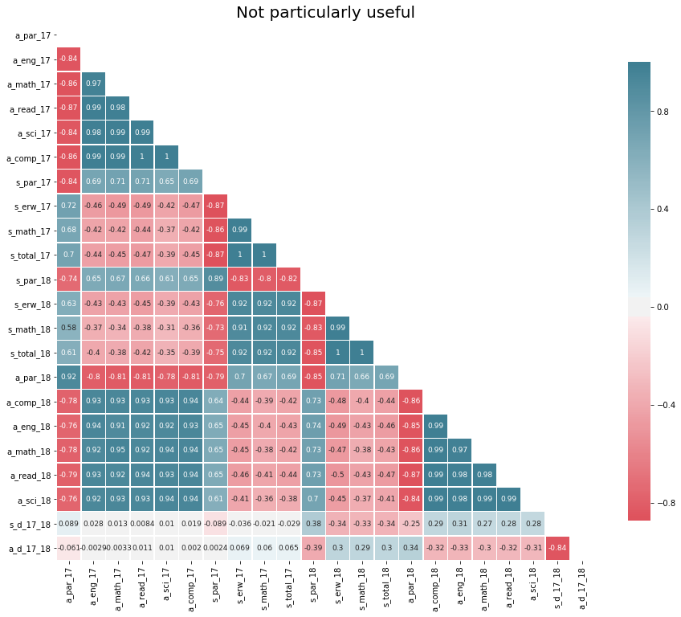

```python
# I can either subsection or use prior dataframes
# Compute the correlation matrix
corr = final.corr()

# Generate a mask for the upper triangle
mask = np.zeros_like(corr, dtype=np.bool)
mask[np.triu_indices_from(mask)] = True

# Set up the matplotlib figure
f, ax = plt.subplots(figsize=(15, 15))
ax.set_title("Not particularly useful", fontdict={'fontsize':20})
ax

# Generate a custom diverging colormap
cmap = sns.diverging_palette(10, 220, as_cmap=True)

# Draw the heatmap with the mask and correct aspect ratio
sns.heatmap(corr, mask=mask, cmap=cmap, center=0,
            square=True, linewidths=.5, cbar_kws={"shrink": .7},annot=True, annot_kws={"size": 9})

# This is senseless
```

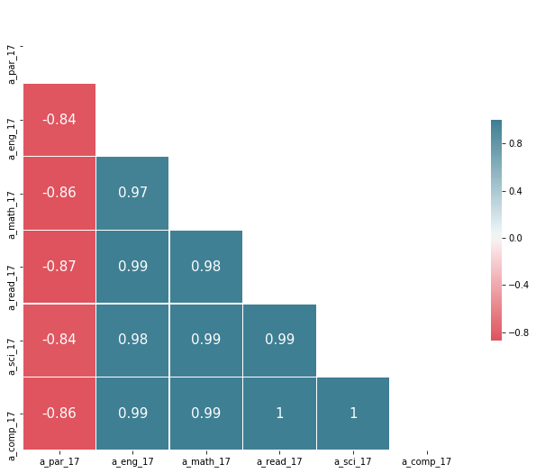

```python
# I can either subsection or use prior dataframes
# Compute the correlation matrix
corr = final.corr().iloc[:6,:6]

# Generate a mask for the upper triangle
mask = np.zeros_like(corr, dtype=np.bool)
mask[np.triu_indices_from(mask)] = True

# Set up the matplotlib figure
f, ax = plt.subplots(figsize=(11, 9))

# Generate a custom diverging colormap
cmap = sns.diverging_palette(10, 220, as_cmap=True)

# Draw the heatmap with the mask and correct aspect ratio
sns.heatmap(corr, mask=mask, cmap=cmap, center=0,
            square=True, linewidths=.5, cbar_kws={"shrink": .5},annot=True, annot_kws={"size": 15})

# This is all for the heck of it. If we draw our focus back to the goal, we should focus more on SAT participation.
# Intuitively, we have some working hypotheses such as inverse relationships between ACT and SAT participation in states
# with mandatory testing in either of the two tests. But is there a relationship between ACT and SAT participation when
# we exclude states with mandatory testing?
```

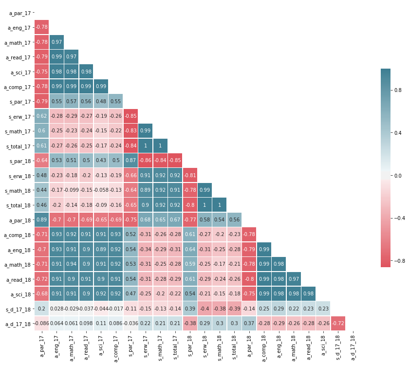

```python
# I can either subsection or use prior dataframes
# Compute the correlation matrix
corr = final[(final['s_par_17'] < 1) & (final['a_par_17'] <1)].corr()

# Generate a mask for the upper triangle
mask = np.zeros_like(corr, dtype=np.bool)
mask[np.triu_indices_from(mask)] = True

# Set up the matplotlib figure
f, ax = plt.subplots(figsize=(15, 15))

# Generate a custom diverging colormap
cmap = sns.diverging_palette(10, 220, as_cmap=True)

# Draw the heatmap with the mask and correct aspect ratio
sns.heatmap(corr, mask=mask, cmap=cmap, center=0,
            square=True, linewidths=.5, cbar_kws={"shrink": .5},annot=True, annot_kws={"size": 10})

# This is all for the heck of it. If we draw our focus back to the goal, we should focus more on SAT participation.
# Intuitively, we have some working hypotheses such as inverse relationships between ACT and SAT participation in states
# with mandatory testing in either of the two tests. But is there a relationship between ACT and SAT participation when
# we exclude states with mandatory testing?
```

#### Define a custom function to subplot histograms

[Helpful Link for Plotting Multiple Figures](https://matplotlib.org/users/pyplot_tutorial.html#working-with-multiple-figures-and-axes)

Here's some starter code:

```python
def subplot_histograms(dataframe, list_of_columns, list_of_titles, list_of_xlabels):
    nrows = int(np.ceil(len(list_of_columns)/2)) # Makes sure you have enough rows
    fig, ax = plt.subplots(nrows=nrows, ncols=2,figsize=(20,20)) # You'll want to specify your figsize
    ax = ax.ravel() # Ravel turns a matrix into a vector, which is easier to iterate
    for i, column in enumerate(list_of_columns): # Gives us an index value to get into all our lists
        ax[i].hist(dataframe[column],bins=10) # feel free to add more settings
        ax[i].set_title(list_of_titles[i],fontdict={'size':20}) # Set titles, labels, etc here for each subplot
        ax[i].set_xlabel(list_of_xlabels[i],fontdict={'size':15})
        ax[i].set_ylabel('Count',fontdict={'size':15})
```

#### Plot and interpret histograms

For each of the following:

- Participation rates for SAT & ACT
- Math scores for SAT & ACT
- Reading/verbal scores for SAT & ACT

```python
coln = list(final.columns)
coln
```

```
['state',
 'a_par_17',
 'a_eng_17',
 'a_math_17',
 'a_read_17',
 'a_sci_17',
 'a_comp_17',
 's_par_17',
 's_erw_17',
 's_math_17',
 's_total_17',
 's_par_18',
 's_erw_18',
 's_math_18',
 's_total_18',
 'a_par_18',
 'a_comp_18',
 'a_eng_18',
 'a_math_18',
 'a_read_18',
 'a_sci_18',
 's_d_17_18',
 'a_d_17_18']
```

```python
coln = coln[1:-2]
```

```python
coln.sort()
```

```python
coln = coln[2:-2]
```

```python
coln
```

```
['a_eng_17',
 'a_eng_18',
 'a_math_17',
 'a_math_18',
 'a_par_17',
 'a_par_18',
 'a_read_17',
 'a_read_18',
 'a_sci_17',
 'a_sci_18',
 's_erw_17',
 's_erw_18',
 's_math_17',
 's_math_18',
 's_par_17',
 's_par_18']
```

```python
coln.pop(8)
```

```
'a_sci_17'
```

```python
coln.pop(8)
```

```
'a_sci_18'
```

```python
coln
```

```
['a_eng_17',
 'a_eng_18',
 'a_math_17',
 'a_math_18',
 'a_par_17',
 'a_par_18',
 'a_read_17',
 'a_read_18',
 's_erw_17',
 's_erw_18',
 's_math_17',
 's_math_18',
 's_par_17',
 's_par_18']
```

```python
par = []
par.extend(coln[4:6])
par.extend(coln[-2:])
par
```

```
['a_par_17', 'a_par_18', 's_par_17', 's_par_18']
```

```python
math = []
math.extend(coln[2:4])
math.extend(coln[-4:-2])
math
```

```
['a_math_17', 'a_math_18', 's_math_17', 's_math_18']
```

```python
erw = coln.copy()
for elt in math:
    erw.remove(elt)
for elt in par:
    erw.remove(elt)
erw
```

```
['a_eng_17', 'a_eng_18', 'a_read_17', 'a_read_18', 's_erw_17', 's_erw_18']
```

```python
par_titles = ['ACT Participation Ratio in 2017', 'ACT Participation Ratio in 2018', 'SAT Participation Ratio in 2017',\
             'SAT Participation Ratio in 2018']
par_xlabels = ['Participation Ratio'] * len(par_titles)
math_titles = ['ACT Math Score in 2017', 'ACT Math Score in 2018', 'SAT Math Score in 2017',\
             'SAT Math Score in 2018']
math_xlabels = ['Scores'] * len(math_titles)
erw_titles = ['ACT English Score in 2017', 'ACT English Score in 2018', 'ACT Reading Score in 2017', \
              'ACT Reading Score in 2018', 'SAT ERW Score in 2017',\
             'SAT ERW Score in 2018']
erw_xlabels = ['Scores'] * len(erw_titles)
```

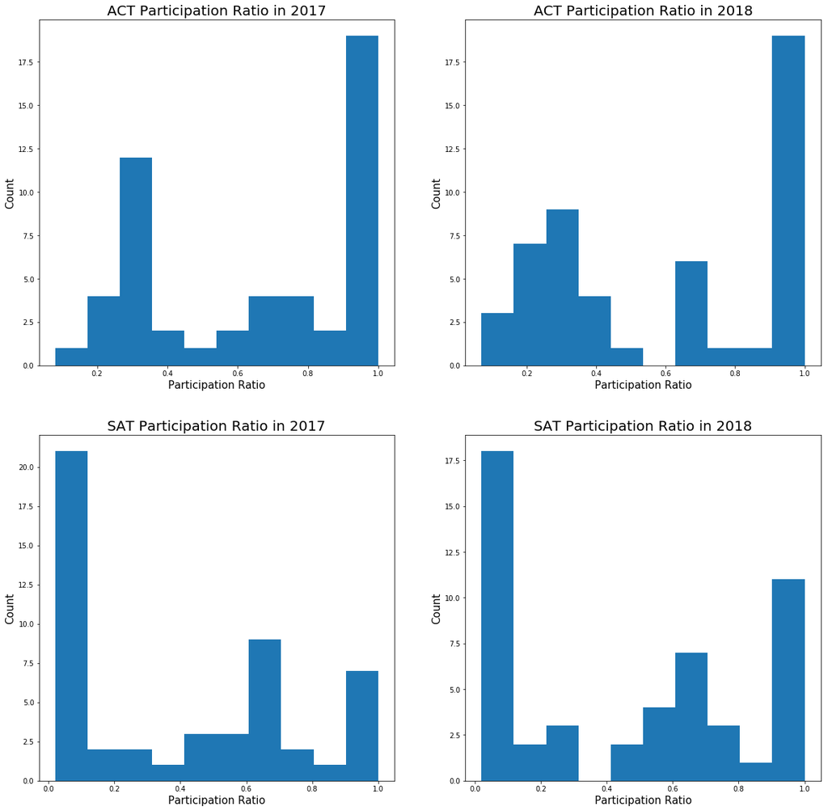

```python
subplot_histograms(final, par, par_titles, par_xlabels)
```

[figure not shown]

```python
subplot_histograms(final, math, math_titles, math_xlabels)
```

[figure not shown]

```python
subplot_histograms(final, erw, erw_titles, erw_xlabels)
```

#### Plot and interpret scatter plots

For each of the following:

- SAT vs. ACT math scores for 2017
- SAT vs. ACT verbal/reading scores for 2017
- SAT vs. ACT total/composite scores for 2017
- Total scores for SAT 2017 vs. 2018
- Composite scores for ACT 2017 vs. 2018

Plot the two variables against each other using matplotlib or Seaborn

Your plots should show:

- Two clearly labeled axes
- A proper title
- Using colors and symbols that are clear and unmistakable

**Feel free to write a custom function, and subplot if you'd like.** Functions save both time and space.

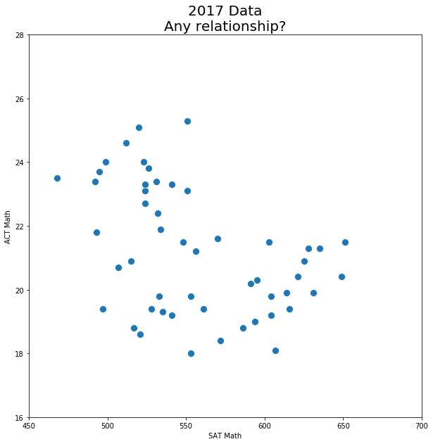

```python
fig, ax = plt.subplots(figsize=(10,10))
ax = sns.scatterplot(x='s_math_17',y='a_math_17',data=final,s=100)
ax.set_ylim(16, 28)
ax.set_xlim(450, 700)

ax.set_xlabel('SAT Math')
ax.set_ylabel('ACT Math')
ax.set_title('2017 Data\nAny relationship?',fontdict={'size':20})
```

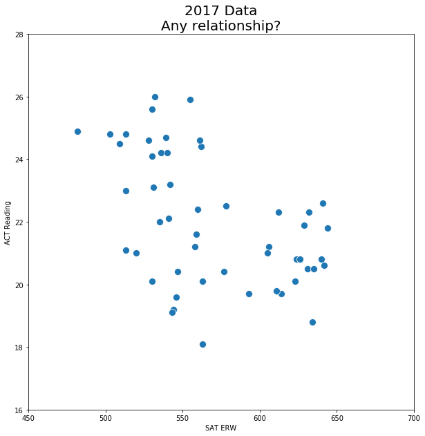

```python
fig, ax = plt.subplots(figsize=(10,10))
ax = sns.scatterplot(x='s_erw_17',y='a_read_17',data=final,s=100)
ax.set_ylim(16, 28)
ax.set_xlim(450, 700)

ax.set_xlabel('SAT ERW')
ax.set_ylabel('ACT Reading')
ax.set_title('2017 Data\nAny relationship?',fontdict={'size':20})
```

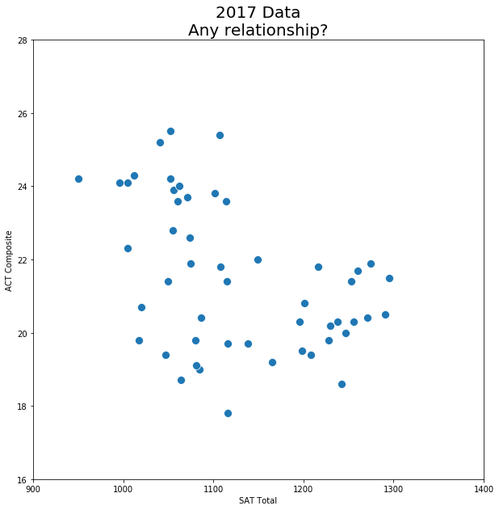

```python
fig, ax = plt.subplots(figsize=(10,10))
ax = sns.scatterplot(x='s_total_17',y='a_comp_17',data=final,s=100)
ax.set_ylim(16, 28)
ax.set_xlim(900, 1400)

ax.set_xlabel('SAT Total')
ax.set_ylabel('ACT Composite')
ax.set_title('2017 Data\nAny relationship?',fontdict={'size':20})
```

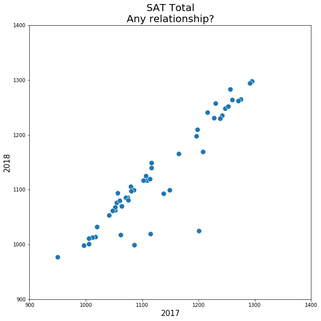

```python
fig, ax = plt.subplots(figsize=(10,10))
ax = sns.scatterplot(x='s_total_17',y='s_total_18',data=final,s=100)
ax.set_ylim(900, 1400)
ax.set_xlim(900, 1400)

ax.set_xlabel('2017',fontdict={'size':15})
ax.set_ylabel('2018',fontdict={'size':15})
ax.set_title('SAT Total\nAny relationship?',fontdict={'size':20})
```

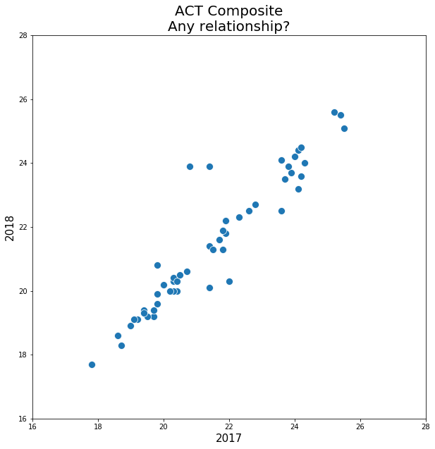

```python
fig, ax = plt.subplots(figsize=(10,10))
ax = sns.scatterplot(x='a_comp_17',y='a_comp_18',data=final,s=100)
ax.set_ylim(16, 28)
ax.set_xlim(16, 28)

ax.set_xlabel('2017',fontdict={'size':15})
ax.set_ylabel('2018',fontdict={'size':15})
ax.set_title('ACT Composite\nAny relationship?',fontdict={'size':20})
```

#### Plot and interpret boxplots

For each numeric variable in the dataframe create a boxplot using Seaborn. Boxplots demonstrate central tendency and spread in variables. In a certain sense, these are somewhat redundant with histograms, but you may be better able to identify clear outliers or differences in IQR, etc.

Multiple values can be plotted to a single boxplot as long as they are of the same relative scale (meaning they have similar min/max values).

Each boxplot should:

- Only include variables of a similar scale
- Have clear labels for each variable
- Have appropriate titles and labels

```python
final.dtypes
```

```
state          object
a_par_17      float64
a_eng_17      float64
a_math_17     float64
a_read_17     float64
a_sci_17      float64
a_comp_17     float64
s_par_17      float64
s_erw_17        int64
s_math_17       int64
s_total_17      int64
s_par_18      float64
s_erw_18        int64
s_math_18       int64
s_total_18      int64
a_par_18      float64
a_comp_18     float64
a_eng_18      float64
a_math_18     float64
a_read_18     float64
a_sci_18      float64
s_d_17_18     float64
a_d_17_18     float64
dtype: object
```

```
[Text(0, 0, 'Math'), Text(0, 0, 'ERW')]
```

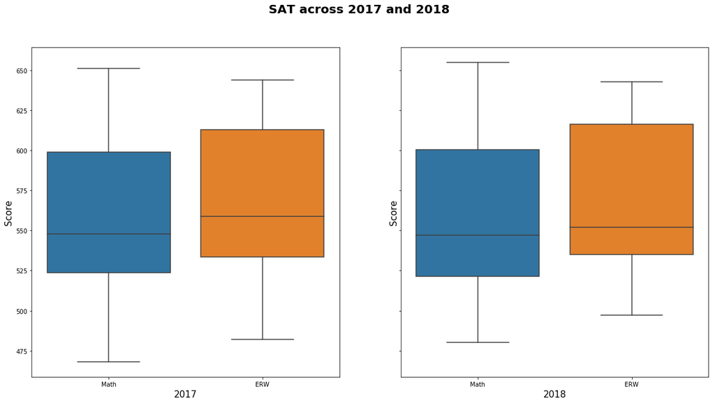

```python
fig, axes = plt.subplots(1,2,figsize=(20,10),sharey=True)
sns.boxplot(data=final[['s_math_17','s_erw_17']],ax=axes[0])
sns.boxplot(data=final[['s_math_18','s_erw_18']],ax=axes[1])
fig.suptitle('SAT across 2017 and 2018',size=20,fontweight='bold')
axes[0].set_xlabel('2017',fontdict={'size':15})
axes[1].set_xlabel('2018',fontdict={'size':15})
axes[0].set_ylabel('Score',fontdict={'size':15})
axes[1].set_ylabel('Score',fontdict={'size':15})
axes[0].set_xticklabels(['Math','ERW'],fontdict={'size':10})
axes[1].set_xticklabels(['Math','ERW'],fontdict={'size':10})
```

```
[Text(0, 0, '2017'), Text(0, 0, '2018')]
```

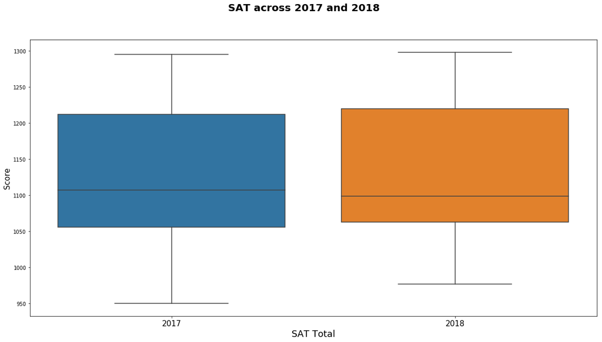

```python
fig, ax = plt.subplots(figsize=(20,10))
sns.boxplot(data=final[['s_total_17','s_total_18']],ax=ax)
fig.suptitle('SAT across 2017 and 2018',size=20,fontweight='bold')
ax.set_ylabel('Score',fontdict={'size':15})
ax.set_xlabel('SAT Total',fontdict={'size':18})
ax.set_xticklabels(['2017','2018'],fontdict={'size':15})
```

[output not shown]

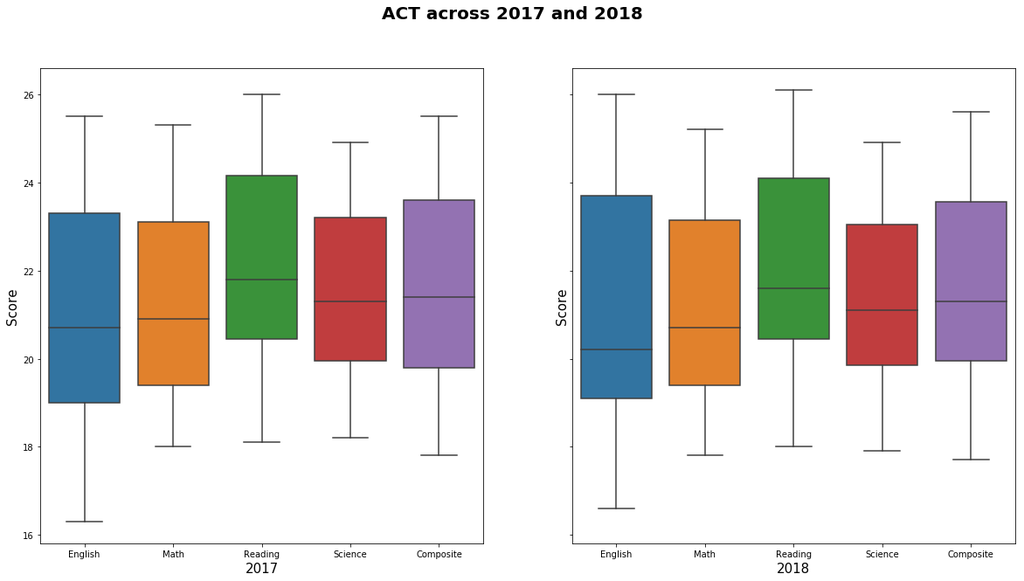

```python
fig, axes = plt.subplots(1,2,figsize=(20,10),sharey=True)
sns.boxplot(data=final[['a_eng_17','a_math_17','a_read_17','a_sci_17','a_comp_17']],ax=axes[0])
sns.boxplot(data=final[['a_eng_18','a_math_18','a_read_18','a_sci_18','a_comp_18']],ax=axes[1])
fig.suptitle('ACT across 2017 and 2018',size=20,fontweight='bold')
axes[0].set_xlabel('2017',fontdict={'size':15})
axes[1].set_xlabel('2018',fontdict={'size':15})
axes[0].set_ylabel('Score',fontdict={'size':15})
axes[1].set_ylabel('Score',fontdict={'size':15})
axes[0].set_xticklabels(['English','Math','Reading','Science','Composite'],fontdict={'size':10})
axes[1].set_xticklabels(['English','Math','Reading','Science','Composite'],fontdict={'size':10})
```

```
[Text(0, 0, 'SAT'), Text(0, 0, 'ACT')]
```

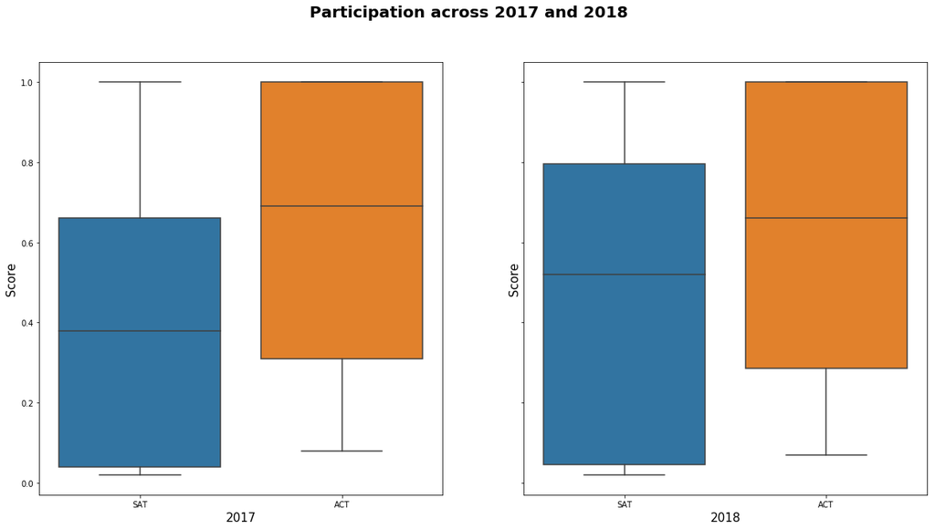

```python
fig, axes = plt.subplots(1,2,figsize=(20,10),sharey=True)
sns.boxplot(data=final[['s_par_17','a_par_17']],ax=axes[0])
sns.boxplot(data=final[['s_par_18','a_par_18']],ax=axes[1])
fig.suptitle('Participation across 2017 and 2018',size=20,fontweight='bold')
axes[0].set_xlabel('2017',fontdict={'size':15})
axes[1].set_xlabel('2018',fontdict={'size':15})
axes[0].set_ylabel('Score',fontdict={'size':15})
axes[1].set_ylabel('Score',fontdict={'size':15})
axes[0].set_xticklabels(['SAT','ACT'],fontdict={'size':10})
axes[1].set_xticklabels(['SAT','ACT'],fontdict={'size':10})
```

```
[Text(0, 0, 'SAT'), Text(0, 0, 'ACT')]
```

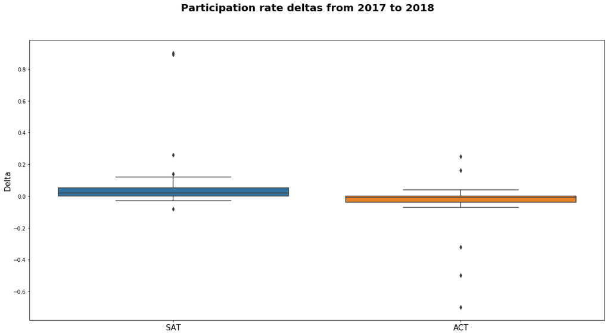

```python
fig, ax = plt.subplots(figsize=(20,10))
sns.boxplot(data=final[['s_d_17_18','a_d_17_18']],ax=ax)
fig.suptitle('Participation rate deltas from 2017 to 2018',size=20,fontweight='bold')
ax.set_ylabel('Delta',fontdict={'size':15})
ax.set_xticklabels(['SAT','ACT'],fontdict={'size':15})
```

#### Feel free to do additional plots below

*(do research and choose your own chart types & variables)*

Are there any additional trends or relationships you haven't explored? Was there something interesting you saw that you'd like to dive further into? It's likely that there are a few more plots you might want to generate to support your narrative and recommendations that you are building toward. **As always, make sure you're interpreting your plots as you go**.

```python
final.sort_values(by='s_d_17_18',ascending=False)[['state','a_comp_17','a_comp_18','s_total_17','s_total_18',\
                                                   'a_par_17','a_par_18','s_par_17','s_par_18','s_d_17_18','a_d_17_18']]
```

|  | state | a_comp_17 | a_comp_18 | s_total_17 | s_total_18 | a_par_17 | a_par_18 | s_par_17 | s_par_18 | s_d_17_18 | a_d_17_18 |
| --- | --- | --- | --- | --- | --- | --- | --- | --- | --- | --- | --- |
| 13 | Illinois | 21.4 | 23.9 | 1115 | 1019 | 0.93 | 0.43 | 0.09 | 0.99 | 0.90 | -0.50 |
| 5 | Colorado | 20.8 | 23.9 | 1201 | 1025 | 1.00 | 0.30 | 0.11 | 1.00 | 0.89 | -0.70 |
| 39 | Rhode Island | 24.0 | 24.2 | 1062 | 1018 | 0.21 | 0.15 | 0.71 | 0.97 | 0.26 | -0.06 |
| 48 | West Virginia | 20.4 | 20.3 | 1086 | 999 | 0.69 | 0.65 | 0.14 | 0.28 | 0.14 | -0.04 |
| 9 | Florida | 19.8 | 19.9 | 1017 | 1014 | 0.73 | 0.66 | 0.83 | 0.97 | 0.14 | -0.07 |
| 30 | New Jersey | 23.9 | 23.7 | 1056 | 1094 | 0.34 | 0.31 | 0.70 | 0.82 | 0.12 | -0.03 |
| 32 | New York | 24.2 | 24.5 | 1052 | 1068 | 0.31 | 0.27 | 0.67 | 0.79 | 0.12 | -0.04 |
| 10 | Georgia | 21.4 | 21.4 | 1050 | 1064 | 0.55 | 0.53 | 0.61 | 0.70 | 0.09 | -0.02 |
| 20 | Maryland | 23.6 | 22.5 | 1060 | 1080 | 0.28 | 0.31 | 0.69 | 0.76 | 0.07 | 0.03 |
| 12 | Idaho | 22.3 | 22.3 | 1005 | 1001 | 0.38 | 0.36 | 0.93 | 1.00 | 0.07 | -0.02 |
| 4 | California | 22.8 | 22.7 | 1055 | 1076 | 0.31 | 0.27 | 0.53 | 0.60 | 0.07 | -0.04 |
| 35 | Ohio | 22.0 | 20.3 | 1149 | 1099 | 0.75 | 1.00 | 0.12 | 0.18 | 0.06 | 0.25 |
| 40 | South Carolina | 18.7 | 18.3 | 1064 | 1070 | 1.00 | 1.00 | 0.50 | 0.55 | 0.05 | 0.00 |
| 31 | New Mexico | 19.7 | 19.4 | 1138 | 1093 | 0.66 | 0.67 | 0.11 | 0.16 | 0.05 | 0.01 |
| 1 | Alaska | 19.8 | 20.8 | 1080 | 1106 | 0.65 | 0.33 | 0.38 | 0.43 | 0.05 | -0.32 |
| 37 | Oregon | 21.8 | 21.3 | 1108 | 1117 | 0.40 | 0.42 | 0.43 | 0.48 | 0.05 | 0.02 |
| 38 | Pennsylvania | 23.7 | 23.5 | 1071 | 1086 | 0.23 | 0.20 | 0.65 | 0.70 | 0.05 | -0.03 |
| 47 | Washington | 21.9 | 22.2 | 1075 | 1081 | 0.29 | 0.24 | 0.64 | 0.69 | 0.05 | -0.05 |
| 14 | Indiana | 22.6 | 22.5 | 1074 | 1086 | 0.35 | 0.32 | 0.63 | 0.67 | 0.04 | -0.03 |
| 45 | Vermont | 23.6 | 24.1 | 1114 | 1120 | 0.29 | 0.24 | 0.60 | 0.64 | 0.04 | -0.05 |
| 19 | Maine | 24.3 | 24.0 | 1012 | 1013 | 0.08 | 0.07 | 0.95 | 0.99 | 0.04 | -0.01 |
| 21 | Massachusetts | 25.4 | 25.5 | 1107 | 1125 | 0.29 | 0.25 | 0.76 | 0.80 | 0.04 | -0.04 |
| 43 | Texas | 20.7 | 20.6 | 1020 | 1032 | 0.45 | 0.41 | 0.62 | 0.66 | 0.04 | -0.04 |
| 33 | North Carolina | 19.1 | 19.1 | 1081 | 1098 | 1.00 | 1.00 | 0.49 | 0.52 | 0.03 | 0.00 |
| 46 | Virginia | 23.8 | 23.9 | 1102 | 1117 | 0.29 | 0.24 | 0.65 | 0.68 | 0.03 | -0.05 |
| 3 | Arkansas | 19.4 | 19.4 | 1208 | 1169 | 1.00 | 1.00 | 0.03 | 0.05 | 0.02 | 0.00 |
| 11 | Hawaii | 19.0 | 18.9 | 1085 | 1099 | 0.90 | 0.89 | 0.55 | 0.56 | 0.01 | -0.01 |
| 23 | Minnesota | 21.5 | 21.3 | 1295 | 1298 | 1.00 | 0.99 | 0.03 | 0.04 | 0.01 | -0.01 |
| 44 | Utah | 20.3 | 20.4 | 1238 | 1230 | 1.00 | 1.00 | 0.03 | 0.04 | 0.01 | 0.00 |
| 25 | Missouri | 20.4 | 20.0 | 1271 | 1262 | 1.00 | 1.00 | 0.03 | 0.04 | 0.01 | 0.00 |
| 24 | Mississippi | 18.6 | 18.6 | 1242 | 1236 | 1.00 | 1.00 | 0.02 | 0.03 | 0.01 | 0.00 |
| 15 | Iowa | 21.9 | 21.8 | 1275 | 1265 | 0.67 | 0.68 | 0.02 | 0.03 | 0.01 | 0.01 |
| 42 | Tennessee | 19.8 | 19.6 | 1228 | 1231 | 1.00 | 1.00 | 0.05 | 0.06 | 0.01 | 0.00 |
| 36 | Oklahoma | 19.4 | 19.3 | 1047 | 1062 | 1.00 | 1.00 | 0.07 | 0.08 | 0.01 | 0.00 |
| 0 | Alabama | 19.2 | 19.1 | 1165 | 1166 | 1.00 | 1.00 | 0.05 | 0.06 | 0.01 | 0.00 |
| 34 | North Dakota | 20.3 | 20.3 | 1256 | 1283 | 0.98 | 0.98 | 0.02 | 0.02 | 0.00 | 0.00 |
| 29 | New Hampshire | 25.5 | 25.1 | 1052 | 1063 | 0.18 | 0.16 | 0.96 | 0.96 | 0.00 | -0.02 |
| 27 | Nebraska | 21.4 | 20.1 | 1253 | 1252 | 0.84 | 1.00 | 0.03 | 0.03 | 0.00 | 0.16 |
| 26 | Montana | 20.3 | 20.0 | 1196 | 1198 | 1.00 | 1.00 | 0.10 | 0.10 | 0.00 | 0.00 |
| 22 | Michigan | 24.1 | 24.4 | 1005 | 1011 | 0.29 | 0.22 | 1.00 | 1.00 | 0.00 | -0.07 |
| 41 | South Dakota | 21.8 | 21.9 | 1216 | 1241 | 0.80 | 0.77 | 0.03 | 0.03 | 0.00 | -0.03 |
| 18 | Louisiana | 19.5 | 19.2 | 1198 | 1210 | 1.00 | 1.00 | 0.04 | 0.04 | 0.00 | 0.00 |
| 17 | Kentucky | 20.0 | 20.2 | 1247 | 1248 | 1.00 | 1.00 | 0.04 | 0.04 | 0.00 | 0.00 |
| 16 | Kansas | 21.7 | 21.6 | 1260 | 1264 | 0.73 | 0.71 | 0.04 | 0.04 | 0.00 | -0.02 |
| 7 | Delaware | 24.1 | 23.2 | 996 | 998 | 0.18 | 0.17 | 1.00 | 1.00 | 0.00 | -0.01 |
| 6 | Connecticut | 25.2 | 25.6 | 1041 | 1053 | 0.31 | 0.26 | 1.00 | 1.00 | 0.00 | -0.05 |
| 49 | Wisconsin | 20.5 | 20.5 | 1291 | 1294 | 1.00 | 1.00 | 0.03 | 0.03 | 0.00 | 0.00 |
| 50 | Wyoming | 20.2 | 20.0 | 1230 | 1258 | 1.00 | 1.00 | 0.03 | 0.03 | 0.00 | 0.00 |
| 2 | Arizona | 19.7 | 19.2 | 1116 | 1149 | 0.62 | 0.66 | 0.30 | 0.29 | -0.01 | 0.04 |
| 28 | Nevada | 17.8 | 17.7 | 1116 | 1140 | 1.00 | 1.00 | 0.26 | 0.23 | -0.03 | 0.00 |
| 8 | District of Columbia | 24.2 | 23.6 | 950 | 977 | 0.32 | 0.32 | 1.00 | 0.92 | -0.08 | 0.00 |

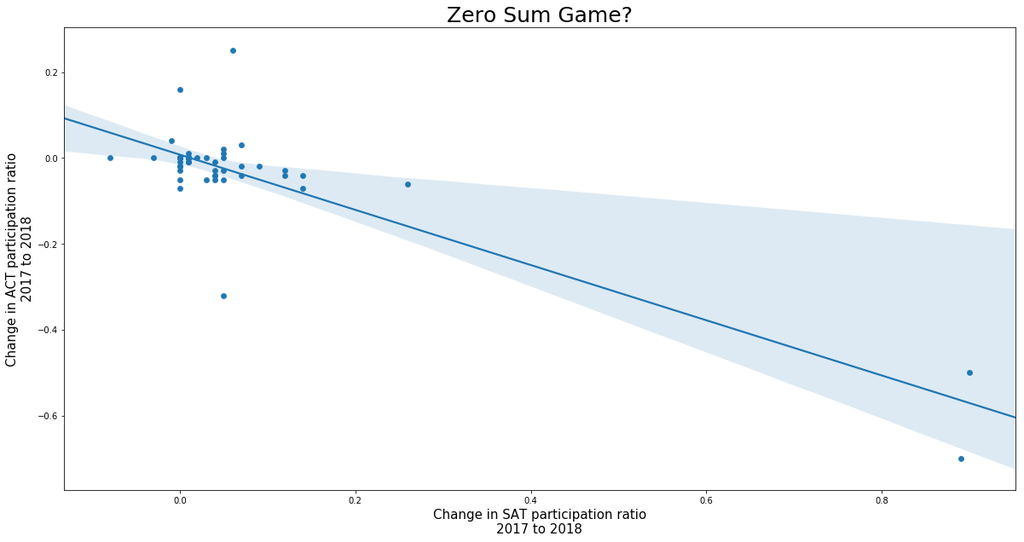

```python
fig, ax = plt.subplots(figsize=(20,10))
sns.scatterplot(x='s_d_17_18',y='a_d_17_18',data=final,ax=ax)
sns.regplot(x='s_d_17_18',y='a_d_17_18',data=final,ax=ax)
ax.set_title('Zero Sum Game?',fontdict={'size':25})
ax.set_xlabel('Change in SAT participation ratio\n2017 to 2018',fontdict={'size':15})
ax.set_ylabel('Change in ACT participation ratio\n2017 to 2018',fontdict={'size':15})
```

## Descriptive and Inferential Statistics

#### Summarizing Distributions

Above, we used pandas `describe` to provide quick summary statistics of our numeric columns. We also demonstrated many visual relationships.

As data scientists, having a complete understanding of data is imperative prior to modeling.

While we will continue to build our analytic tools, we know that measures of *central tendency*, *spread*, and *shape/skewness* provide a quick summary of distributions.

For each variable in your data, summarize the underlying distributions (in words & statistics)

- Be thorough in your verbal description of these distributions.
- Be sure to back up these summaries with statistics.

Only superficial details that we can glean from the graphs above and the output of the pandas `describe()` method.

```python
final.describe().T
```

|  | count | mean | std | min | 25% | 50% | 75% | max |
| --- | --- | --- | --- | --- | --- | --- | --- | --- |
| a_par_17 | 51.0 | 0.652549 | 0.321408 | 0.08 | 0.310 | 0.69 | 1.000 | 1.00 |
| a_eng_17 | 51.0 | 20.931373 | 2.353677 | 16.30 | 19.000 | 20.70 | 23.300 | 25.50 |
| a_math_17 | 51.0 | 21.182353 | 1.981989 | 18.00 | 19.400 | 20.90 | 23.100 | 25.30 |
| a_read_17 | 51.0 | 22.013725 | 2.067271 | 18.10 | 20.450 | 21.80 | 24.150 | 26.00 |
| a_sci_17 | 51.0 | 21.450980 | 1.739353 | 18.20 | 19.950 | 21.30 | 23.200 | 24.90 |
| a_comp_17 | 51.0 | 21.519608 | 2.020695 | 17.80 | 19.800 | 21.40 | 23.600 | 25.50 |
| s_par_17 | 51.0 | 0.398039 | 0.352766 | 0.02 | 0.040 | 0.38 | 0.660 | 1.00 |
| s_erw_17 | 51.0 | 569.117647 | 45.666901 | 482.00 | 533.500 | 559.00 | 613.000 | 644.00 |
| s_math_17 | 51.0 | 556.882353 | 47.121395 | 468.00 | 523.500 | 548.00 | 599.000 | 651.00 |
| s_total_17 | 51.0 | 1126.098039 | 92.494812 | 950.00 | 1055.500 | 1107.00 | 1212.000 | 1295.00 |
| s_par_18 | 51.0 | 0.466275 | 0.380142 | 0.02 | 0.045 | 0.52 | 0.795 | 1.00 |
| s_erw_18 | 51.0 | 567.294118 | 45.317676 | 497.00 | 535.000 | 552.00 | 616.500 | 643.00 |
| s_math_18 | 51.0 | 557.254902 | 48.887562 | 480.00 | 521.500 | 547.00 | 600.500 | 655.00 |
| s_total_18 | 51.0 | 1124.666667 | 93.867069 | 977.00 | 1062.500 | 1099.00 | 1220.000 | 1298.00 |
| a_par_18 | 51.0 | 0.616471 | 0.340810 | 0.07 | 0.285 | 0.66 | 1.000 | 1.00 |
| a_comp_18 | 51.0 | 21.486275 | 2.106278 | 17.70 | 19.950 | 21.30 | 23.550 | 25.60 |
| a_eng_18 | 51.0 | 20.988235 | 2.446356 | 16.60 | 19.100 | 20.20 | 23.700 | 26.00 |
| a_math_18 | 51.0 | 21.125490 | 2.035765 | 17.80 | 19.400 | 20.70 | 23.150 | 25.20 |
| a_read_18 | 51.0 | 22.015686 | 2.167245 | 18.00 | 20.450 | 21.60 | 24.100 | 26.10 |
| a_sci_18 | 51.0 | 21.345098 | 1.870114 | 17.90 | 19.850 | 21.10 | 23.050 | 24.90 |
| s_d_17_18 | 51.0 | 0.068235 | 0.176643 | -0.08 | 0.000 | 0.02 | 0.050 | 0.90 |
| a_d_17_18 | 51.0 | -0.036078 | 0.134478 | -0.70 | -0.040 | -0.01 | 0.000 | 0.25 |

#### We generally assuming that data we sample from a population will be normally distributed. Do we observe this trend?

No. Moreover this seems to be leading towards an incorrect interpretation of CLT.

Does This Assumption Hold for:

```
- Math
- Reading
- Rates
```

Explain your answers for each distribution and how you think this will affect estimates made from these data.

#### Estimate Limits of Data

Suppose we only seek to understand the relationship between SAT and ACT participation rates in 2017.

##### Does it make sense to conduct statistical inference given these data specifically?

Why or why not?

*(think about granularity, aggregation, the relationships between populations size & rates...consider the actually populations these data describe in answering this question)*

Not really. The sampling isn't randomized.

##### Is it appropriate to compare *these* specific SAT and ACT math scores?

Why or why not?

Somewhat. It would be more interesting to check if common core math is a mediator variable.

## Outside Research

Based upon your observations, choose **three** states that demonstrate interesting trends in their SAT and/or ACT participation rates. Spend some time doing outside research on state policies that might influence these rates, and summarize your findings below. **Feel free to go back and create new plots that highlight these states of interest**. If you bring in any outside tables or charts, make sure you are explicit about having borrowed them. If you quote any text, make sure that it renders as being quoted. (Make sure that you cite your sources -- check with you local instructor for citation preferences).

Let's look at Illinois, Colorado, and Rhode Island given their uptake of SAT moving from 2017 to 2018.

Illinois jumped from 9% to 99%. With a bit of google-fu, we find out that it's actually due to politics - state contract was awarded to The College Board after 15 years of ACT dominance.

Colorado posted similar stats, moving from 11% to 100%. Again, this boils down to politics.

Ditto for RI.

Interestingly, West Virginia is next up in line when it comes to the biggest movers apropos of the uptake of SAT from 2017 to 2018. Looking at the data, the state looks promising as the participation rate went from 14% to 28%, demonstrating a 100% increase. All that while ACT declined a mere 4 percentage point (69% to 65%). It feels much less of a zero-sum game there with the potential for the company to make inroads. Coupled with the upcoming changes to account for adversity, this is a great opportunity for the company to ingratiate itself with the policymakers to broaden SAT's exposure in WV.

## Conclusions and Recommendations

Based on your exploration of the data, what are you key takeaways and recommendations? Choose one state with a lower participation rate and provide a suggestion for how the College Board might increase participation amongst graduating seniors in this state. Are there additional data you desire that would better inform your investigations?

Lobby the board of education and the policymakers in WV.